# softimpute analysis pipeline - island scale (50 iterations): negative values are converted to zeros

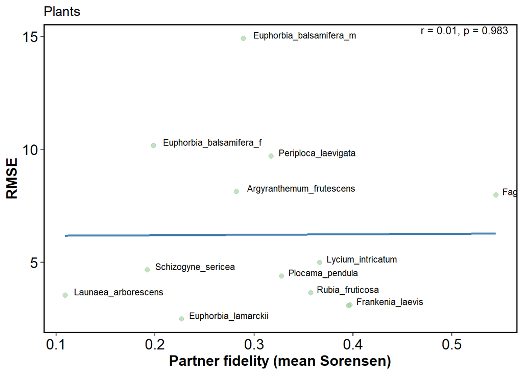

```r
# pdf(
#   file   = "rmse_fidelity_species_island.pdf",
#   width  = 7,
#   height = 5.5,
#   family = "Helvetica"
# )
#
# grid::grid.draw(rmse_fidelity_species_island)
#
# dev.off()


# combine_plots_fidelity <- function(p1, p2,
#                           bottom_label = "Mean Sorensen similarity",
#                           left_label = "RMSE",
#                           plot_margin = c(0.5, 0.5, 1, 0.3),
#                           label_fontsize = 16,
#                           label_fontface = "bold",
#                           widths_subplots = c(1, 1),
#                           final_widths = c(2, 0.3)) {
#
#   # Load required packages
#   require(ggplot2)
#   require(gridExtra)
#   require(grid)
#
#   # Adjust individual plots
#   p1_mod <- p1 +
#     theme(legend.position = "none",
#           axis.title = element_blank(),
#           plot.margin = unit(plot_margin, "cm"))
#
#   p2_mod <- p2 +
#     theme(legend.position = "none",
#           axis.title = element_blank(),
#           plot.margin = unit(plot_margin, "cm"))
#
#   # Arrange the two plots side-by-side
#   combined_plots <- arrangeGrob(p1_mod, p2_mod,
#                                 ncol = 2,
#                                 widths = widths_subplots)
#
#   # Add axis labels using arrangeGrob (the bottom and left text grobs)
#   combined_with_axes <- arrangeGrob(
#     combined_plots,
#     bottom = textGrob(bottom_label,
#                       gp = gpar(fontsize = label_fontsize, fontface = label_fontface),
#                       vjust = -1.5),
#     left   = textGrob(left_label,
#                       rot = 90,
#                       gp = gpar(fontsize = label_fontsize, fontface = label_fontface))
#   )
#
#   # Finally, arrange the whole thing with additional spacing if needed
#   final_plot <- grid.arrange(
#     combined_with_axes,
#     ncol = 2,
#     widths = final_widths
#   )
#
#   return(final_plot)
# }
# per_species_fidelity <- combine_plots_fidelity(per_plant_fidelity, per_poll_fidelity)
#
# final_fidelity <- per_species_fidelity / rmse_fidelity

# inspect species
make_simple_correlation_plot <- function(data, x_var, evaluator, label_var,
                                         x_lab = NULL, y_lab = NULL,
                                         plot_title, point_color,
                                         trend_color = "steelblue",
                                         text_size = 3) {

  # run correlation as before…
  correlation <- cor.test(data[[evaluator]], data[[x_var]],
                          use = "complete.obs", method = "pearson")
  r_value <- round(correlation$estimate, 2)
  p_value <- ifelse(correlation$p.value < 0.001,
                    formatC(correlation$p.value, format="e", digits=2),
                    formatC(correlation$p.value, format="f", digits=3))
  label_text <- paste0("r = ", r_value, ", p = ", p_value)

  ggplot(data, aes_string(x = x_var, y = evaluator)) +
    geom_point(color = point_color, alpha = 0.6, size = 2) +
    geom_smooth(method = "lm", se = FALSE, color = trend_color) +
    # this is the new bit: map your species‐column into label
    geom_text(aes_string(label = label_var),
              hjust = -0.1, vjust =  0,
              size  = text_size,
              check_overlap = TRUE) +
    labs(x = x_lab, y = y_lab, title = plot_title) + tme +
    annotate("text", x = Inf, y = Inf,
             hjust = 1.1, vjust = 1.2,
             label = label_text, size = 3.5)
}

make_simple_correlation_plot(
  data        = plant_analysis,
  x_var       = "partner_fidelity",
  evaluator   = "rmse",
  label_var   = "node_from",
  x_lab       = "Partner fidelity (mean Sorensen)",
  y_lab       = "RMSE",
  plot_title  = "Plants",
  point_color = "darkseagreen3"
)
```

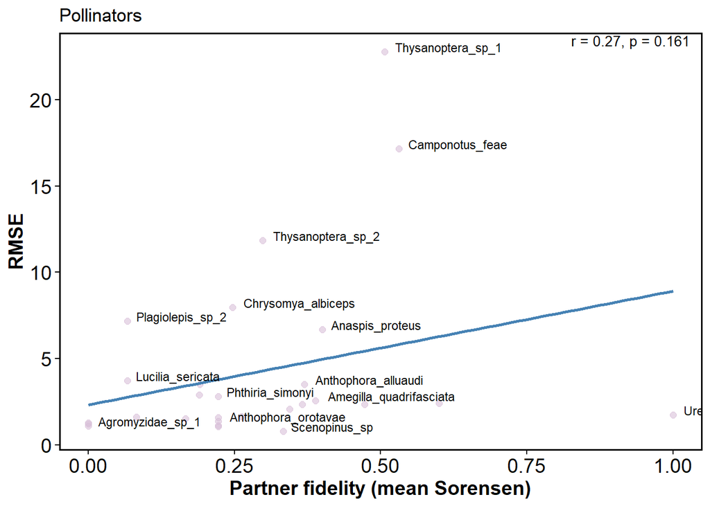

```r
make_simple_correlation_plot(
  data        = poll_analysis,
  x_var       = "partner_fidelity",
  evaluator   = "rmse",
  label_var   = "node_to",
  x_lab       = "Partner fidelity (mean Sorensen)",
  y_lab       = "RMSE",
  plot_title  = "Pollinators",
  point_color = "thistle"
)
```

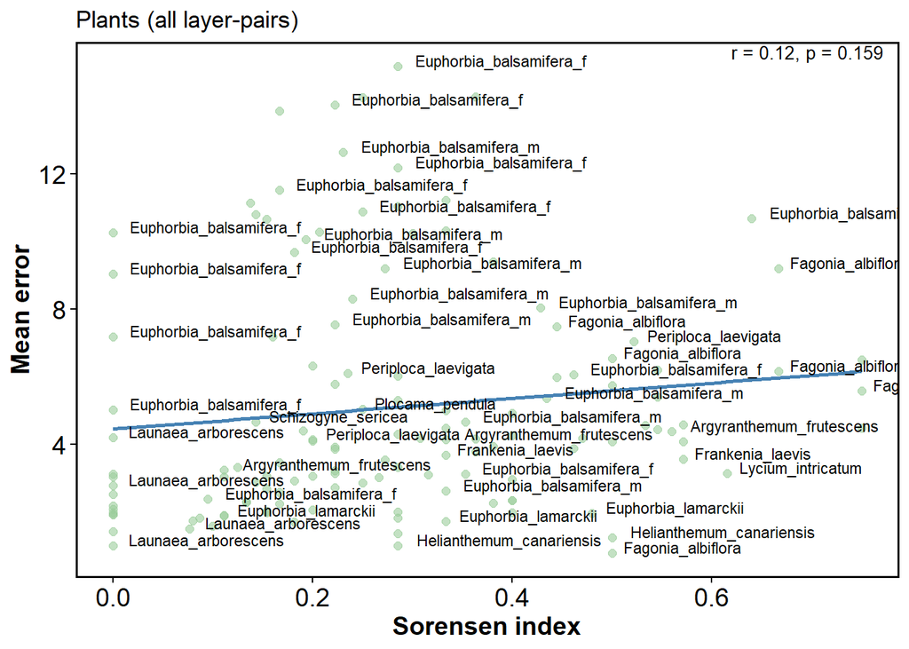

```r
# checking fidelity for each specific combination of layers
# for each unique layer combination

library(dplyr)

compute_sorensen_long <- function(df_part, species_col) {
  df_part %>%
    # rename once so we can refer to layer1/pset1 and layer2/pset2
    rename(layer1 = train_layer, pset1 = partners) %>%
    inner_join(
      df_part %>% rename(layer2 = train_layer, pset2 = partners),
      by            = species_col,
      relationship  = "many-to-many"      # silence the warning intentionally
    ) %>%
    filter(layer1 < layer2) %>%           # only unordered pairs, no self-pairs
    rowwise() %>%
    mutate(
      a   = length(intersect(pset1, pset2)),
      b   = length(setdiff(pset1, pset2)),
      c   = length(setdiff(pset2, pset1)),
      sor = if (2*a + b + c == 0) NA_real_ else 2*a / (2*a + b + c)
    ) %>%
    ungroup()
}

# apply to your pre-filtered partner-sets
plant_sor <- compute_sorensen_long(plant_partners, "node_from")
poll_sor  <- compute_sorensen_long(poll_partners,  "node_to")

# compure error

plant_error_pair <- df_error %>%
  filter(original_links != 0, train_layer != test_layer) %>%
  group_by(node_from, train_layer, test_layer) %>%
  summarise(
    error = mean(abs(predicted_values - original_links), na.rm = TRUE),
    .groups = "drop"
  )

poll_error_pair <- df_error %>%
  filter(original_links != 0, train_layer != test_layer) %>%
  group_by(node_to, train_layer, test_layer) %>%
  summarise(
    error = mean(abs(predicted_values - original_links), na.rm = TRUE),
    .groups = "drop"
  )

# combine
plant_combo <- plant_sor %>%
  left_join(
    plant_error_pair,
    by = c(
      "node_from" = "node_from",
      "layer1"    = "train_layer",
      "layer2"    = "test_layer"
    )
  )

poll_combo <- poll_sor %>%
  left_join(
    poll_error_pair,
    by = c(
      "node_to" = "node_to",
      "layer1"  = "train_layer",
      "layer2"  = "test_layer"
    )
  )

# plot

make_simple_correlation_plot(
  data        = plant_combo,
  x_var       = "sor",
  evaluator   = "error",
  label_var   = "node_from",        # ← here you provide it
  x_lab       = "Sorensen index",
  y_lab       = "Mean error",
  plot_title  = "Plants (all layer-pairs)",
  point_color = "darkseagreen3",
  trend_color = "steelblue"
)
```

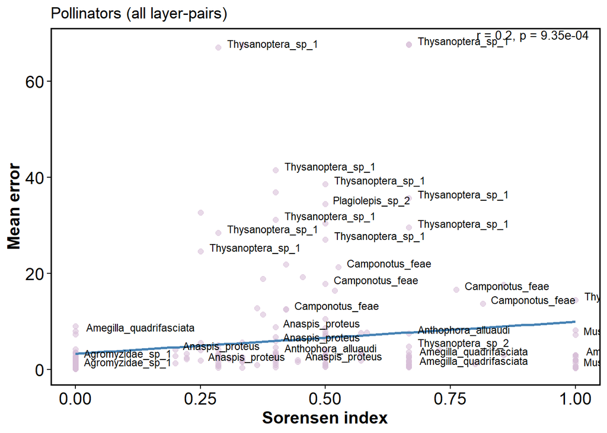

```r
make_simple_correlation_plot(
  data        = poll_combo,
  x_var       = "sor",
  evaluator   = "error",
  label_var   = "node_to",          # ← here
  x_lab       = "Sorensen index",
  y_lab       = "Mean error",
  plot_title  = "Pollinators (all layer-pairs)",
  point_color = "thistle",
  trend_color = "steelblue"
)
```

```r
## ---- degree impact and correlation with evaluators ----
### ---- calculate overall degree ----
# Step 1: Filter the data
df_filtered <- df %>%
  filter(itr == 1, original_links != 0)

# Step 2a: Calculate degree for each plant species (node_from)
plant_degree <- df_filtered %>%
  group_by(train_layer, test_layer, node_from) %>%
  summarise(plant_degree = n(), .groups = "drop")

# Average plant degree by train_layer and test_layer
avg_plant_degree <- plant_degree %>%
  group_by(node_from) %>%
  summarise(avg_plant_degree = mean(plant_degree), .groups = "drop")

overall_plant_degree <- df_filtered %>%
  group_by(node_from) %>%
  summarise(overall_plant_degree = length(unique(node_to)), .groups = "drop")

overall_poll_degree <- df_filtered %>%
  group_by(node_to) %>%
  summarise(overall_poll_degree = length(unique(node_from)), .groups = "drop")

# Step 2b: Calculate degree for each pollinator species (node_to)
pollinator_degree <- df_filtered %>%
  group_by(train_layer, test_layer, node_to) %>%
  summarise(poll_degree = n(), .groups = "drop")

# Average pollinator degree by train_layer and test_layer
avg_pollinator_degree <- pollinator_degree %>%
  group_by(node_to) %>%
  summarise(avg_pollinator_degree = mean(poll_degree), .groups = "drop")

### ---- plot degree vs. number of never observed interactions ----
# here we examine if the algorithm assigns more links to species with higher degree.
# here by "island" we refer to a layer pair

df <- df %>%
  mutate(island_id = paste(train_layer, test_layer, sep = "_")) %>%
  mutate(predicted_prob_sigm = sigmoid(predicted_values))

# Step 1: For each island and interaction, determine if the interaction was observed.
# Here we use `any(original_links == 1)` so that if the interaction is observed in at least one iteration, we count it.
df_island <- df %>%
  group_by(node_from, node_to, island_id) %>%
  summarise(
    observed = as.integer(any(original_links != 0)),
    # For predicted_prob_sigm, you might take the average across iterations per island.
    island_sigm_predicted = mean(predicted_prob_sigm, na.rm = TRUE),
    .groups = "drop"
  )

table(df_island$observed)
```

```
##
##     0     1
## 21070  3717
```

```r
# Step 2: Now, for each unique interaction, compute:
# - The proportion of islands where it was observed.
# - The average predicted probability (averaged over islands).
df_summary <- df_island %>%
  group_by(node_from, node_to) %>%
  summarise(
    avg_prop = mean(observed, na.rm = TRUE),       # proportion of islands with observation
    avg_sigm_predicted = mean(island_sigm_predicted, na.rm = TRUE),
    n_islands = n(),  # number of islands contributing
    .groups = "drop"
  )

# 3. Remove interactions that were never observed and predicted as zero.
# df_summary <- df_summary %>%
#   filter(!(avg_prop == 0 & avg_sigm_predicted < 0.5))

df_never_observed <- df_summary %>%
  filter(avg_prop == 0, avg_sigm_predicted > best_discrete_threshold) %>%
  group_by(node_from) %>%
  summarise(count_never_observed = n(), .groups = "drop")

df_never_observed_poll <- df_summary %>%
  filter(avg_prop == 0, avg_sigm_predicted > best_discrete_threshold) %>%
  group_by(node_to) %>%
  summarise(count_never_observed = n(), .groups = "drop")

never_plants_degree <- df_never_observed %>% left_join(avg_plant_degree, by="node_from")

# for overall degree

never_plants_degree_overall <- df_never_observed %>% left_join(overall_plant_degree, by="node_from")

never_poll_degree_overall <- df_never_observed_poll %>% left_join(overall_poll_degree, by="node_to")

# if we want to omit the Euphorbias
# never_plants_degree_overall <- never_plants_degree_overall %>%
#   filter(!node_from %in% c("Euphorbia_balsamifera_m", "Euphorbia_balsamifera_f"))

# correlation
df_to_correlate <- never_plants_degree_overall
df_to_correlate$x <- df_to_correlate$overall_plant_degree
df_to_correlate$y <- df_to_correlate$count_never_observed

correlation_plants <- cor.test(df_to_correlate$x, df_to_correlate$y, use = "complete.obs", method = "pearson")
correlation_plants
```

```
##
##  Pearson's product-moment correlation
##
## data:  df_to_correlate$x and df_to_correlate$y
## t = 5.386, df = 29, p-value = 8.679e-06
## alternative hypothesis: true correlation is not equal to 0
## 95 percent confidence interval:
##  0.4707900 0.8488104
## sample estimates:
##       cor
## 0.7071616
```

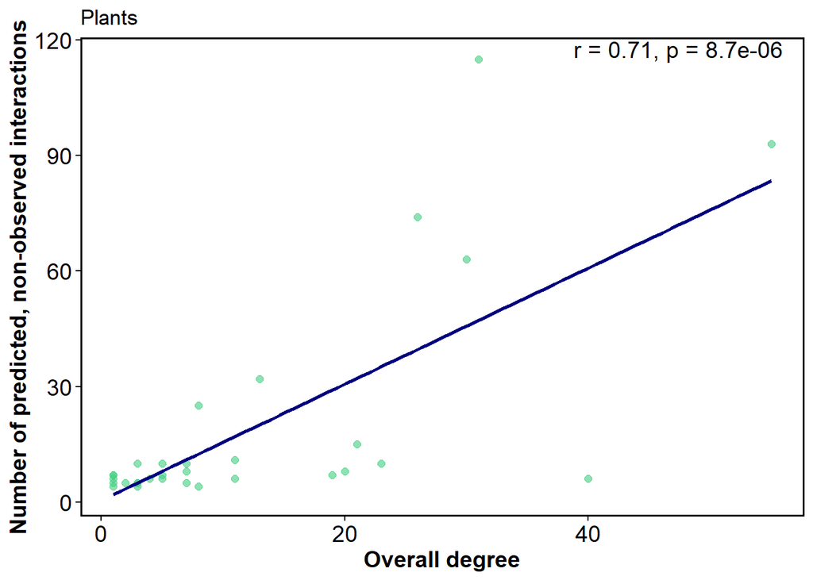

```r
# Extract correlation coefficient and p-value
r_value <- round(correlation_plants$estimate, 2)
p_value <- formatC(correlation_plants$p.value, digits = 2)  # or round as you prefer
label_text_plants <- paste0("r = ", r_value, ", p = ", p_value)

plant_degree <- ggplot(df_to_correlate, aes(x = x, y = y)) +
  geom_point(alpha = 0.6, size = 2, color = "seagreen3") +
  geom_smooth(method = "lm", se = FALSE, color = "navy") +
  labs(
    x = "Overall degree",
    y = "Number of predicted, non-observed interactions",
    title = "Plants"
  ) +
  theme_minimal() + tme +
  annotate("text",
           x = Inf,
           y = Inf,
           hjust = 1.1,
           vjust = 1.2,   # Adjust depending on your data range
           label = label_text_plants,
           size = 5,
           color = "black")
plant_degree
```

```r
df_to_correlate <- never_poll_degree_overall
df_to_correlate$x <- df_to_correlate$overall_poll_degree
df_to_correlate$y <- df_to_correlate$count_never_observed

correlation_poll <- cor.test(df_to_correlate$x, df_to_correlate$y, use = "complete.obs", method = "pearson")
correlation_poll
```

```
##
##  Pearson's product-moment correlation
##
## data:  df_to_correlate$x and df_to_correlate$y
## t = 6.4952, df = 144, p-value = 1.26e-09
## alternative hypothesis: true correlation is not equal to 0
## 95 percent confidence interval:
##  0.3398444 0.5926348
## sample estimates:
##       cor
## 0.4760134
```

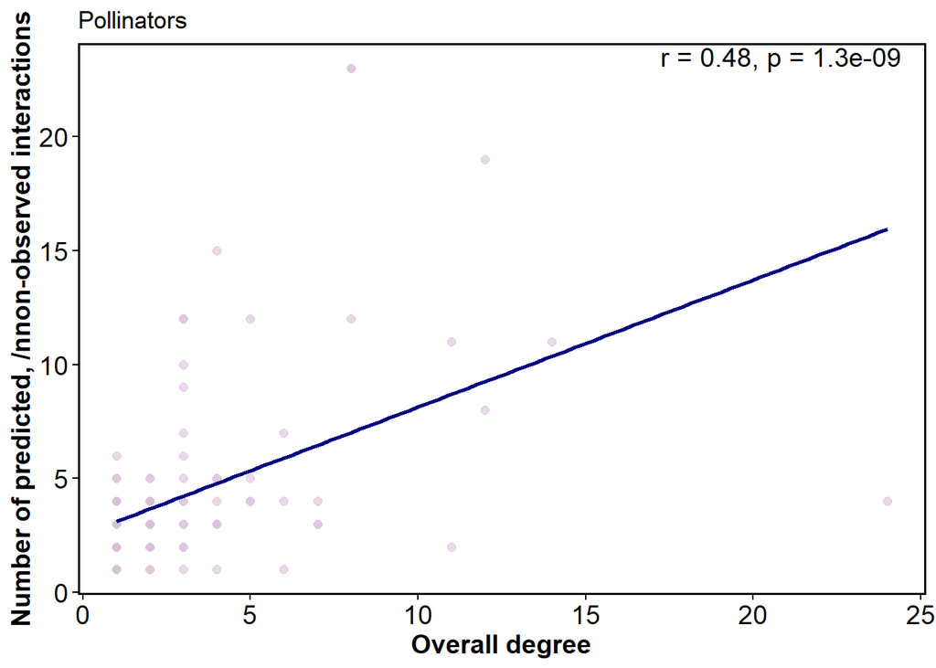

```r
# Extract correlation coefficient and p-value
r_value <- round(correlation_poll$estimate, 2)
p_value <- formatC(correlation_poll$p.value, digits = 2)  # or round as you prefer
label_text_polls <- paste0("r = ", r_value, ", p = ", p_value)

poll_degree <- ggplot(df_to_correlate, aes(x = x, y = y)) +
  geom_point(alpha = 0.6, size = 2, color = "thistle") +
  geom_smooth(method = "lm", se = FALSE, color = "navy") +
  labs(
    x = "Overall degree",
    y = "Number of predicted, /nnon-observed interactions",
    title = "Pollinators"
  ) +
  theme_minimal() + tme +
  annotate("text",
           x = Inf,
           y = Inf,
           hjust = 1.1,
           vjust = 1.2,   # Adjust depending on your data range
           label = label_text_polls,
           size = 5,
           color = "black")
poll_degree
```

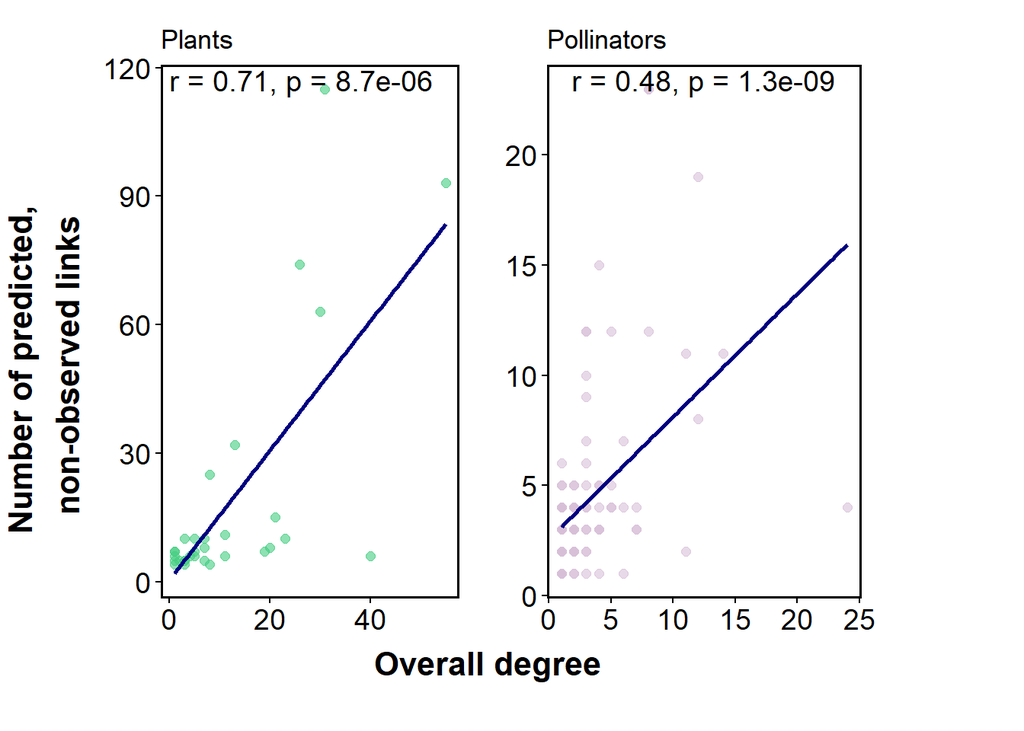

```r
final_plot <- combine_plots(plant_degree, poll_degree)
```

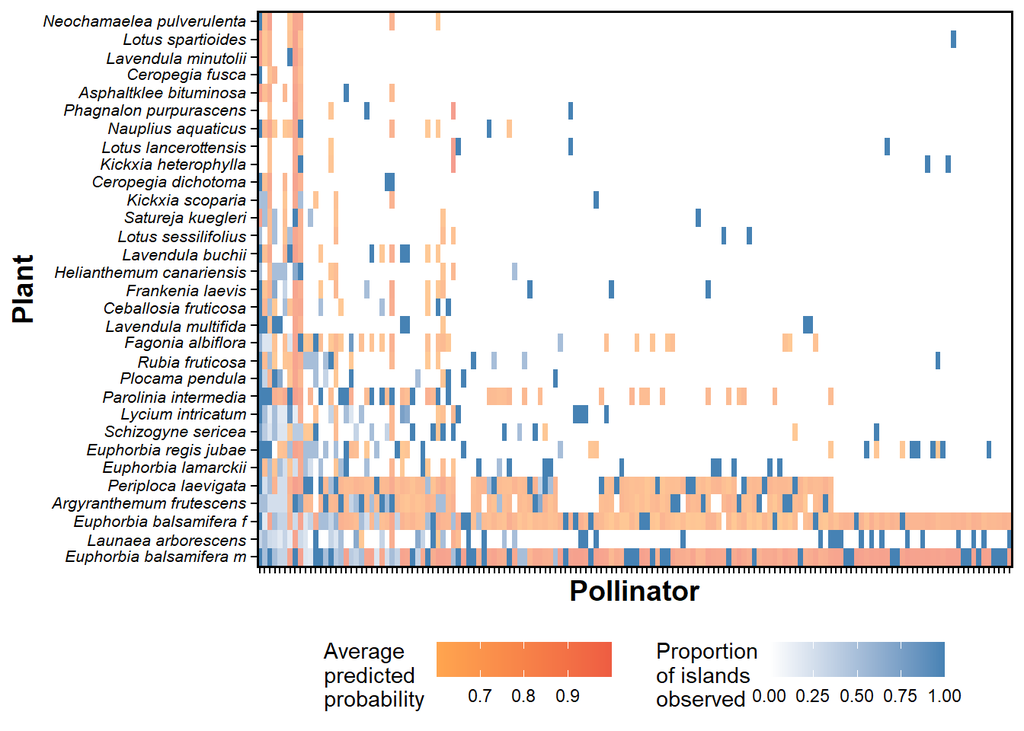

```r
# pdf(
#   file   = "degree.pdf",
#   width  = 8,
#   height = 5,
#   family = "Helvetica"
# )
#
# grid::grid.draw(final_plot)
#
# dev.off()

## ---- never-observed links ----
### ---- heatmap related to island proportion ----
# here we visualize the links that were never observed yet predicted to exist by the algorithm, and alongside them interactions that were observed, and the proportion of islands in which these interactions were observed.

# order species by their degree
df_summary <- df_summary %>% left_join(overall_poll_degree, by="node_to")
df_summary <- df_summary %>% left_join(overall_plant_degree, by="node_from")

# Determine the order for plants based on overall_plant_degree
plant_order <- df_summary %>%
  distinct(node_from, overall_plant_degree) %>%
  arrange(desc(overall_plant_degree)) %>%
  pull(node_from)

# Determine the order for pollinators based on overall_poll_degree
poll_order <- df_summary %>%
  distinct(node_to, overall_poll_degree) %>%
  arrange(desc(overall_poll_degree)) %>%
  pull(node_to)

# Reset the levels for the species factors
df_summary$node_from <- factor(df_summary$node_from, levels = plant_order)
df_summary$node_to   <- factor(df_summary$node_to, levels = poll_order)


map_missing_links <- ggplot(df_summary, aes(x = node_to, y = node_from)) +
  # First layer: background heatmap for proportion observed (blue gradient)
  geom_tile(aes(fill = avg_prop)) +
  scale_fill_gradient(low = "white", high = "steelblue",
                      name = "Proportion\nof islands\nobserved") +

  # Reset fill scale so the next layer can have its own gradient
  new_scale_fill() +

  # Second layer: overlay only cells that were never observed but have high predicted value
  geom_tile(
    data = df_summary %>% filter(avg_prop == 0, avg_sigm_predicted > best_discrete_threshold),
    aes(fill = avg_sigm_predicted),
    alpha = 0.6
  ) +
  scale_fill_gradient(low = "tan1", high = "tomato2",
                      name = "Average \npredicted \nprobability") +

  # Final adjustments
  theme_minimal() +
  labs(x = "Pollinator", y = "Plant") +
  theme(
    axis.text.x = element_blank(),
    axis.text.y = element_text(size = 8),
    legend.position = "bottom",         # Place legends at the bottom
    legend.box = "horizontal"
  ) + tme +
  scale_y_discrete(labels = function(x) lapply(strsplit(x, "_"), function(y) {
    bquote(italic(.(paste(y, collapse = " "))))
  }))

print(map_missing_links)
```

```r
# pdf(
#   file   = "map_missing_links.pdf",
#   width  = 11,    # inches
#   height = 6,
#   family = "Helvetica"   # or another installed font
# )
# print(map_missing_links)
# dev.off()     # close the file

### ---- difference in added links: diag vs. off-diags ----
# missing links map for diag and off-daigonal seperately

df_island_sep <- df_island %>%
  separate(island_id, into = c("island1", "island2"), sep = "_", convert = TRUE)

df_island_diag <- df_island_sep %>%
  filter(island1 == island2)

df_summary_diag <- df_island_diag %>%
  group_by(node_from, node_to) %>%
  summarise(
    avg_prop = mean(observed, na.rm = TRUE),       # proportion of islands with observation
    avg_sigm_predicted = mean(island_sigm_predicted, na.rm = TRUE),
    n_islands = n(),  # number of islands contributing
    .groups = "drop"
  )

# 3. Remove interactions that were never observed and predicted as zero.
# df_summary <- df_summary %>%
#   filter(!(avg_prop == 0 & avg_sigm_predicted < 0.5))

df_never_observed <- df_summary_diag %>%
  filter(avg_prop == 0, avg_sigm_predicted > best_discrete_threshold) %>%
  group_by(node_from) %>%
  summarise(count_never_observed = n(), .groups = "drop")

df_never_observed_poll <- df_summary_diag %>%
  filter(avg_prop == 0, avg_sigm_predicted > best_discrete_threshold) %>%
  group_by(node_to) %>%
  summarise(count_never_observed = n(), .groups = "drop")

never_plants_degree <- df_never_observed %>% left_join(avg_plant_degree, by="node_from")

# for overall degree

never_plants_degree_overall <- df_never_observed %>% left_join(overall_plant_degree, by="node_from")

never_poll_degree_overall <- df_never_observed_poll %>% left_join(overall_poll_degree, by="node_to")

# if we want to omit the Euphorbias
# never_plants_degree_overall <- never_plants_degree_overall %>%
#   filter(!node_from %in% c("Euphorbia_balsamifera_m", "Euphorbia_balsamifera_f"))

# correlation
df_to_correlate <- never_plants_degree_overall
df_to_correlate$x <- df_to_correlate$overall_plant_degree
df_to_correlate$y <- df_to_correlate$count_never_observed

correlation_plants <- cor.test(df_to_correlate$x, df_to_correlate$y, use = "complete.obs", method = "pearson")
correlation_plants
```

```
##
##  Pearson's product-moment correlation
##
## data:  df_to_correlate$x and df_to_correlate$y
## t = 6.9636, df = 29, p-value = 1.179e-07
## alternative hypothesis: true correlation is not equal to 0
## 95 percent confidence interval:
##  0.6068011 0.8946278
## sample estimates:
##       cor
## 0.7910537
```

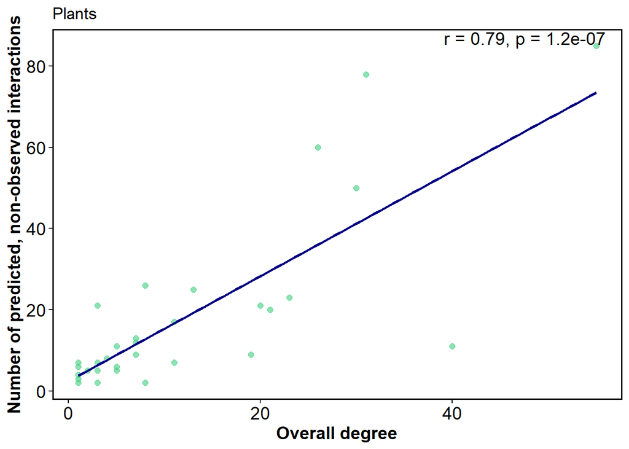

```r
# Extract correlation coefficient and p-value
r_value <- round(correlation_plants$estimate, 2)
p_value <- formatC(correlation_plants$p.value, digits = 2)  # or round as you prefer
label_text_plants <- paste0("r = ", r_value, ", p = ", p_value)

plant_degree <- ggplot(df_to_correlate, aes(x = x, y = y)) +
  geom_point(alpha = 0.6, size = 2, color = "seagreen3") +
  geom_smooth(method = "lm", se = FALSE, color = "navy") +
  labs(
    x = "Overall degree",
    y = "Number of predicted, non-observed interactions",
    title = "Plants"
  ) +
  theme_minimal() + tme +
  annotate("text",
           x = Inf,
           y = Inf,
           hjust = 1.1,
           vjust = 1.2,   # Adjust depending on your data range
           label = label_text_plants,
           size = 5,
           color = "black")
plant_degree
```

```r
df_to_correlate <- never_poll_degree_overall
df_to_correlate$x <- df_to_correlate$overall_poll_degree
df_to_correlate$y <- df_to_correlate$count_never_observed

correlation_poll <- cor.test(df_to_correlate$x, df_to_correlate$y, use = "complete.obs", method = "pearson")
correlation_poll
```

```
##
##  Pearson's product-moment correlation
##
## data:  df_to_correlate$x and df_to_correlate$y
## t = 6.4309, df = 141, p-value = 1.836e-09
## alternative hypothesis: true correlation is not equal to 0
## 95 percent confidence interval:
##  0.3385421 0.5939450
## sample estimates:
##       cor
## 0.4762262
```

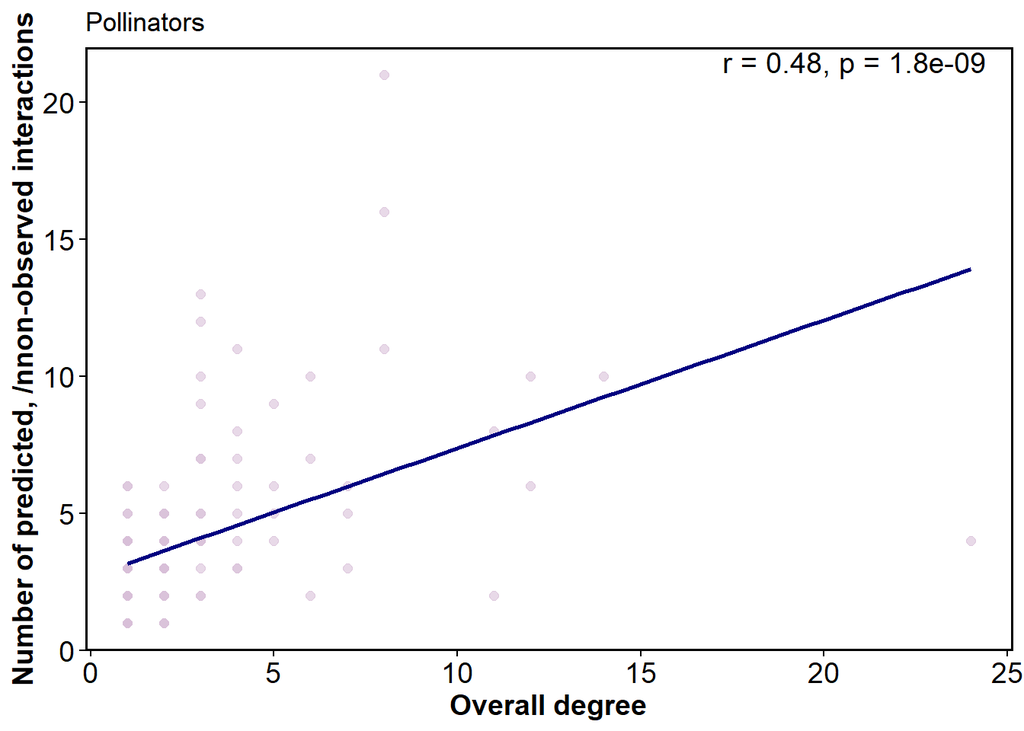

```r
# Extract correlation coefficient and p-value
r_value <- round(correlation_poll$estimate, 2)
p_value <- formatC(correlation_poll$p.value, digits = 2)  # or round as you prefer
label_text_polls <- paste0("r = ", r_value, ", p = ", p_value)

poll_degree <- ggplot(df_to_correlate, aes(x = x, y = y)) +
  geom_point(alpha = 0.6, size = 2, color = "thistle") +
  geom_smooth(method = "lm", se = FALSE, color = "navy") +
  labs(
    x = "Overall degree",
    y = "Number of predicted, /nnon-observed interactions",
    title = "Pollinators"
  ) +
  theme_minimal() + tme +
  annotate("text",
           x = Inf,
           y = Inf,
           hjust = 1.1,
           vjust = 1.2,   # Adjust depending on your data range
           label = label_text_polls,
           size = 5,
           color = "black")
poll_degree
```

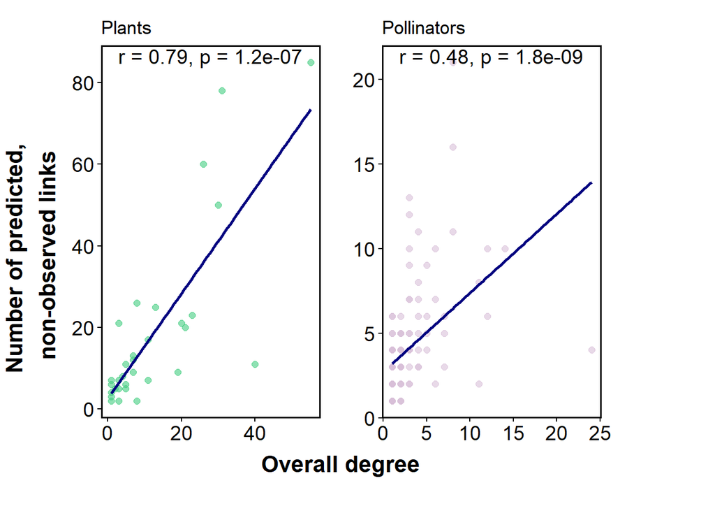

```r
final_plot <- combine_plots(plant_degree, poll_degree)
```

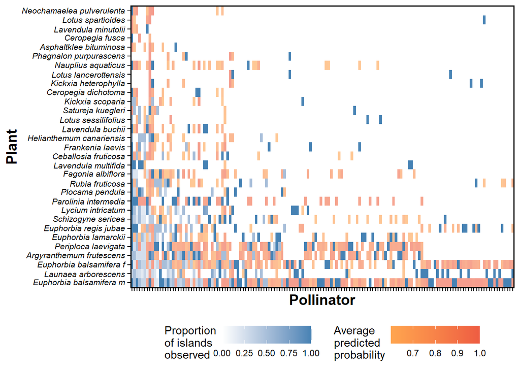

```r
# order species by their degree
df_summary_diag <- df_summary_diag %>% left_join(overall_poll_degree, by="node_to")
df_summary_diag <- df_summary_diag %>% left_join(overall_plant_degree, by="node_from")

# Determine the order for plants based on overall_plant_degree
plant_order <- df_summary_diag %>%
  distinct(node_from, overall_plant_degree) %>%
  arrange(desc(overall_plant_degree)) %>%
  pull(node_from)

# Determine the order for pollinators based on overall_poll_degree
poll_order <- df_summary_diag %>%
  distinct(node_to, overall_poll_degree) %>%
  arrange(desc(overall_poll_degree)) %>%
  pull(node_to)

# Reset the levels for the species factors
df_summary_diag$node_from <- factor(df_summary_diag$node_from, levels = plant_order)
df_summary_diag$node_to   <- factor(df_summary_diag$node_to, levels = poll_order)


map_missing_links_diags <- ggplot(df_summary_diag, aes(x = node_to, y = node_from)) +
  # First layer: background heatmap for proportion observed (blue gradient)
  geom_tile(aes(fill = avg_prop)) +
  scale_fill_gradient(low = "white", high = "steelblue",
                      name = "Proportion\nof islands\nobserved") +

  # Reset fill scale so the next layer can have its own gradient
  new_scale_fill() +

  # Second layer: overlay only cells that were never observed but have high predicted value
  geom_tile(
    data = df_summary_diag %>% filter(avg_prop == 0, avg_sigm_predicted > best_discrete_threshold),
    aes(fill = avg_sigm_predicted),
    alpha = 0.6
  ) +
  scale_fill_gradient(low = "tan1", high = "tomato2",
                      name = "Average \npredicted \nprobability") +

  # Final adjustments
  theme_minimal() +
  labs(x = "Pollinator", y = "Plant") +
  theme(
    axis.text.x = element_blank(),
    axis.text.y = element_text(size = 8),
    legend.position = "bottom",         # Place legends at the bottom
    legend.box = "horizontal"
  ) + tme +
  scale_y_discrete(labels = function(x) lapply(strsplit(x, "_"), function(y) {
    bquote(italic(.(paste(y, collapse = " "))))
  }))

map_missing_links_diags
```

```r
# now off-diagonals

df_island_offs <- df_island_sep %>%
  filter(island1 != island2)

df_summary_offs <- df_island_offs %>%
  group_by(node_from, node_to) %>%
  summarise(
    avg_prop = mean(observed, na.rm = TRUE),       # proportion of islands with observation
    avg_sigm_predicted = mean(island_sigm_predicted, na.rm = TRUE),
    n_islands = n(),  # number of islands contributing
    .groups = "drop"
  )

# 3. Remove interactions that were never observed and predicted as zero.
# df_summary <- df_summary %>%
#   filter(!(avg_prop == 0 & avg_sigm_predicted < 0.5))

df_never_observed <- df_summary_offs %>%
  filter(avg_prop == 0, avg_sigm_predicted > best_discrete_threshold) %>%
  group_by(node_from) %>%
  summarise(count_never_observed = n(), .groups = "drop")

df_never_observed_poll <- df_summary_offs %>%
  filter(avg_prop == 0, avg_sigm_predicted > best_discrete_threshold) %>%
  group_by(node_to) %>%
  summarise(count_never_observed = n(), .groups = "drop")

never_plants_degree <- df_never_observed %>% left_join(avg_plant_degree, by="node_from")

# for overall degree

never_plants_degree_overall <- df_never_observed %>% left_join(overall_plant_degree, by="node_from")

never_poll_degree_overall <- df_never_observed_poll %>% left_join(overall_poll_degree, by="node_to")

# if we want to omit the Euphorbias
# never_plants_degree_overall <- never_plants_degree_overall %>%
#   filter(!node_from %in% c("Euphorbia_balsamifera_m", "Euphorbia_balsamifera_f"))

# correlation
df_to_correlate <- never_plants_degree_overall
df_to_correlate$x <- df_to_correlate$overall_plant_degree
df_to_correlate$y <- df_to_correlate$count_never_observed

correlation_plants <- cor.test(df_to_correlate$x, df_to_correlate$y, use = "complete.obs", method = "pearson")
correlation_plants
```

```
##
##  Pearson's product-moment correlation
##
## data:  df_to_correlate$x and df_to_correlate$y
## t = 5.2148, df = 29, p-value = 1.396e-05
## alternative hypothesis: true correlation is not equal to 0
## 95 percent confidence interval:
##  0.4529638 0.8423528
## sample estimates:
##       cor
## 0.6956499
```

```r
# Extract correlation coefficient and p-value
r_value <- round(correlation_plants$estimate, 2)
p_value <- formatC(correlation_plants$p.value, digits = 2)  # or round as you prefer
label_text_plants <- paste0("r = ", r_value, ", p = ", p_value)

# plant_degree <- ggplot(df_to_correlate, aes(x = x, y = y)) +
#   geom_point(alpha = 0.6, size = 2, color = "seagreen3") +
#   geom_smooth(method = "lm", se = FALSE, color = "navy") +
#   labs(
#     x = "Overall degree",
#     y = "Number of predicted, non-observed interactions",
#     title = "Plants"
#   ) +
#   theme_minimal() + tme +
#   annotate("text",
#            x = Inf,
#            y = Inf,
#            hjust = 1.1,
#            vjust = 1.2,   # Adjust depending on your data range
#            label = label_text_plants,
#            size = 5,
#            color = "black")
# plant_degree

df_to_correlate <- never_poll_degree_overall
df_to_correlate$x <- df_to_correlate$overall_poll_degree
df_to_correlate$y <- df_to_correlate$count_never_observed

correlation_poll <- cor.test(df_to_correlate$x, df_to_correlate$y, use = "complete.obs", method = "pearson")
correlation_poll
```

```
##
##  Pearson's product-moment correlation
##
## data:  df_to_correlate$x and df_to_correlate$y
## t = 6.3495, df = 143, p-value = 2.691e-09
## alternative hypothesis: true correlation is not equal to 0
## 95 percent confidence interval:
##  0.3312813 0.5870939
## sample estimates:
##       cor
## 0.4689655
```

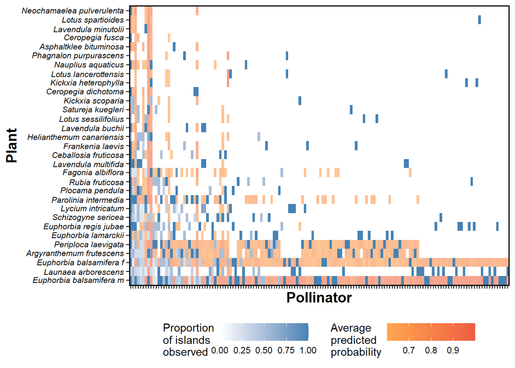

```r
# Extract correlation coefficient and p-value
r_value <- round(correlation_poll$estimate, 2)
p_value <- formatC(correlation_poll$p.value, digits = 2)  # or round as you prefer
label_text_polls <- paste0("r = ", r_value, ", p = ", p_value)

# poll_degree <- ggplot(df_to_correlate, aes(x = x, y = y)) +
#   geom_point(alpha = 0.6, size = 2, color = "thistle") +
#   geom_smooth(method = "lm", se = FALSE, color = "navy") +
#   labs(
#     x = "Overall degree",
#     y = "Number of predicted, /nnon-observed interactions",
#     title = "Pollinators"
#   ) +
#   theme_minimal() + tme +
#   annotate("text",
#            x = Inf,
#            y = Inf,
#            hjust = 1.1,
#            vjust = 1.2,   # Adjust depending on your data range
#            label = label_text_polls,
#            size = 5,
#            color = "black")
# poll_degree

# final_plot <- combine_plots(plant_degree, poll_degree)


# order species by their degree
df_summary_offs <- df_summary_offs %>% left_join(overall_poll_degree, by="node_to")
df_summary_offs <- df_summary_offs %>% left_join(overall_plant_degree, by="node_from")

# Determine the order for plants based on overall_plant_degree
plant_order <- df_summary_offs %>%
  distinct(node_from, overall_plant_degree) %>%
  arrange(desc(overall_plant_degree)) %>%
  pull(node_from)

# Determine the order for pollinators based on overall_poll_degree
poll_order <- df_summary_offs %>%
  distinct(node_to, overall_poll_degree) %>%
  arrange(desc(overall_poll_degree)) %>%
  pull(node_to)

# Reset the levels for the species factors
df_summary_offs$node_from <- factor(df_summary_offs$node_from, levels = plant_order)
df_summary_offs$node_to   <- factor(df_summary_offs$node_to, levels = poll_order)


map_missing_links_offs <- ggplot(df_summary_offs, aes(x = node_to, y = node_from)) +
  # First layer: background heatmap for proportion observed (blue gradient)
  geom_tile(aes(fill = avg_prop)) +
  scale_fill_gradient(low = "white", high = "steelblue",
                      name = "Proportion\nof islands\nobserved") +

  # Reset fill scale so the next layer can have its own gradient
  new_scale_fill() +

  # Second layer: overlay only cells that were never observed but have high predicted value
  geom_tile(
    data = df_summary_offs %>% filter(avg_prop == 0, avg_sigm_predicted > best_discrete_threshold),
    aes(fill = avg_sigm_predicted),
    alpha = 0.6
  ) +
  scale_fill_gradient(low = "tan1", high = "tomato2",
                      name = "Average \npredicted \nprobability") +

  # Final adjustments
  theme_minimal() +
  labs(x = "Pollinator", y = "Plant") +
  theme(
    axis.text.x = element_blank(),
    axis.text.y = element_text(size = 8),
    legend.position = "bottom",         # Place legends at the bottom
    legend.box = "horizontal"
  ) + tme +
  scale_y_discrete(labels = function(x) lapply(strsplit(x, "_"), function(y) {
    bquote(italic(.(paste(y, collapse = " "))))
  }))

map_missing_links_offs
```

```r
# what's the difference?
identical(df_summary_offs$node_from, df_summary_diag$node_from)
```

```
## [1] TRUE
```

```r
# 1. Which links only appear in one of the two data-frames?
only_offs <- df_summary_offs %>%
  select(node_from, node_to) %>%
  anti_join(df_summary_diag, by = c("node_from","node_to")) %>%
  mutate(source = "offs")

only_diag <- df_summary_diag %>%
  select(node_from, node_to) %>%
  anti_join(df_summary_offs, by = c("node_from","node_to")) %>%
  mutate(source = "diag")

bind_rows(only_offs, only_diag) %>%
  arrange(node_from, node_to)
```

```
## # A tibble: 0 × 3
## # ℹ 3 variables: node_from <fct>, node_to <fct>, source <chr>
```

```r
# → these are the “new” / “dropped” interactions

# 2. For the shared links, compute per-column differences.

diff_df <- full_join(
  df_summary_offs,
  df_summary_diag,
  by     = c("node_from","node_to"),
  suffix = c("_offs","_diag")
) %>%
  mutate(
    diff_avg_prop            = avg_prop_offs            - avg_prop_diag,
    diff_avg_sigm_predicted  = avg_sigm_predicted_offs  - avg_sigm_predicted_diag,
    diff_n_islands           = n_islands_offs           - n_islands_diag,
    diff_overall_poll_degree = overall_poll_degree_offs - overall_poll_degree_diag,
    diff_overall_plant_degree= overall_plant_degree_offs- overall_plant_degree_diag
  )

view(diff_df)

# these are interactions that were predicted to exist in the off-diagonals but not in the diagonal
diff_df_filtered <- diff_df %>% filter(avg_sigm_predicted_diag < 0.6 & avg_sigm_predicted_offs >= 0.6)

# and these are interactions that were predicted to exist in the diagonal but not in the off-diagonals
diff_df_diags <- diff_df %>% filter(avg_sigm_predicted_offs < 0.6 & avg_sigm_predicted_diag >= 0.6)

# # View only those with any non‐zero difference:
# diff_df %>%
#   filter(
#     diff_avg_prop           != 0 |
#       diff_avg_sigm_predicted != 0 |
#       diff_n_islands          != 0 |
#       diff_overall_poll_degree!= 0 |
#       diff_overall_plant_degree!=0
#   ) %>%
#   arrange(desc(abs(diff_avg_sigm_predicted)))

# plot the differences


df_plot <- diff_df %>%
  filter(avg_prop_diag == 0) %>%
  mutate(
    sigm_cat = case_when(
      avg_sigm_predicted_diag < best_discrete_threshold &
        avg_sigm_predicted_offs >= best_discrete_threshold ~ "offs↑ only",

      avg_sigm_predicted_offs < best_discrete_threshold &
        avg_sigm_predicted_diag >= best_discrete_threshold ~ "diag↑ only",

      avg_sigm_predicted_offs >= best_discrete_threshold &
        avg_sigm_predicted_diag >= best_discrete_threshold ~ "both↑",

      TRUE ~ NA_character_
    )
  )

# 2. build the plot
map_missing_links_diags_offs <- ggplot(df_plot, aes(x = node_to, y = node_from)) +

  # # background = observed proportion
  # geom_tile(aes(fill = avg_prop_offs)) +
  # scale_fill_gradient(
  #   low  = "white",
  #   high = "white",
  #   name = "Prop\nobserved"
  # ) +

  # allow a second fill scale
  new_scale_fill() +

  # overlay our three categories, with fixed colours
  geom_tile(
    data  = filter(df_plot, !is.na(sigm_cat)),
    aes(fill = sigm_cat),
    alpha = 0.6
  ) +
  scale_fill_manual(
    values = c(
      "offs↑ only" = "salmon",
      "diag↑ only" = "plum3",
      "both↑"       = "lightsteelblue"
    ),
    na.value = NA,
    name   = "Difference in \npredicted probability",
    labels = c(
      "offs↑ only" = "Added location ≥ 0.6\n& single location < 0.6",
      "diag↑ only" = "Single location ≥ 0.6\n& added location < 0.6",
      "both↑"       = "Both ≥ 0.6"
    )
  ) +

  # tidy up
  theme_minimal() +
  labs(x = "Pollinator", y = "Plant") +
  theme(
    axis.text.x  = element_blank(),
    axis.text.y  = element_text(size = 8),
    legend.position = "bottom",
    legend.box      = "vertical"
  ) +

  # your italic‐species labels and extra theme element
  scale_y_discrete(
    labels = function(x) lapply(strsplit(x, "_"), function(y) {
      bquote(italic(.(paste(y, collapse = " "))))
    })
  ) +
  tme

# pdf(
#   file   = "map_missing_links_diags_offs.pdf",
#   width  = 11,    # inches
#   height = 6,
#   family = "Helvetica"   # or another installed font
# )
# print(map_missing_links_diags_offs)
# dev.off()     # close the file

 # how many links did each category add?
df_plot %>%
  filter(avg_prop_diag == 0) %>%
  group_by(sigm_cat) %>%
  summarise(
    n_links = n()
  )
```

```
## # A tibble: 4 × 2
##   sigm_cat   n_links
##   <chr>        <int>
## 1 both↑          434
## 2 diag↑ only     126
## 3 offs↑ only      64
## 4 <NA>          1312
```

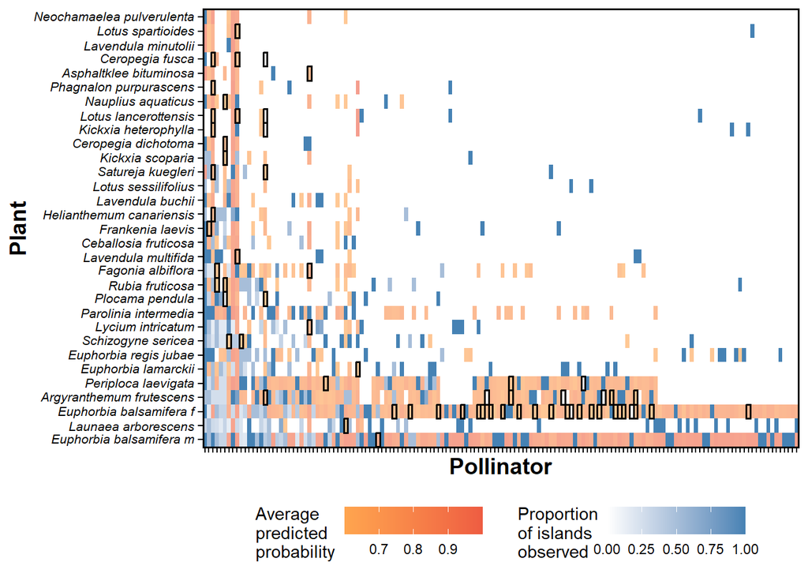

```r
# use this to mark cells predicted only by off-diags in the original heatmap:

# 1) Make sure df_summary and df_plot share the same key & then grab only the offs↑-only cells

border_df <- df_plot %>%
  # only missing links, and only off-only category
  filter(
    avg_prop_offs           == 0,
    avg_sigm_predicted_offs  >  best_discrete_threshold,
    avg_sigm_predicted_diag  <  best_discrete_threshold
  ) %>%
  select(node_from, node_to)


# 2) Join that back onto df_summary so we keep the same tile positions
df_summary_borders <- df_summary %>%
  inner_join(border_df, by = c("node_from","node_to"))

# 3) Rebuild your heatmap, and add a border layer last
map_missing_links_marked_offs <- ggplot(df_summary, aes(x = node_to, y = node_from)) +

  # background fill
  geom_tile(aes(fill = avg_prop)) +
  scale_fill_gradient(low = "white", high = "steelblue",
                      name = "Proportion\nof islands\nobserved") +

  new_scale_fill() +

  # overlay for high‐predicted, never observed
  geom_tile(
    data = df_summary %>% filter(avg_prop == 0, avg_sigm_predicted > best_discrete_threshold),
    aes(fill = avg_sigm_predicted),
    alpha = 0.6
  ) +
  scale_fill_gradient(low = "tan1", high = "tomato2",
                      name = "Average \npredicted \nprobability") +

  # border layer for offs↑ only
  geom_tile(
    data  = df_summary_borders,
    fill  = NA,
    color = "black",
    size  = 0.6
  ) +

  # final theme tweaks
  theme_minimal() +
  labs(x = "Pollinator", y = "Plant") +
  theme(
    axis.text.x = element_blank(),
    axis.text.y = element_text(size = 8),
    legend.position = "bottom",
    legend.box = "horizontal"
  ) + tme +
  scale_y_discrete(labels = function(x) lapply(strsplit(x, "_"), function(y) {
    bquote(italic(.(paste(y, collapse = " "))))
  }))

map_missing_links_marked_offs
```

[figure not shown]

```r
# pdf(
#   file   = "map_missing_links_marked_offs.pdf",
#   width  = 11,    # inches
#   height = 6,
#   family = "Helvetica"   # or another installed font
# )
# print(map_missing_links_marked_offs)
# dev.off()     # close the file

### ---- detect interactions that were never observed in the field yet consistently predicted to exist ----
# filter the interactions that were always observed as zeros yet predicted to exist
df_all_itr_zero <- df %>%
  group_by(node_from, node_to) %>%
  # Check if all rows for that interaction have original_links == 0
  filter(all(original_links == 0)) %>%
  filter(removed == 1) %>%
  filter(predicted_prob_sigm > best_discrete_threshold) %>%
  ungroup()

# filter only links that appear several times for the analysis
predicted_links <- df_all_itr_zero %>%
  group_by(node_from, node_to) %>%
  # Keep only those links/groups with >= 5 observations
  filter(n() >= 5) %>%
  summarise(
    n         = n(),
    mean_pred = mean(predicted_prob_sigm, na.rm = TRUE),
    sd_pred   = sd(predicted_prob_sigm, na.rm = TRUE),  # to check variance
    p_value   = if (sd_pred == 0) {
      NA_real_  # can't run a t-test if there's no variance
    } else {
      t.test(predicted_prob_sigm, mu = best_discrete_threshold)$p.value
    },
    .groups   = "drop"
  )

write_csv(predicted_links, "predicted_non_observed_links.csv")

most_probable_20 <- predicted_links %>%
  arrange(desc(mean_pred)) %>%
  head(20)

#write.csv(most_probable_20, 'most_probable_20_unobserved_links.csv')

df_summary_sign <- predicted_links %>% filter(p_value < 0.05)

df_top_10 <- predicted_links %>%
  # Order by ascending p-value
  arrange(p_value) %>%
  # Take the first 10 rows
  slice(1:10)

missing_links <- ggplot(df_top_10,
       aes(x = reorder(paste(node_to, node_from, sep = " - "), mean_pred),
           y = mean_pred,
           fill = p_value < 0.05)) +
  geom_col(fill = "lightsteelblue") +
  geom_errorbar(aes(ymin = mean_pred - sd_pred, ymax = mean_pred + sd_pred),
                width = 0.2) +
  coord_flip() +
  #scale_fill_manual(name = "Significant?", values = c("gray70", "tomato")) +
  tme +
  scale_x_discrete(
    labels = function(x) sapply(x, function(lbl) {
      # 1) Replace underscores with a tilde (for spacing in plotmath)
      #    e.g., "Euphorbia_balsamifera_f" => "Euphorbia~balsamifera~f"
      lbl_tilde <- gsub("_", "~", lbl)
      # 2) Wrap in italic(), so the entire thing is in italics
      #    expression syntax: parse(text="italic(Euphorbia~balsamifera~f)")
      parse(text = paste0("italic(", lbl_tilde, ")"))
    })) +
  labs(
    x = "Link (pollinator - plant)",
    y = "Mean predicted value"
    #title = "Mean predicted value and significance"
  ) +
  theme(axis.title.y = element_text(margin = ggplot2::margin(r = 15)))
#
# pdf(
#   file   = "missing_links.pdf",
#   width  = 9,    # inches
#   height = 6,
#   family = "Helvetica"   # or another installed font
# )
# print(missing_links)
# dev.off()     # close the file

# do the most probable interactions differ between diags and off-diags?
# most probable - diag

df_all_itr_zero_diag <- df %>%
  group_by(node_from, node_to) %>%
  # Check if all rows for that interaction have original_links == 0
  filter(all(original_links == 0)) %>%
  filter(removed == 1) %>%
  filter(train_layer == test_layer) %>%
  filter(predicted_prob_sigm > best_discrete_threshold) %>%
  ungroup()

# filter only links that appear several times for the analysis
predicted_links_diag <- df_all_itr_zero_diag %>%
  group_by(node_from, node_to) %>%
  # Keep only those links/groups with >= 5 observations
  filter(n() >= 5) %>%
  summarise(
    n         = n(),
    mean_pred = mean(predicted_prob_sigm, na.rm = TRUE),
    sd_pred   = sd(predicted_prob_sigm, na.rm = TRUE),  # to check variance
    p_value   = if (sd_pred == 0) {
      NA_real_  # can't run a t-test if there's no variance
    } else {
      t.test(predicted_prob_sigm, mu = best_discrete_threshold)$p.value
    },
    .groups   = "drop"
  )

most_probable_20_diag <- predicted_links_diag %>%
  arrange(desc(mean_pred)) %>%
  head(20)

df_summary_sign_diag <- predicted_links_diag %>% filter(p_value < 0.05)

df_top_10_diag <- predicted_links_diag %>%
  # Order by ascending p-value
  arrange(p_value) %>%
  # Take the first 10 rows
  slice(1:10)

missing_links_diag <- ggplot(df_top_10_diag,
                        aes(x = reorder(paste(node_to, node_from, sep = " - "), mean_pred),
                            y = mean_pred,
                            fill = p_value < 0.05)) +
  geom_col(fill = "thistle") +
  geom_errorbar(aes(ymin = mean_pred - sd_pred, ymax = mean_pred + sd_pred),
                width = 0.2) +
  coord_flip() +
  #scale_fill_manual(name = "Significant?", values = c("gray70", "tomato")) +
  tme +
  scale_x_discrete(
    labels = function(x) sapply(x, function(lbl) {
      # 1) Replace underscores with a tilde (for spacing in plotmath)
      #    e.g., "Euphorbia_balsamifera_f" => "Euphorbia~balsamifera~f"
      lbl_tilde <- gsub("_", "~", lbl)
      # 2) Wrap in italic(), so the entire thing is in italics
      #    expression syntax: parse(text="italic(Euphorbia~balsamifera~f)")
      parse(text = paste0("italic(", lbl_tilde, ")"))
    })) +
  labs(
    x = "Link (pollinator - plant)",
    y = "Mean predicted value"
    #title = "Mean predicted value and significance"
  ) +
  theme(axis.title.y = element_text(margin = ggplot2::margin(r = 15)))

# most probable - offs
df_all_itr_zero_offs <- df %>%
  group_by(node_from, node_to) %>%
  # Check if all rows for that interaction have original_links == 0
  filter(all(original_links == 0)) %>%
  filter(removed == 1) %>%
  filter(train_layer != test_layer) %>%
  filter(predicted_prob_sigm > best_discrete_threshold) %>%
  ungroup()

# filter only links that appear several times for the analysis
predicted_links_offs <- df_all_itr_zero_offs %>%
  group_by(node_from, node_to) %>%
  # Keep only those links/groups with >= 5 observations
  filter(n() >= 5) %>%
  summarise(
    n         = n(),
    mean_pred = mean(predicted_prob_sigm, na.rm = TRUE),
    sd_pred   = sd(predicted_prob_sigm, na.rm = TRUE),  # to check variance
    p_value   = if (sd_pred == 0) {
      NA_real_  # can't run a t-test if there's no variance
    } else {
      t.test(predicted_prob_sigm, mu = best_discrete_threshold)$p.value
    },
    .groups   = "drop"
  )

most_probable_20_offs <- predicted_links_offs %>%
  arrange(desc(mean_pred)) %>%
  head(20)

df_summary_sign_offs <- predicted_links_offs %>% filter(p_value < 0.05)

df_top_10_offs <- predicted_links_offs %>%
  # Order by ascending p-value
  arrange(p_value) %>%
  # Take the first 10 rows
  slice(1:10)

missing_links_offs <- ggplot(df_top_10_offs,
                             aes(x = reorder(paste(node_to, node_from, sep = " - "), mean_pred),
                                 y = mean_pred,
                                 fill = p_value < 0.05)) +
  geom_col(fill = "salmon") +
  geom_errorbar(aes(ymin = mean_pred - sd_pred, ymax = mean_pred + sd_pred),
                width = 0.2) +
  coord_flip() +
  #scale_fill_manual(name = "Significant?", values = c("gray70", "tomato")) +
  tme +
  scale_x_discrete(
    labels = function(x) sapply(x, function(lbl) {
      # 1) Replace underscores with a tilde (for spacing in plotmath)
      #    e.g., "Euphorbia_balsamifera_f" => "Euphorbia~balsamifera~f"
      lbl_tilde <- gsub("_", "~", lbl)
      # 2) Wrap in italic(), so the entire thing is in italics
      #    expression syntax: parse(text="italic(Euphorbia~balsamifera~f)")
      parse(text = paste0("italic(", lbl_tilde, ")"))
    })) +
  labs(
    x = "Link (pollinator - plant)",
    y = "Mean predicted value"
    #title = "Mean predicted value and significance"
  ) +
  theme(axis.title.y = element_text(margin = ggplot2::margin(r = 15)))


# 1. Build a “link” identifier in each df
df_offs <- df_top_10_offs %>%
  mutate(
    link      = paste(node_to, node_from, sep = " - ")
  )

df_diag <- df_top_10_diag %>%
  mutate(
    link      = paste(node_to, node_from, sep = " - ")
  )

# 2. Figure out which links are shared
shared_links <- intersect(df_offs$link, df_diag$link)

# 3. Add a flag to each data-frame
df_offs <- df_offs %>%
  mutate(is_shared = link %in% shared_links)

df_diag <- df_diag %>%
  mutate(is_shared = link %in% shared_links)

# 4. Rebuild your two plots, mapping fill to that flag
missing_links_offs <- ggplot(df_offs,
                             aes(x = reorder(link, mean_pred),
                                 y = mean_pred,
                                 fill = is_shared)) +
  geom_col() +
  geom_errorbar(aes(ymin = mean_pred - sd_pred, ymax = mean_pred + sd_pred),
                width = 0.2) +
  coord_flip() +
  scale_fill_manual(
    name   = "Shared in both\nplots?",
    values = c(`FALSE` = "salmon",       # unique to offs
               `TRUE`  = "lightsteelblue"),        # shared
    labels = c(`FALSE` = "Offs-only",    # adjust labels if you like
               `TRUE`  = "Both")
  ) +
  tme +
  labs(x = "Link (pollinator - plant)", y = "Mean predicted value") +
  theme(axis.title.y = element_text(margin = ggplot2::margin(r = 15))) +
  scale_x_discrete(
    labels = function(x) sapply(x, function(lbl) {
      lbl_tilde <- gsub("_", "~", lbl)
      parse(text = paste0("italic(", lbl_tilde, ")"))
    })
  )

missing_links_diag <- ggplot(df_diag,
                             aes(x = reorder(link, mean_pred),
                                 y = mean_pred,
                                 fill = is_shared)) +
  geom_col() +
  geom_errorbar(aes(ymin = mean_pred - sd_pred, ymax = mean_pred + sd_pred),
                width = 0.2) +
  coord_flip() +
  scale_fill_manual(
    name   = "Shared in both\nplots?",
    values = c(`FALSE` = "thistle",      # unique to diag
               `TRUE`  = "lightsteelblue"),        # shared
    labels = c(`FALSE` = "Diag-only",
               `TRUE`  = "Both")
  ) +
  tme +
  labs(x = "Link (pollinator - plant)", y = "Mean predicted value") +
  theme(axis.title.y = element_text(margin = ggplot2::margin(r = 15))) +
  scale_x_discrete(
    labels = function(x) sapply(x, function(lbl) {
      lbl_tilde <- gsub("_", "~", lbl)
      parse(text = paste0("italic(", lbl_tilde, ")"))
    })
  )

# 5. Put them side by side
(missing_links_offs + missing_links_diag) &
  theme(axis.text.y = element_text(size = 7))
```

```r
## ---- distance effect ----
### ---- add distances and location names ----
distance_table <- read.csv("distance_between_sites_canary.csv", row.names = NULL)

# proceed for both island scale and site scale and compare the trends
### ---- island scale ----
# Function to extract island names (removes "_site_X")
extract_island <- function(name) {
  gsub("_site_[12]", "", name)
}

# Create new table with averaged distances at the island level
distance_island_table <- distance_table %>%
  mutate(
    from_island = extract_island(from),
    to_island = extract_island(to)
  ) %>%
  group_by(from_island, to_island) %>%
  summarise(
    avg_distance_m = mean(distance_m),
    avg_distance_km = mean(distance_km),
    .groups = "drop"
  ) %>%
  mutate(
    avg_distance_m = ifelse(from_island == to_island, 0, avg_distance_m),
    avg_distance_km = ifelse(from_island == to_island, 0, avg_distance_km)
  ) %>%
  rename(from = from_island, to = to_island)  # Rename after calculation

# Print result
print(distance_island_table)
```

```
## # A tibble: 49 × 4
##    from          to             avg_distance_m avg_distance_km
##    <chr>         <chr>                   <dbl>           <dbl>
##  1 El_Hierro     El_Hierro                  0              0
##  2 El_Hierro     Fuerteventura         455677.           456.
##  3 El_Hierro     Gran_Canaria          274347.           274.
##  4 El_Hierro     La_Gomera              80113.            80.1
##  5 El_Hierro     Tenerife_South        172763.           173.
##  6 El_Hierro     Tenerife_Teno         129414.           129.
##  7 El_Hierro     Western_Sahara        437371.           437.
##  8 Fuerteventura El_Hierro             455677.           456.
##  9 Fuerteventura Fuerteventura              0              0
## 10 Fuerteventura Gran_Canaria          190475.           190.
## # ℹ 39 more rows
```

```r
# Modify the 'from' and 'to' columns in distance_island_table
distance_island_table <- distance_island_table %>%
  mutate(from = gsub("_", " ", from),
         to = gsub("_", " ", to))

# Add names and distances to the main table
net <- emln::load_emln(60) # canary islands
```

```
## [1] "Creating state node map"
## [1] "Creating extended link list with node IDs"
```

```r
net$layers
```

```
## # A tibble: 14 × 5
##    layer_id name                  latitude longitude layer_name
##       <int> <chr>                    <dbl>     <dbl> <chr>
##  1        1 Tenerife_Teno_site_1      28.4     -16.9 layer_1
##  2        2 Tenerife_Teno_site_2      28.4     -16.9 layer_2
##  3        3 Tenerife_South_site_2     28.2     -16.4 layer_3
##  4        4 Tenerife_South_site_1     28.2     -16.4 layer_4
##  5        5 Gran_Canaria_site_2       27.9     -15.4 layer_5
##  6        6 Gran_Canaria_site_1       27.9     -15.4 layer_6
##  7        7 Fuerteventura_site_2      28.6     -13.9 layer_7
##  8        8 Fuerteventura_site_1      28.6     -13.9 layer_8
##  9        9 Western_Sahara_site_2     26.2     -14.4 layer_9
## 10       10 Western_Sahara_site_1     26.2     -14.4 layer_10
## 11       11 El_Hierro_site_2          27.8     -17.9 layer_11
## 12       12 El_Hierro_site_1          27.8     -17.9 layer_12
## 13       13 La_Gomera_site_2          28.0     -17.2 layer_13
## 14       14 La_Gomera_site_1          28.0     -17.2 layer_14
```

```r
net_name <- net$layers %>% select(layer_id, name)
net_name
```

```
## # A tibble: 14 × 2
##    layer_id name
##       <int> <chr>
##  1        1 Tenerife_Teno_site_1
##  2        2 Tenerife_Teno_site_2
##  3        3 Tenerife_South_site_2
##  4        4 Tenerife_South_site_1
##  5        5 Gran_Canaria_site_2
##  6        6 Gran_Canaria_site_1
##  7        7 Fuerteventura_site_2
##  8        8 Fuerteventura_site_1
##  9        9 Western_Sahara_site_2
## 10       10 Western_Sahara_site_1
## 11       11 El_Hierro_site_2
## 12       12 El_Hierro_site_1
## 13       13 La_Gomera_site_2
## 14       14 La_Gomera_site_1
```

```r
net_name <- net_name %>%
  mutate(name = gsub("_", " ", name))

# Step 1: Create a new grouped tibble
new_layer_names <- net_name %>%
  mutate(group_id = (layer_id + 1) %/% 2) %>%  # Group pairs into 1, 2, 3...
  group_by(group_id) %>%
  summarise(name = gsub(" site.*", "", first(name)), .groups = "drop")  # Keep only location name

# Add to main table
result_summary <- result_summary %>%
  left_join(new_layer_names, by = c("train_layer" = "group_id")) %>%
  rename(train_layer_name = name) %>%
  left_join(new_layer_names, by = c("test_layer" = "group_id")) %>%
  rename(test_layer_name = name)

result_summary_island <- result_summary

# Add to main table
result_summary_island <- result_summary_island %>%
  left_join(
    distance_island_table,
    by = c("train_layer_name" = "from", "test_layer_name" = "to")
  ) %>%
  mutate(distance_km = if_else(train_layer_name == test_layer_name,
                               0,              # distance = 0 if same site
                               avg_distance_km))   # otherwise, keep joined distance

### ---- site scale ----
# Add names and distances to the main table
net <- emln::load_emln(60) # canary islands
```

```
## [1] "Creating state node map"
## [1] "Creating extended link list with node IDs"
```

```r
net$layers
```

```
## # A tibble: 14 × 5
##    layer_id name                  latitude longitude layer_name
##       <int> <chr>                    <dbl>     <dbl> <chr>
##  1        1 Tenerife_Teno_site_1      28.4     -16.9 layer_1
##  2        2 Tenerife_Teno_site_2      28.4     -16.9 layer_2
##  3        3 Tenerife_South_site_2     28.2     -16.4 layer_3
##  4        4 Tenerife_South_site_1     28.2     -16.4 layer_4
##  5        5 Gran_Canaria_site_2       27.9     -15.4 layer_5
##  6        6 Gran_Canaria_site_1       27.9     -15.4 layer_6
##  7        7 Fuerteventura_site_2      28.6     -13.9 layer_7
##  8        8 Fuerteventura_site_1      28.6     -13.9 layer_8
##  9        9 Western_Sahara_site_2     26.2     -14.4 layer_9
## 10       10 Western_Sahara_site_1     26.2     -14.4 layer_10
## 11       11 El_Hierro_site_2          27.8     -17.9 layer_11
## 12       12 El_Hierro_site_1          27.8     -17.9 layer_12
## 13       13 La_Gomera_site_2          28.0     -17.2 layer_13
## 14       14 La_Gomera_site_1          28.0     -17.2 layer_14
```

```r
net_name <- net$layers %>% select(layer_id, name)
net_name
```

```
## # A tibble: 14 × 2
##    layer_id name
##       <int> <chr>
##  1        1 Tenerife_Teno_site_1
##  2        2 Tenerife_Teno_site_2
##  3        3 Tenerife_South_site_2
##  4        4 Tenerife_South_site_1
##  5        5 Gran_Canaria_site_2
##  6        6 Gran_Canaria_site_1
##  7        7 Fuerteventura_site_2
##  8        8 Fuerteventura_site_1
##  9        9 Western_Sahara_site_2
## 10       10 Western_Sahara_site_1
## 11       11 El_Hierro_site_2
## 12       12 El_Hierro_site_1
## 13       13 La_Gomera_site_2
## 14       14 La_Gomera_site_1
```

```r
net_name <- net_name %>%
  mutate(name = gsub("_", " ", name))

# Modify the 'from' and 'to' columns in distance_table
distance_table <- distance_table %>%
  mutate(from = gsub("_", " ", from),
         to = gsub("_", " ", to))

# Assuming your lookup tibble is called net_name and has columns layer_id and name
#result_summary_site <- read_csv('working_df_site_scaled_evaluators_distance_50_itr_net_60.csv')
result_site <- read_csv('canary_weighted_scaled_site_net_60_50_itr.csv')
# convert negatives to zeros
result_site <- result_site %>%
  mutate(predicted_values = if_else(predicted_values < 0, 0, predicted_values))

df_removed_site <- result_site %>%
  filter(removed == 1) %>%
  mutate(predicted_prob_sigm = sigmoid(predicted_values)) %>%  # convert the predicted values to probability values in the interval (0, 1) using the logistic function
  mutate(predicted_bin_sigm = if_else(predicted_prob_sigm > best_discrete_threshold, 1, 0)) %>%
  mutate(original_binary = if_else(original_links > 0, 1, 0))

result_summary_site <- df_removed_site %>%
  group_by(emln_id, train_layer, test_layer, itr) %>%
  summarise(
    TP = sum(original_binary == 1 & predicted_bin_sigm == 1),
    FN = sum(original_binary == 1 & predicted_bin_sigm == 0),
    TN = sum(original_binary == 0 & predicted_bin_sigm == 0),
    FP = sum(original_binary == 0 & predicted_bin_sigm == 1),
    specificity = TN / (TN + FP),
    precision = TP / (TP + FP),
    recall = TP / (TP + FN),
    f1_score = 2 * (precision * recall) / (precision + recall),
    balanced_accuracy = (recall + specificity) / 2,
    mcc = (TP * TN - FP * FN) / sqrt((TP + FP) * (TP + FN) * (TN + FP) * (TN + FN)),
    mse = mean((predicted_values - original_links)^2, na.rm = TRUE),
    rmse = sqrt(mse),
    nse  = 1 - sum((predicted_values - original_links)^2, na.rm = TRUE) /
      sum((original_links   - mean(original_links, na.rm = TRUE))^2, na.rm = TRUE),
    nnse = 1 / (2 - nse)
  ) %>%
  ungroup() %>%
  group_by(emln_id, train_layer, test_layer) %>%
  summarise(
    TP = mean(TP, na.rm = TRUE),
    FN = mean(FN, na.rm = TRUE),
    TN = mean(TN, na.rm = TRUE),
    FP = mean(FP, na.rm = TRUE),
    specificity = mean(specificity, na.rm = TRUE),
    precision = mean(precision, na.rm = TRUE),
    recall = mean(recall, na.rm = TRUE),
    f1_score = mean(f1_score, na.rm = TRUE),
    balanced_accuracy = mean(balanced_accuracy, na.rm = TRUE),
    mcc = mean(mcc, na.rm = TRUE),
    mse = mean(mse, na.rm = TRUE),
    rmse = mean(rmse, na.rm = TRUE),
    nse  = mean(nse,  na.rm = TRUE),
    nnse = mean(nnse, na.rm = TRUE)
  ) %>%
  ungroup()
```

```
## can override using the `.groups` argument.
```

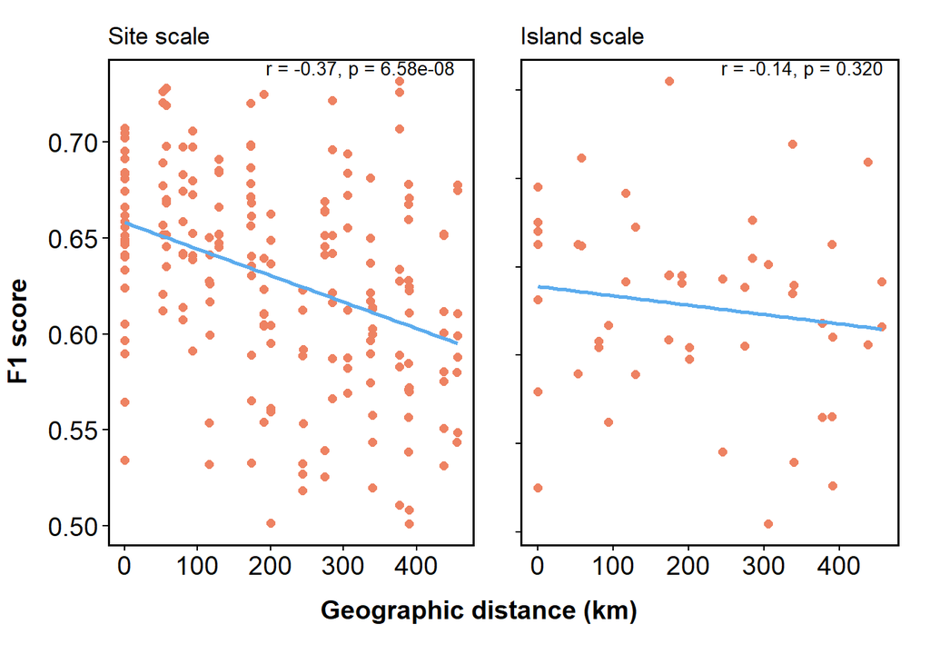

```r
result_summary_site <- result_summary_site %>%
  # Join to add train_layer_name
  left_join(net_name %>%
              rename(train_layer = layer_id,
                     train_layer_name = name),
            by = "train_layer") %>%
  # Join to add test_layer_name
  left_join(net_name %>%
              rename(test_layer = layer_id,
                     test_layer_name = name),
            by = "test_layer")


# Add to main table
result_summary_site <- result_summary_site %>%
  left_join(
    distance_table,
    by = c("train_layer_name" = "from", "test_layer_name" = "to")
  ) %>%
  mutate(distance_km = if_else(train_layer_name == test_layer_name,
                               0,              # distance = 0 if same site
                               distance_km))   # otherwise, keep joined distance

## ---- distance correlation with evaluators ----
make_cor_plot <- function(data, evaluator,
                          distance_col = "distance_km",
                          x_lab = "Geographic distance (km)",
                          y_lab = NULL,
                          extra_theme = NULL) {
  # Use evaluator as y_lab if no alternative is provided
  if (is.null(y_lab)) {
    y_lab <- evaluator
  }

  # Compute correlation between evaluator and distance
  correlation <- cor.test(data[[evaluator]], data[[distance_col]],
                          use = "complete.obs", method = "pearson")
  r_value <- round(correlation$estimate, 2)
  p_value <- ifelse(
    correlation$p.value < 0.001,
    formatC(correlation$p.value, format = "e", digits = 2),  # scientific for very small
    formatC(correlation$p.value, format = "f", digits = 3)   # fixed format otherwise
  )
  label_text <- paste0("r = ", r_value, ", p = ", p_value)

  # Create plot with label in the upper right corner using Inf coordinates
  plot <- ggplot(data, aes_string(x = distance_col, y = evaluator)) +
    geom_point(color = "salmon2", size = 2) +
    geom_smooth(method = "lm", se = FALSE, color = "steelblue2") +
    labs(x = x_lab, y = y_lab) +
    # The following places the label at the upper right of the plot area
    annotate("text", x = Inf, y = Inf, label = label_text,
             hjust = 1.1, vjust = 1.1, size = 3.5, color = "black")

  # Optionally add additional theme modifications
  if (!is.null(extra_theme)) {
    plot <- plot + extra_theme
  }

  return(plot)
}

# cor_plot_site <- make_cor_plot(result_summary_site, evaluator = "f1_score", extra_theme = tme)
# cor_plot_isl  <- make_cor_plot(result_summary_island, evaluator = "f1_score", extra_theme = tme)
#
# # To combine the plots:
# p1 <- cor_plot_site +
#   ggtitle("Site scale") +
#   theme(legend.position = "none",
#         axis.title = element_blank(),
#         plot.margin = unit(c(0.5, 0.5, 1, 0.3), "cm"))
# p2 <- cor_plot_isl +
#   ggtitle("Island scale") +
#   theme(legend.position = "none",
#         axis.title = element_blank(),
#         plot.margin = unit(c(0.5, 0.5, 1, 0.3), "cm"))
#
# combined_plots <- arrangeGrob(
#   p1, p2,
#   ncol = 2,
#   widths = c(1, 1)
# )
# combined_with_axes <- arrangeGrob(
#   combined_plots,
#   bottom = textGrob("Geographical distance (km)",
#                     gp = gpar(fontsize = 14, fontface = "bold"), vjust = -1.5),
#   left   = textGrob("F1 score", rot = 90,
#                     gp = gpar(fontsize = 14, fontface = "bold"))
# )
# final_plot <- grid.arrange(
#   combined_with_axes,
#   ncol = 2,
#   widths = c(2, 0.3)
# )
#
# final_plot

combine_two_plots <- function(p1, p2,
                              x_axis_label = "Geographic distance (km)",
                              y_axis_label = "F1 score",
                              p1_title = "Site scale",
                              p2_title = "Island scale",
                              margins = unit(c(0.5, 0.5, 1, 0.3), "cm"),
                              axis_title_fontsize = 14,
                              axis_title_fontface = "bold") {

  # Adjust first plot
  p1 <- p1 +
    ggtitle(p1_title) +
    theme(
      legend.position = "none",
      axis.title = element_blank(),
      plot.margin = margins
    )

  # Adjust second plot
  p2 <- p2 +
    ggtitle(p2_title) +
    theme(
      legend.position = "none",
      axis.title = element_blank(),
      axis.text.y = element_blank(),
      plot.margin = margins
    )

  # Combine p1 and p2 side by side
  combined_plots <- arrangeGrob(
    p1, p2,
    ncol = 2,
    widths = c(1.1, 1)
  )

  # Add global x and y axis labels
  combined_with_axes <- arrangeGrob(
    combined_plots,
    bottom = textGrob(
      x_axis_label,
      gp = gpar(fontsize = axis_title_fontsize, fontface = axis_title_fontface),
      vjust = -1.5
    ),
    left = textGrob(
      y_axis_label,
      rot = 90,
      gp = gpar(fontsize = axis_title_fontsize, fontface = axis_title_fontface)
    )
  )

  # Final arrangement
  final_plot <- grid.arrange(
    combined_with_axes,
    ncol = 2,
    widths = c(2, 0.01)
  )

  return(final_plot)
}

cor_plot_site_f1 <- make_cor_plot(result_summary_site, evaluator = "f1_score", extra_theme = tme)
cor_plot_isl_f1  <- make_cor_plot(result_summary_island, evaluator = "f1_score", extra_theme = tme)
distance_plot_f1 <- combine_two_plots(cor_plot_site_f1, cor_plot_isl_f1)
```

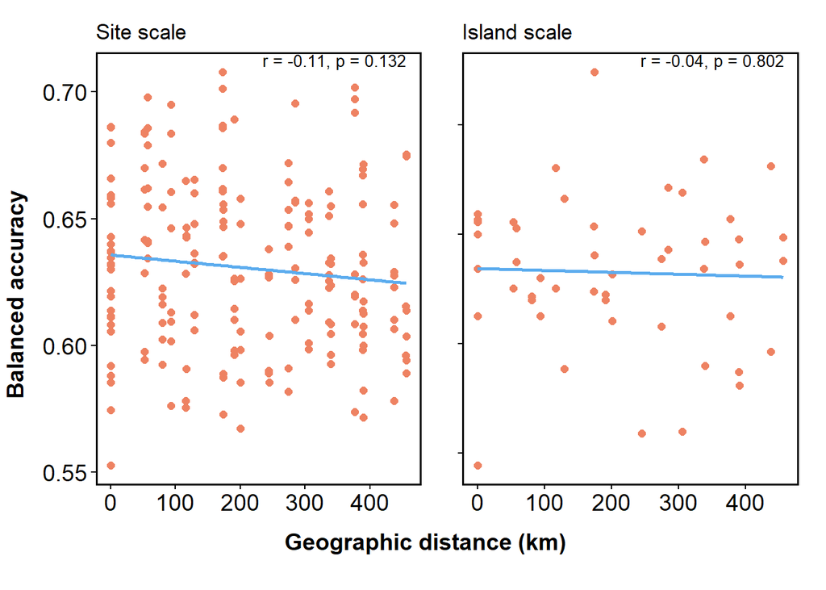

```r
# pdf(
#   file   = "distance_plot_f1.pdf",
#   width  = 8,
#   height = 4,
#   family = "Helvetica"
# )
#
# grid::grid.draw(distance_plot_f1)
#
# dev.off()
#
# png(
#   file   = "distance_plot_f1.png",
#   width  = 8,
#   height = 4,
#   units    = "in",        # could also be "px", "cm", etc.
#   res      = 300          # resolution in dots per inch
# )
#
# grid::grid.draw(distance_plot_f1)
#
# dev.off()

cor_plot_site_ba <- make_cor_plot(result_summary_site, evaluator = "balanced_accuracy", extra_theme = tme)
cor_plot_isl_ba  <- make_cor_plot(result_summary_island, evaluator = "balanced_accuracy", extra_theme = tme)
final_plot_ba <- combine_two_plots(cor_plot_site_ba, cor_plot_isl_ba, y_axis_label = "Balanced accuracy")
```

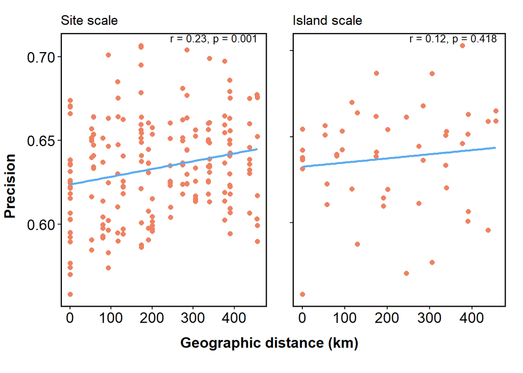

```r
cor_plot_site_precision <- make_cor_plot(result_summary_site, evaluator = "precision", extra_theme = tme)
cor_plot_isl_precision  <- make_cor_plot(result_summary_island, evaluator = "precision", extra_theme = tme)
final_plot_precision <- combine_two_plots(cor_plot_site_precision, cor_plot_isl_precision, y_axis_label = "Precision")
```

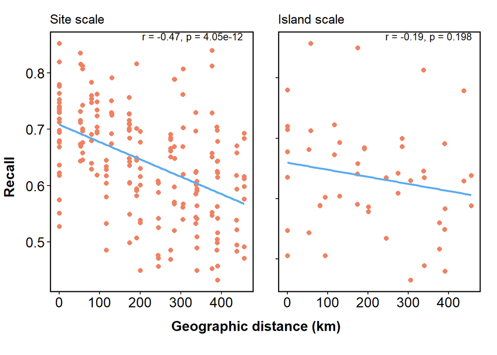

```r
cor_plot_site_recall <- make_cor_plot(result_summary_site, evaluator = "recall", extra_theme = tme)
cor_plot_isl_recall  <- make_cor_plot(result_summary_island, evaluator = "recall", extra_theme = tme)
final_plot_recall <- combine_two_plots(cor_plot_site_recall, cor_plot_isl_recall, y_axis_label = "Recall")
```

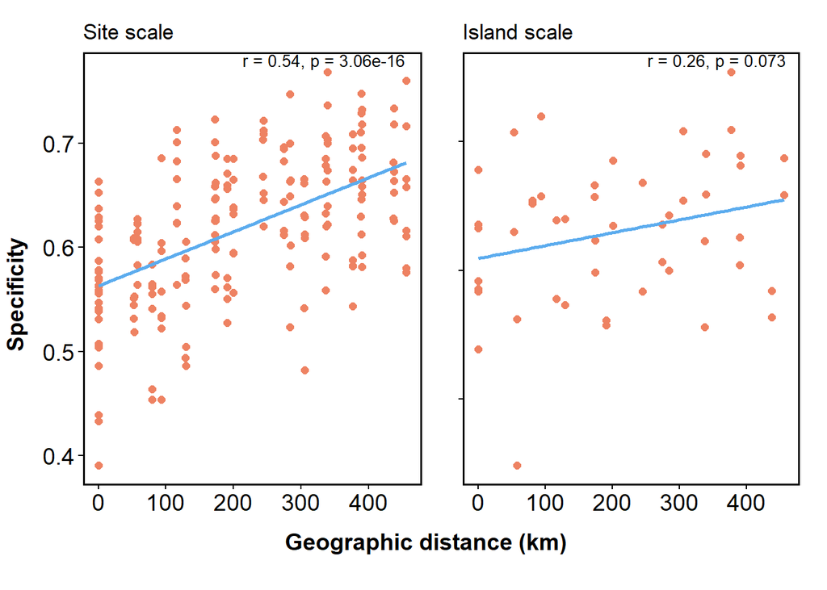

```r
cor_plot_site_specificity <- make_cor_plot(result_summary_site, evaluator = "specificity", extra_theme = tme)
cor_plot_isl_specificity  <- make_cor_plot(result_summary_island, evaluator = "specificity", extra_theme = tme)
final_plot_specificity <- combine_two_plots(cor_plot_site_specificity, cor_plot_isl_specificity, y_axis_label = "Specificity")
```

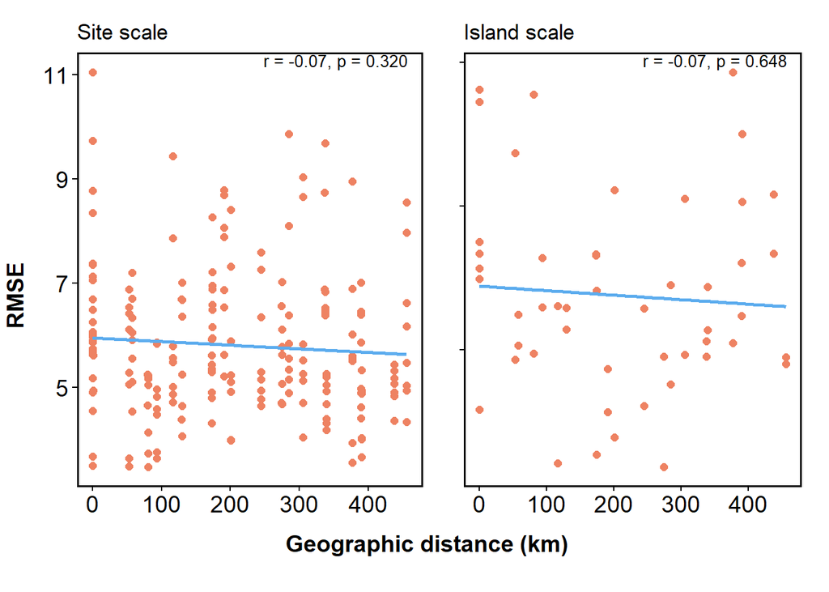

```r
cor_plot_site_rmse <- make_cor_plot(result_summary_site, evaluator = "rmse", extra_theme = tme)
cor_plot_isl_rmse  <- make_cor_plot(result_summary_island, evaluator = "rmse", extra_theme = tme)
final_plot_rmse <- combine_two_plots(cor_plot_site_rmse, cor_plot_isl_rmse, y_axis_label = "RMSE")
```

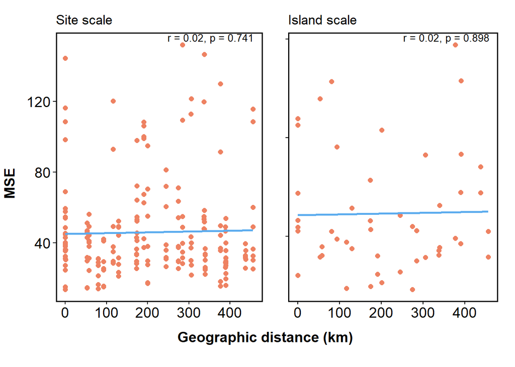

```r
cor_plot_site_mse <- make_cor_plot(result_summary_site, evaluator = "mse", extra_theme = tme)
cor_plot_isl_mse  <- make_cor_plot(result_summary_island, evaluator = "mse", extra_theme = tme)
final_plot_mse <- combine_two_plots(cor_plot_site_mse, cor_plot_isl_mse, y_axis_label = "MSE")
```

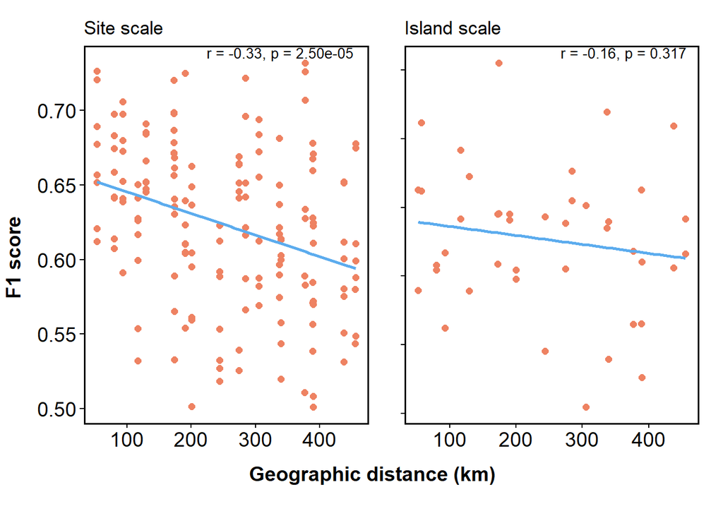

```r
make_cor_plot_line <- function(data, evaluator,
                          distance_col = "distance_km",
                          x_lab = "Geographic distance (km)",
                          y_lab = NULL,
                          extra_theme = NULL) {
  # Use evaluator as y_lab if no alternative is provided
  if (is.null(y_lab)) {
    y_lab <- evaluator
  }

  # Compute correlation between evaluator and distance
  correlation <- cor.test(data[[evaluator]], data[[distance_col]],
                          use = "complete.obs", method = "pearson")
  r_value <- round(correlation$estimate, 2)
  p_value <- ifelse(
    correlation$p.value < 0.001,
    formatC(correlation$p.value, format = "e", digits = 2),  # scientific for very small
    formatC(correlation$p.value, format = "f", digits = 3)   # fixed format otherwise
  )
  label_text <- paste0("r = ", r_value, ", p = ", p_value)

  # Create plot with label in the upper right corner using Inf coordinates
  plot <- ggplot(data, aes_string(x = distance_col, y = evaluator)) +
    geom_point(color = "salmon2", size = 2) +
    geom_smooth(method = "lm", se = FALSE, color = "steelblue2") +
    geom_hline(yintercept = 0.7, linetype = "dashed", color = "black", linewidth = 0.8) +
    labs(x = x_lab, y = y_lab) +
    # The following places the label at the upper right of the plot area
    annotate("text", x = Inf, y = Inf, label = label_text,
             hjust = 1.1, vjust = 1.1, size = 3.5, color = "black")

  # Optionally add additional theme modifications
  if (!is.null(extra_theme)) {
    plot <- plot + extra_theme
  }

  return(plot)
}

cor_plot_site_recall <- make_cor_plot_line(result_summary_site, evaluator = "recall", extra_theme = tme)
#final_plot_recall <- make_cor_plot_line(cor_plot_site_recall, cor_plot_isl_recall, y_axis_label = "Recall")

# check what happens if we remove sites in the same island
result_summary_island_dif <- result_summary_island %>% filter(train_layer != test_layer)
result_summary_site_dif <- result_summary_site %>% filter(train_layer != test_layer)

# Helper function to extract "island" per your rules
# get_island <- function(site_name) {
#   if (grepl("Tenerife Teno", site_name)) {
#     return("Tenerife Teno")
#   } else if (grepl("Tenerife South", site_name)) {
#     return("Tenerife South")
#   } else {
#     # Default: use first word as island
#     return(sub("^(\\w+).*", "\\1", site_name))
#   }
# }

# # Apply to both train and test layer names
# result_summary_site_dif$train_island <- sapply(result_summary_site_dif$train_layer_name, get_island)
# result_summary_site_dif$test_island <- sapply(result_summary_site_dif$test_layer_name, get_island)
#
# # Filter for rows where train and test island are different
# filtered_results <- result_summary_site_dif[result_summary_site_dif$train_island != result_summary_site_dif$test_island, ]

# also treat the two Tenerife "islands" as one`

# Step 1: Extract island names
result_summary_site_dif$train_island <- sub("^(\\w+).*", "\\1", result_summary_site_dif$train_layer_name)
result_summary_site_dif$test_island <- sub("^(\\w+).*", "\\1", result_summary_site_dif$test_layer_name)

# Step 2: Filter rows where island names are different
filtered_results <- result_summary_site_dif[result_summary_site_dif$train_island != result_summary_site_dif$test_island, ]

# plot
cor_plot_site_dif_f1 <- make_cor_plot(filtered_results, evaluator = "f1_score", extra_theme = tme)
cor_plot_dif_isl_f1  <- make_cor_plot(result_summary_island_dif, evaluator = "f1_score", extra_theme = tme)
distance_dif_plot_f1 <- combine_two_plots(cor_plot_site_dif_f1, cor_plot_dif_isl_f1)
```

```r
# run the previous make_cor_plot again
# pdf(
#   file   = "distance_plot_f1_different_isl.pdf",
#   width  = 7,
#   height = 4,
#   family = "Helvetica"
# )
#
# grid::grid.draw(distance_dif_plot_f1)
#
# dev.off()
#
# png(
#   file   = "distance_plot_f1_different_isl.png",
#   width  = 7,
#   height = 4,
#   units    = "in",        # could also be "px", "cm", etc.
#   res      = 300
# )
#
# grid::grid.draw(distance_dif_plot_f1)
#
# dev.off()

# use MRM test
# 1. Install & load ecodist
#install.packages("ecodist")
library(ecodist)
# 2. Make sure your data.frame is called, say, df, with columns:
#    train_layer_name, test_layer_name, f1_score, distance_km

# 3. Build square matrices of F1 and Distance
#    (layers must be in the same order for rows & cols)

# a) Get a list of all unique layers
layers <- sort(unique(c(result_summary_island_dif$train_layer, result_summary_island_dif$test_layer)))

# b) Initialize empty matrices
f1_mat      <- matrix(NA, nrow=length(layers), ncol=length(layers),
                      dimnames=list(layers, layers))
dist_mat_km <- f1_mat

# c) Fill in each cell [i,j] with the corresponding f1_score and distance_km
for(i in layers) for(j in layers) {
  # Subset rows where train=i and test=j
  sub <- result_summary_island_dif[result_summary_island_dif$train_layer==i & result_summary_island_dif$test_layer==j, ]
  if(nrow(sub)==1) {
    f1_mat[i,j]      <- sub$f1_score
    dist_mat_km[i,j] <- sub$distance_km
  }
}

# d) Because MRM uses symmetric distance matrices, average [i,j] & [j,i]
sym_average <- function(m) {
  mm <- m
  for(i in 1:nrow(mm)) for(j in 1:ncol(mm)) {
    if(i < j && !is.na(m[i,j]) && !is.na(m[j,i])) {
      avg       <- mean(c(m[i,j], m[j,i]))
      mm[i,j]   <- avg
      mm[j,i]   <- avg
    }
  }
  mm
}
f1_sym      <- sym_average(f1_mat)
dist_sym_km <- sym_average(dist_mat_km)

# e) Convert to “dist” objects (lower triangle)
dist_f1      <- as.dist(f1_sym)
dist_km      <- as.dist(dist_sym_km)

# 4. Run the MRM
#    — this will regress the F1‐distance matrix on the geographic–distance matrix
set.seed(42)   # for reproducibility of permutations
mrm_out <- MRM(dist_f1 ~ dist_km, nperm=999)

# 5. Inspect results
print(mrm_out)
```

```
## $coef
##               dist_f1      pval
## Int      6.427371e-01 0.2642643
## dist_km -6.533703e-05 0.4674675
##
## $r.squared
##        R2      pval
## 0.0504356 0.4674675
##
## $F.test
##         F    F.pval
## 1.0091748 0.4674675
```

```r
# are the results the same for asymmetrical matrices?
f1_mat      <- matrix(NA, nrow=length(layers), ncol=length(layers),
                      dimnames=list(layers, layers))
dist_mat_km <- f1_mat

# c) Fill in each cell [i,j] with the corresponding f1_score and distance_km
for(i in layers) for(j in layers) {
  # Subset rows where train=i and test=j
  sub <- result_summary_island_dif[result_summary_island_dif$train_layer==i & result_summary_island_dif$test_layer==j, ]
  if(nrow(sub)==1) {
    f1_mat[i,j]      <- sub$f1_score
    dist_mat_km[i,j] <- sub$distance_km
  }
}

dist_f1      <- as.dist(f1_mat)
dist_km      <- as.dist(dist_mat_km)

set.seed(42)   # for reproducibility of permutations
mrm_out <- MRM(dist_f1 ~ dist_km, nperm=999)

# 5. Inspect results
print(mrm_out)
```

```
## $coef
##               dist_f1      pval
## Int      0.6793584366 0.1561562
## dist_km -0.0001348196 0.3163163
##
## $r.squared
##        R2      pval
## 0.1263041 0.3163163
##
## $F.test
##         F    F.pval
## 2.7466969 0.3163163
```

```r
### ---- MRM for site scale ---- ###
layers_site <- sort(unique(c(result_summary_site_dif$train_layer, result_summary_site_dif$test_layer)))

# b) Initialize empty matrices
f1_mat_site      <- matrix(NA, nrow=length(layers_site), ncol=length(layers_site),
                      dimnames=list(layers_site, layers_site))
dist_mat_km_site <- f1_mat_site

# c) Fill in each cell [i,j] with the corresponding f1_score and distance_km
for(i in layers_site) for(j in layers_site) {
  # Subset rows where train=i and test=j
  sub <- result_summary_site_dif[result_summary_site_dif$train_layer==i & result_summary_site_dif$test_layer==j, ]
  if(nrow(sub)==1) {
    f1_mat_site[i,j]      <- sub$f1_score
    dist_mat_km_site[i,j] <- sub$distance_km
  }
}

# d) Because MRM uses symmetric distance matrices, average [i,j] & [j,i]

f1_sym_site      <- sym_average(f1_mat_site)
dist_sym_km_site <- sym_average(dist_mat_km_site)

# e) Convert to “dist” objects (lower triangle)
dist_f1_site      <- as.dist(f1_sym_site)
dist_km_site     <- as.dist(dist_sym_km_site)

# 4. Run the MRM
#    — this will regress the F1‐distance matrix on the geographic–distance matrix
set.seed(42)   # for reproducibility of permutations
mrm_out_site <- MRM(dist_f1_site ~ dist_km_site, nperm=999)

# 5. Inspect results
print(mrm_out_site)
```

```
## $coef
##               dist_f1_site        pval
## Int           0.6625358649 0.002002002
## dist_km_site -0.0001521854 0.003003003
##
## $r.squared
##          R2        pval
## 0.246115507 0.003003003
##
## $F.test
##            F       F.pval
## 29.055220355  0.003003003
```

```r
# are the results the same for asymmetric matrix for site scale?
# b) Initialize empty matrices
f1_mat_site      <- matrix(NA, nrow=length(layers_site), ncol=length(layers_site),
                           dimnames=list(layers_site, layers_site))
dist_mat_km_site <- f1_mat_site

# c) Fill in each cell [i,j] with the corresponding f1_score and distance_km
for(i in layers_site) for(j in layers_site) {
  # Subset rows where train=i and test=j
  sub <- result_summary_site_dif[result_summary_site_dif$train_layer==i & result_summary_site_dif$test_layer==j, ]
  if(nrow(sub)==1) {
    f1_mat_site[i,j]      <- sub$f1_score
    dist_mat_km_site[i,j] <- sub$distance_km
  }
}

# e) Convert to “dist” objects (lower triangle)
dist_f1_site      <- as.dist(f1_mat_site)
dist_km_site     <- as.dist(dist_mat_km_site)

# 4. Run the MRM
#    — this will regress the F1‐distance matrix on the geographic–distance matrix
set.seed(42)   # for reproducibility of permutations
mrm_out_site <- MRM(dist_f1_site ~ dist_km_site, nperm=999)

# 5. Inspect results
print(mrm_out_site)
```

```
## $coef
##               dist_f1_site        pval
## Int           0.6809017510 0.002002002
## dist_km_site -0.0001821918 0.002002002
##
## $r.squared
##          R2        pval
## 0.216561886 0.002002002
##
## $F.test
##            F       F.pval
## 24.601825673  0.002002002
```

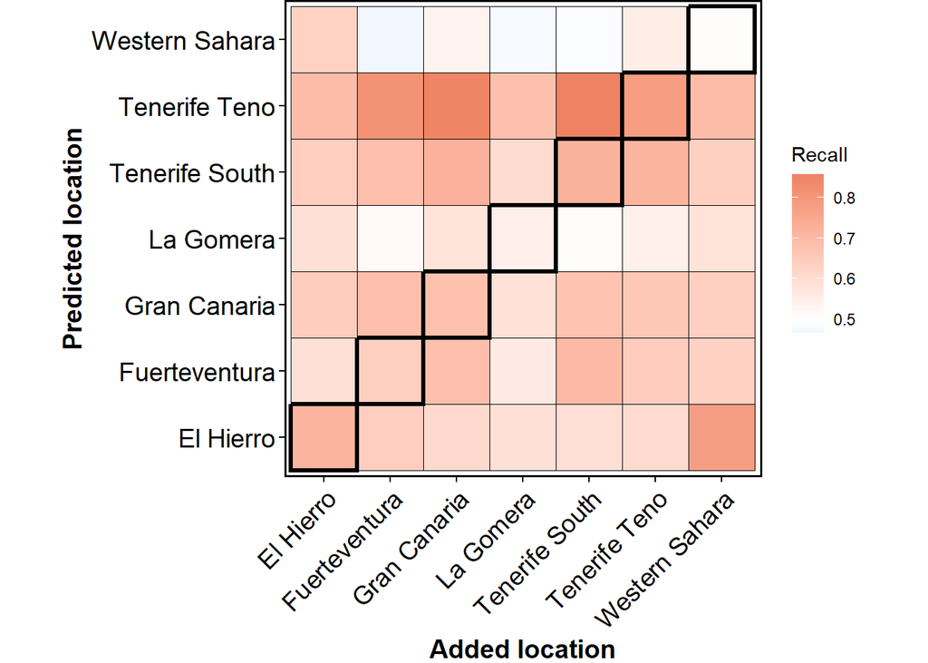

```r
# ---- plot heatmaps ----
island_heatmap_recall <-
  ggplot(result_summary_island, aes(x = train_layer_name, y = test_layer_name, fill = recall)) +
  # First draw the entire heatmap with white borders for all tiles
  geom_tile(color = "black", linewidth = 0.1) +
  # Then draw the diagonal tiles on top with black borders
  geom_tile(data = result_summary_island[result_summary_island$train_layer == result_summary_island$test_layer, ],
            color = "black", linewidth = 1.2) +  # Black borders only for diagonal tiles
  scale_fill_gradient2(low = "steelblue2", mid = "white", high = "salmon2",
                       midpoint = 0.5, na.value = "gray") +  # Set NA values to gray
  labs(x = "Added location", y = "Predicted location", fill = "Recall") +
  theme_minimal() +
  theme(
    plot.margin = unit(c(0, 0, 0, 0), "cm"),  # Minimize margins
    panel.background = element_blank(), #This ensures no panel background layers are drawn, which might add extra space.
    panel.grid.major = element_blank(),  # Remove major grid lines
    panel.grid.minor = element_blank(),  # Remove minor grid lines
    axis.text.x = element_text(angle = 45, hjust = 1, vjust = 1)  # Rotate x-axis labels by 45 degrees
  ) +
  coord_fixed() + tme

print(island_heatmap_recall)
```

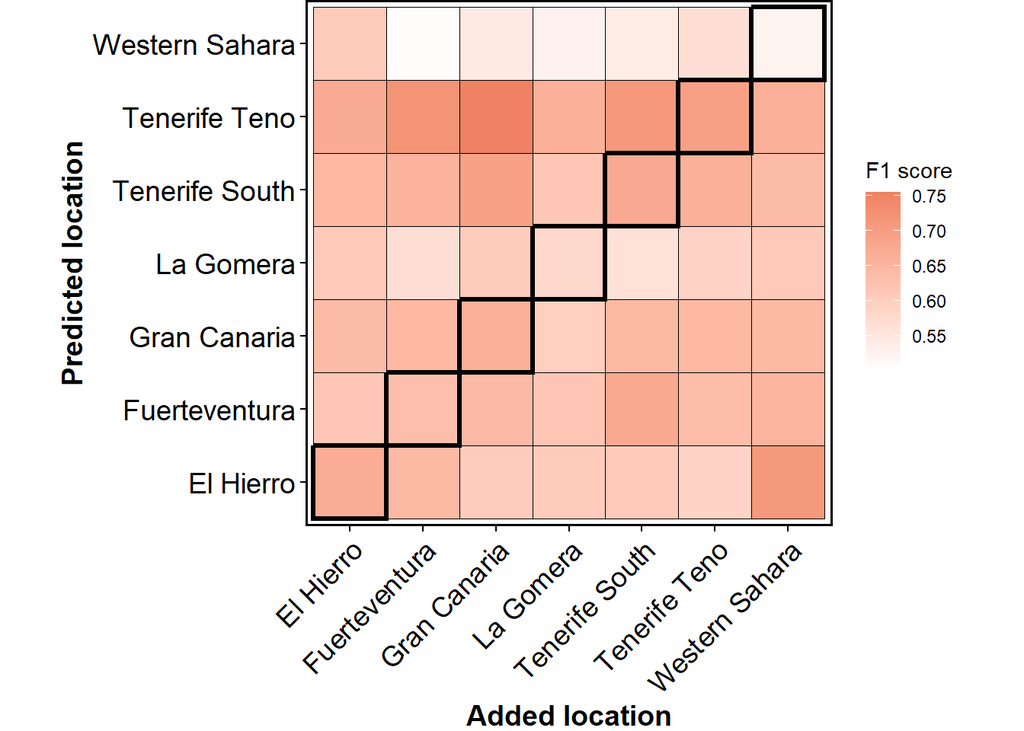

```r
island_heatmap_f1 <-
  ggplot(result_summary_island, aes(x = train_layer_name, y = test_layer_name, fill = f1_score)) +
  # First draw the entire heatmap with white borders for all tiles
  geom_tile(color = "black", linewidth = 0.1) +
  # Then draw the diagonal tiles on top with black borders
  geom_tile(data = result_summary_island[result_summary_island$train_layer == result_summary_island$test_layer, ],
            color = "black", linewidth = 1.2) +  # Black borders only for diagonal tiles
  scale_fill_gradient2(low = "lightsteelblue2", mid = "white", high = "salmon2",
                       midpoint = 0.5, na.value = "gray") +  # Set NA values to gray
  labs(x = "Added location", y = "Predicted location", fill = "F1 score") +
  theme_minimal() +
  theme(
    plot.margin = unit(c(0, 0, 0, 0), "cm"),  # Minimize margins
    panel.background = element_blank(), #This ensures no panel background layers are drawn, which might add extra space.
    panel.grid.major = element_blank(),  # Remove major grid lines
    panel.grid.minor = element_blank(),  # Remove minor grid lines
    axis.text.x = element_text(angle = 45, hjust = 1, vjust = 1)  # Rotate x-axis labels by 45 degrees
  ) +
  coord_fixed() + tme

print(island_heatmap_f1)
```

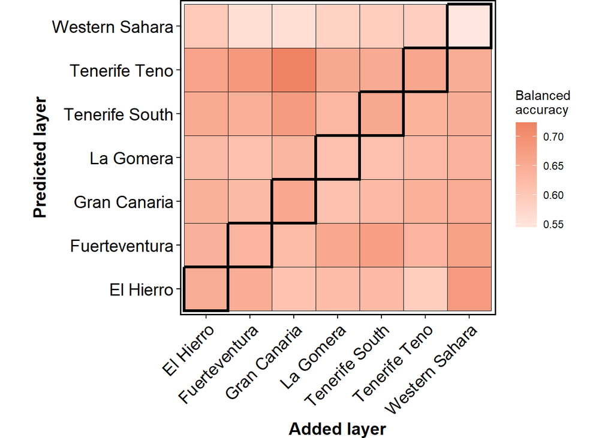

```r
# pdf(
#   file   = "island_heatmap_f1.pdf",
#   width  = 6,    # inches
#   height = 6,
#   family = "Helvetica"   # or another installed font
# )
# print(island_heatmap_f1)
# dev.off()     # close the file

island_heatmap_ba <-
  ggplot(result_summary_island, aes(x = train_layer_name, y = test_layer_name, fill = balanced_accuracy)) +
  # First draw the entire heatmap with white borders for all tiles
  geom_tile(color = "black", linewidth = 0.1) +
  # Then draw the diagonal tiles on top with black borders
  geom_tile(data = result_summary_island[result_summary_island$train_layer == result_summary_island$test_layer, ],
            color = "black", linewidth = 1.2) +  # Black borders only for diagonal tiles
  scale_fill_gradient2(low = "steelblue2", mid = "white", high = "salmon2",
                       midpoint = 0.5, na.value = "gray") +  # Set NA values to gray
  labs(x = "Added layer", y = "Predicted layer", fill = "Balanced \naccuracy") +
  theme_minimal() +
  theme(
    plot.margin = unit(c(0, 0, 0, 0), "cm"),  # Minimize margins
    panel.background = element_blank(), #This ensures no panel background layers are drawn, which might add extra space.
    panel.grid.major = element_blank(),  # Remove major grid lines
    panel.grid.minor = element_blank(),  # Remove minor grid lines
    axis.text.x = element_text(angle = 45, hjust = 1, vjust = 1)  # Rotate x-axis labels by 45 degrees
  ) +
  coord_fixed() + tme

print(island_heatmap_ba)
```

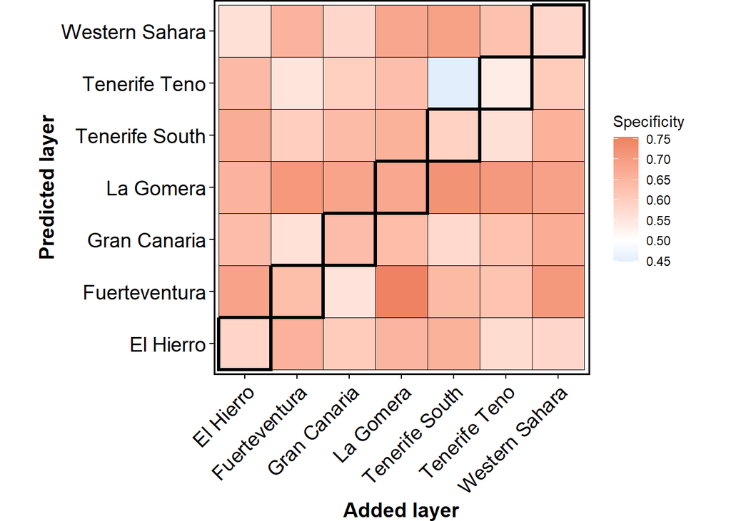

```r
island_heatmap_specificity <-
  ggplot(result_summary_island, aes(x = train_layer_name, y = test_layer_name, fill = specificity)) +
  # First draw the entire heatmap with white borders for all tiles
  geom_tile(color = "black", linewidth = 0.1) +
  # Then draw the diagonal tiles on top with black borders
  geom_tile(data = result_summary_island[result_summary_island$train_layer == result_summary_island$test_layer, ],
            color = "black", linewidth = 1.2) +  # Black borders only for diagonal tiles
  scale_fill_gradient2(low = "steelblue2", mid = "white", high = "salmon2",
                       midpoint = 0.5, na.value = "gray") +  # Set NA values to gray
  labs(x = "Added layer", y = "Predicted layer", fill = "Specificity") +
  theme_minimal() +
  theme(
    plot.margin = unit(c(0, 0, 0, 0), "cm"),  # Minimize margins
    panel.background = element_blank(), #This ensures no panel background layers are drawn, which might add extra space.
    panel.grid.major = element_blank(),  # Remove major grid lines
    panel.grid.minor = element_blank(),  # Remove minor grid lines
    axis.text.x = element_text(angle = 45, hjust = 1, vjust = 1)  # Rotate x-axis labels by 45 degrees
  ) +
  coord_fixed() + tme

print(island_heatmap_specificity)
```

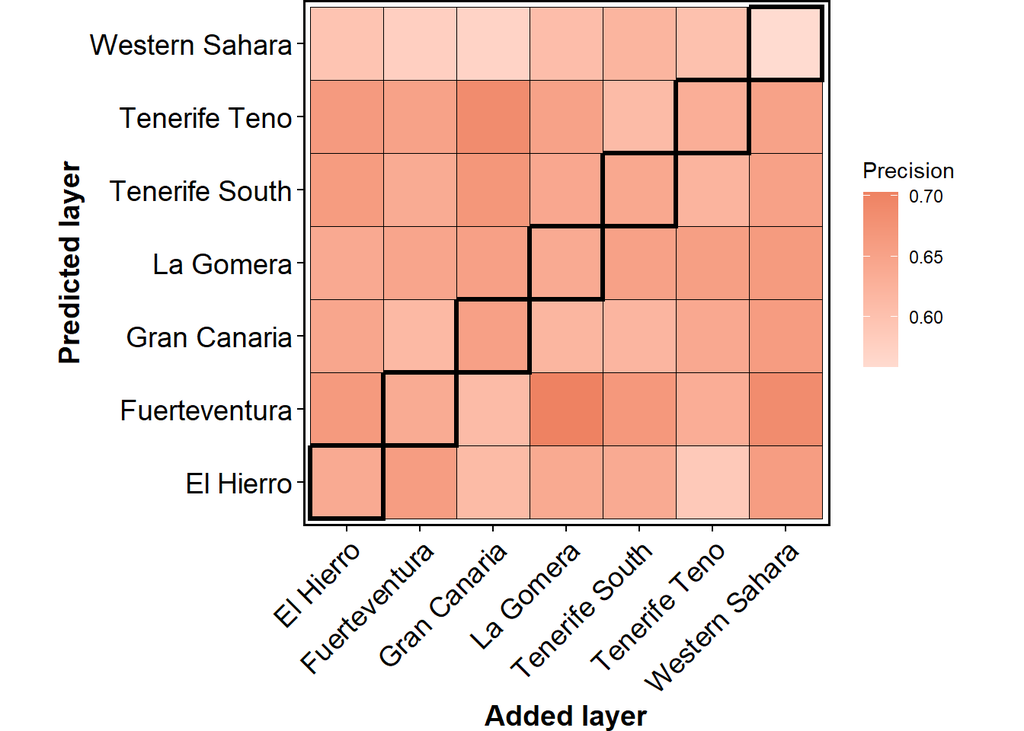

```r
island_heatmap_precision <-
  ggplot(result_summary_island, aes(x = train_layer_name, y = test_layer_name, fill = precision)) +
  # First draw the entire heatmap with white borders for all tiles
  geom_tile(color = "black", linewidth = 0.1) +
  # Then draw the diagonal tiles on top with black borders
  geom_tile(data = result_summary_island[result_summary_island$train_layer == result_summary_island$test_layer, ],
            color = "black", linewidth = 1.2) +  # Black borders only for diagonal tiles
  scale_fill_gradient2(low = "steelblue2", mid = "white", high = "salmon2",
                       midpoint = 0.5, na.value = "gray") +  # Set NA values to gray
  labs(x = "Added layer", y = "Predicted layer", fill = "Precision") +
  theme_minimal() +
  theme(
    plot.margin = unit(c(0, 0, 0, 0), "cm"),  # Minimize margins
    panel.background = element_blank(), #This ensures no panel background layers are drawn, which might add extra space.
    panel.grid.major = element_blank(),  # Remove major grid lines
    panel.grid.minor = element_blank(),  # Remove minor grid lines
    axis.text.x = element_text(angle = 45, hjust = 1, vjust = 1)  # Rotate x-axis labels by 45 degrees
  ) +
  coord_fixed() + tme

print(island_heatmap_precision)
```

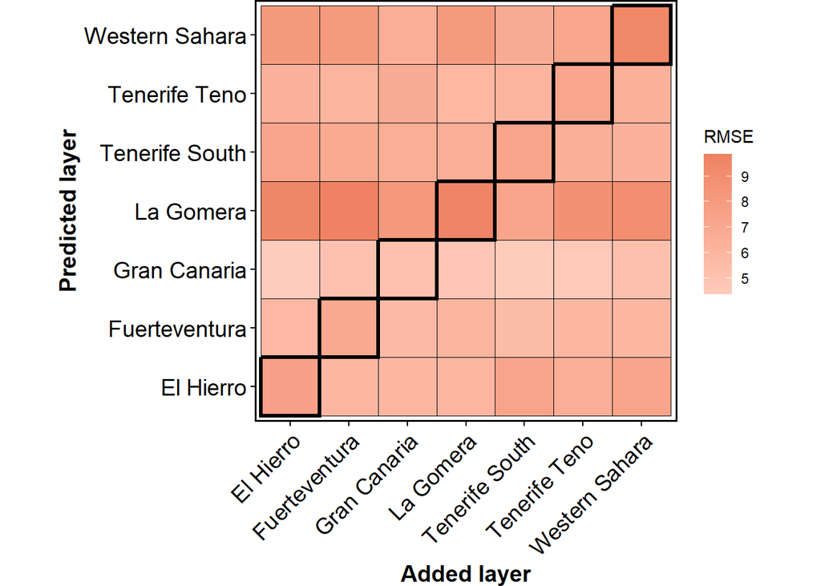

```r
island_heatmap_rmse <-
  ggplot(result_summary_island, aes(x = train_layer_name, y = test_layer_name, fill = rmse)) +
  # First draw the entire heatmap with white borders for all tiles
  geom_tile(color = "black", linewidth = 0.1) +
  # Then draw the diagonal tiles on top with black borders
  geom_tile(data = result_summary_island[result_summary_island$train_layer == result_summary_island$test_layer, ],
            color = "black", linewidth = 1.2) +  # Black borders only for diagonal tiles
  scale_fill_gradient2(low = "steelblue2", mid = "white", high = "salmon2",
                       midpoint = 0.5, na.value = "gray") +  # Set NA values to gray
  labs(x = "Added layer", y = "Predicted layer", fill = "RMSE") +
  theme_minimal() +
  theme(
    plot.margin = unit(c(0, 0, 0, 0), "cm"),  # Minimize margins
    panel.background = element_blank(), #This ensures no panel background layers are drawn, which might add extra space.
    panel.grid.major = element_blank(),  # Remove major grid lines
    panel.grid.minor = element_blank(),  # Remove minor grid lines
    axis.text.x = element_text(angle = 45, hjust = 1, vjust = 1)  # Rotate x-axis labels by 45 degrees
  ) +
  coord_fixed() + tme

print(island_heatmap_rmse)
```

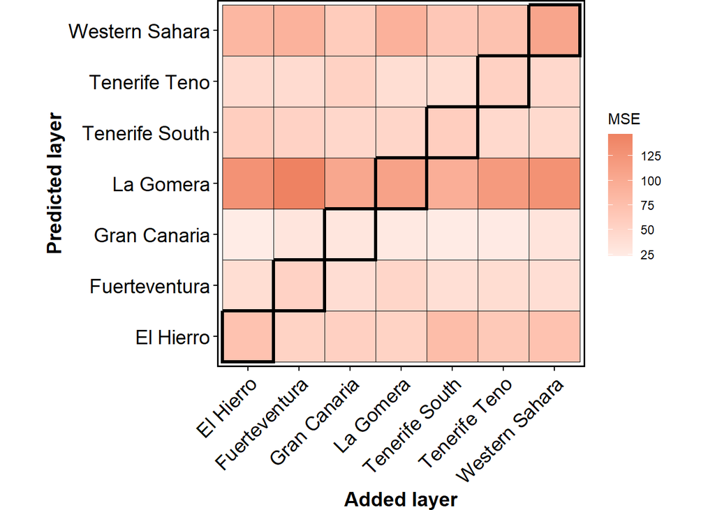

```r
island_heatmap_mse <-
  ggplot(result_summary_island, aes(x = train_layer_name, y = test_layer_name, fill = mse)) +
  # First draw the entire heatmap with white borders for all tiles
  geom_tile(color = "black", linewidth = 0.1) +
  # Then draw the diagonal tiles on top with black borders
  geom_tile(data = result_summary_island[result_summary_island$train_layer == result_summary_island$test_layer, ],
            color = "black", linewidth = 1.2) +  # Black borders only for diagonal tiles
  scale_fill_gradient2(low = "steelblue2", mid = "white", high = "salmon2",
                       midpoint = 0.5, na.value = "gray") +  # Set NA values to gray
  labs(x = "Added layer", y = "Predicted layer", fill = "MSE") +
  theme_minimal() +
  theme(
    plot.margin = unit(c(0, 0, 0, 0), "cm"),  # Minimize margins
    panel.background = element_blank(), #This ensures no panel background layers are drawn, which might add extra space.
    panel.grid.major = element_blank(),  # Remove major grid lines
    panel.grid.minor = element_blank(),  # Remove minor grid lines
    axis.text.x = element_text(angle = 45, hjust = 1, vjust = 1)  # Rotate x-axis labels by 45 degrees
  ) +
  coord_fixed() + tme

print(island_heatmap_mse)
```

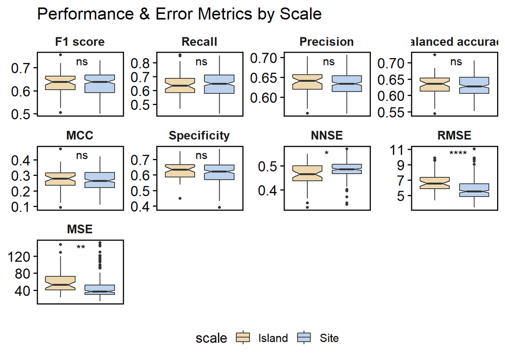

```r
# # For an evaluator "recall" on a data frame 'result_summary_island'
# # (assuming tme is a predefined ggplot theme you want to apply)
# island_heatmap_ba <- make_heatmap_plot(data = result_summary_island,
#                                            eval_col = "balanced_accuracy",
#                                            train_col = "train_layer_name",
#                                            test_col = "test_layer_name",
#                                            x_lab = "Added layer",
#                                            y_lab = "Predicted layer",
#                                            fill_lab = "Balanced \naccuracy",
#                                            extra_theme = tme)
#
# island_heatmap_f1 <- make_heatmap_plot(data = result_summary_island,
#                                        eval_col = "f1_score",
#                                        train_col = "train_layer_name",
#                                        test_col = "test_layer_name",
#                                        x_lab = "Added layer",
#                                        y_lab = "Predicted layer",
#                                        fill_lab = "F1 score",
#                                        extra_theme = tme)
#
# island_heatmap_recall <- make_heatmap_plot(data = result_summary_island,
#                                            eval_col = "recall",
#                                            train_col = "train_layer_name",
#                                            test_col = "test_layer_name",
#                                            x_lab = "Added layer",
#                                            y_lab = "Predicted layer",
#                                            fill_lab = "Recall",
#                                            extra_theme = tme)
#
# island_heatmap_precision <- make_heatmap_plot(data = result_summary_island,
#                                            eval_col = "precision",
#                                            train_col = "train_layer_name",
#                                            test_col = "test_layer_name",
#                                            x_lab = "Added layer",
#                                            y_lab = "Predicted layer",
#                                            fill_lab = "Precision",
#                                            extra_theme = tme)
#
# island_heatmap_specificity <- make_heatmap_plot(data = result_summary_island,
#                                               eval_col = "specificity",
#                                               train_col = "train_layer_name",
#                                               test_col = "test_layer_name",
#                                               x_lab = "Added layer",
#                                               y_lab = "Predicted layer",
#                                               fill_lab = "Specificity",
#                                               extra_theme = tme)
#
# p1 <- island_heatmap_f1 +
#   theme(legend.position = "none",
#         axis.title.y = element_blank(),
#         plot.margin = unit(c(0.5, 0.5, 0.1, 0.3), "cm"))
#
# p2 <- island_heatmap_ba +
#   theme(legend.position = "none",
#         axis.title.y = element_blank(),
#         plot.margin = unit(c(0.5, 0.5, 0.1, 0.3), "cm"))
#
# p3 <- island_heatmap_recall +
#   theme(legend.position = "none",
#         axis.title.y = element_blank(),
#         plot.margin = unit(c(0.5, 0.5, 0.1, 0.3), "cm"))
#
# p4 <- island_heatmap_precision +
#   theme(legend.position = "none",
#         axis.title.y = element_blank(),
#         plot.margin = unit(c(0.5, 0.5, 0.1, 0.3), "cm"))
#
# p5 <- island_heatmap_specificity +
#   theme(legend.position = "none",
#         axis.title.y = element_blank(),
#         plot.margin = unit(c(0.5, 0.5, 0.1, 0.3), "cm"))
#
# combined_plots <- arrangeGrob(
#   p1, p2, p3, p4, p5,
#   ncol = 3,
#   nrow = 2
# )
# combined_with_axes <- arrangeGrob(
#   combined_plots,
#   #bottom = textGrob("F1 score", gp = gpar(fontsize = 14, fontface = "bold"), vjust = -1.5),
#   left   = textGrob("Predicted location", rot = 90, gp = gpar(fontsize = 14, fontface = "bold"))
# )
#
# final_plot <- grid.arrange(
#   combined_with_axes,
#   ncol = 3,
#   widths = c(2, 0.3, 0.3)
# )
# ---- compare scales ----
# # # make a long list
# df1_labeled <- result_summary_site %>%
#   mutate(scale = "Site")
#
# df2_labeled <- result_summary_island %>%
#   mutate(scale = "Island")
#
# df_combined <- bind_rows(df1_labeled, df2_labeled)
#
# df_long <- df_combined %>%
#   pivot_longer(
#     cols = c("f1_score", "recall", "precision", "balanced_accuracy", "mcc", "specificity", "rmse"),
#     names_to = "metric",
#     values_to = "value"
#   )
# #
# metrics <- c("f1_score", "recall", "precision", "balanced_accuracy", "mcc", "specificity", "rmse")
# #
# results <- lapply(metrics, function(metric) {
#   test_normality_site <- shapiro.test(result_summary_site[[metric]])$p.value
#   test_normality_island <- shapiro.test(result_summary_island[[metric]])$p.value
#
#   if (test_normality_site > 0.05 & test_normality_island > 0.05) {
#     test <- t.test(result_summary_site[[metric]], result_summary_island[[metric]], var.equal = FALSE)
#   } else {
#     test <- t.test(result_summary_site[[metric]], result_summary_island[[metric]])
#   }
#
#   data.frame(
#     Metric = metric,
#     Test = ifelse(test_normality_site > 0.05 & test_normality_island > 0.05, "T-test", "T-test"),
#     P_value = test$p.value,
#     t_value  = test$statistic,   # extract the t‐value
#     df       = test$parameter   # degrees of freedom
#   )
# })
#
# results_df <- do.call(rbind, results)
# print(results_df)
# #
# # Define significance function
# get_pvalue_asterisks <- function(p) {
#   if (p < 0.001) return("***")  # Highly significant
#   else if (p < 0.01) return("**")  # Very significant
#   else if (p < 0.05) return("*")  # Significant
#   else return("ns")  # Not significant
# }
#
# stat_results <- lapply(metrics, function(metric) {
#   data_metric <- df_long %>% filter(metric == !!metric)  # Filter for the specific metric
#
#   test <- t.test(value ~ scale, data = data_metric)  # Perform t-test
#
#   p_value <- test$p.value
#   significance <- get_pvalue_asterisks(p_value)
#
#   data.frame(
#     metric = metric,
#     p_value = p_value,
#     significance = significance
#   )
# })
#
# stat_results_df <- do.call(rbind, stat_results)
#
# # Merge significance levels with the dataset
# df_long <- df_long %>%
#   left_join(stat_results_df, by = "metric")
#
# # Create the boxplot with significance annotations
# ggplot(df_long, aes(x = metric, y = value, fill = scale)) +
#   geom_boxplot(notch = TRUE, position = position_dodge(width = 0.8)) +
#   theme_minimal() +
#   labs(title = "Comparison of Performance", x = "Metric", y = "Value") +
#   scale_fill_manual(values = c("Site" = "lightsteelblue2", "Island" = "wheat2")) +  # Custom colors
#   scale_x_discrete(labels = c(
#     "f1_score" = "F1 score",
#     "recall" = "Recall",
#     "precision" = "Precision",
#     "balanced_accuracy" = "Balanced \naccuracy",
#     "mcc" = "MCC",
#     "specificity" = "Specificity"
#   )) +  # Properly formatted labels
#   stat_compare_means(aes(group = scale), method = "t.test", label = "p.signif",
#                      label.y = max(df_long$value, na.rm = TRUE) + 0.05,
#                      size = 5)  +
#   theme(legend.text = element_text(size = 14),
#         legend.title = element_text(size = 14), ) + tme

# 1. Combine + pivot (adding rmse & mse) and force the order you want:
df_long <- bind_rows(
  result_summary_site   %>% mutate(scale = "Site"),
  result_summary_island %>% mutate(scale = "Island")
) %>%
  pivot_longer(
    cols      = c("f1_score","recall","precision",
                  "balanced_accuracy","mcc","specificity", "nnse",
                  "rmse","mse"),
    names_to  = "metric",
    values_to = "value"
  ) %>%
  mutate(metric = factor(metric, levels = c(
    "f1_score","recall","precision","balanced_accuracy",
    "mcc","specificity", "nnse", "rmse","mse"
  )))

# 2. Pretty facet titles with units:
metric_labels <- c(
  f1_score          = "F1 score",
  recall            = "Recall",
  precision         = "Precision",
  balanced_accuracy = "Balanced accuracy",
  mcc               = "MCC",
  specificity       = "Specificity",
  rmse              = "RMSE",
  mse               = "MSE",
  nnse              = "NNSE"
)

# 3. Plot with free_y, custom labels, and centered stars at the top:
ggplot(df_long, aes(x = scale, y = value, fill = scale)) +
  geom_boxplot(
    notch        = TRUE,
    outlier.size = 1,
    position     = position_dodge(width = 0.75)
  ) +
  facet_wrap(
    ~ metric,
    scales   = "free_y",
    labeller = as_labeller(metric_labels),
    ncol     = 4
  ) +
  stat_compare_means(
    method    = "t.test",
    label     = "p.signif",
    # put label at the very top of each facet:
    label.y   = Inf,
    vjust     = 1.5,
    # center between the two boxes (position 1 & 2):
    label.x   = 1.45,
    tip.length= 0.01,
    size      = 4
  ) +
  scale_fill_manual(values = c("Site" = "lightsteelblue2",
                               "Island" = "wheat2")) +
  labs(
    title = "Performance & Error Metrics by Scale",
    x     = NULL,
    y     = NULL
  ) +
  theme_minimal(base_size = 14) +
  theme(
    strip.text      = element_text(face = "bold", size = 12),
    axis.text.x     = element_blank(),
    axis.ticks.x    = element_blank(),
    legend.position = "bottom"
  ) + tme
```

```r
# rmse separately

df_long <- bind_rows(
  result_summary_site   %>% mutate(scale = "Site"),
  result_summary_island %>% mutate(scale = "Island")
) %>%
  pivot_longer(
    cols      = c("rmse"),
    names_to  = "metric",
    values_to = "value"
  ) %>%
  mutate(metric = factor(metric, levels = c(
    "rmse"
  )))

# 2. Pretty facet titles with units:
metric_labels <- c(
  rmse              = "RMSE"

)

# 3. Plot with free_y, custom labels, and centered stars at the top:
rmse_scales <- ggplot(df_long, aes(x = scale, y = value, fill = scale)) +
  geom_boxplot(
    notch        = TRUE,
    outlier.size = 1,
    position     = position_dodge(width = 0.75)
  ) +
  facet_wrap(
    ~ metric,
    scales   = "free_y",
    labeller = as_labeller(metric_labels),
    ncol     = 4
  ) +
  stat_compare_means(
    method    = "t.test",
    label     = "p.signif",
    # put label at the very top of each facet:
    label.y   = Inf,
    vjust     = 1.5,
    # center between the two boxes (position 1 & 2):
    label.x   = 1.45,
    tip.length= 0.01,
    size      = 4
  ) +
  scale_fill_manual(values = c("Site" = "lightsteelblue2",
                               "Island" = "wheat2")) +
  labs(
    title = NULL,
    x     = NULL,
    y     = "RMSE"
  ) +
  theme_minimal(base_size = 14) +
  theme(
    #strip.text      = element_text(face = "bold", size = 12),
    axis.text.x     = element_blank(),
    axis.ticks.x    = element_blank(),
    legend.position = "bottom",
    strip.text = element_blank()
  ) + tme

# Base‐R PDF device
# pdf(
#   file   = "rmse_scales.pdf",
#   width  = 4,    # inches
#   height = 4,
#   family = "Helvetica"   # or another installed font
# )
# print(rmse_scales)
# dev.off()     # close the file


# nnse separately

df_long <- bind_rows(
  result_summary_site   %>% mutate(scale = "Site"),
  result_summary_island %>% mutate(scale = "Island")
) %>%
  pivot_longer(
    cols      = c("nnse"),
    names_to  = "metric",
    values_to = "value"
  ) %>%
  mutate(metric = factor(metric, levels = c(
    "nnse"
  )))

# 2. Pretty facet titles with units:
metric_labels <- c(
  nnse              = "NNSE"

)

# 3. Plot with free_y, custom labels, and centered stars at the top:
nnse_scales <- ggplot(df_long, aes(x = scale, y = value, fill = scale)) +
  geom_boxplot(
    notch        = TRUE,
    outlier.size = 1,
    position     = position_dodge(width = 0.75)
  ) +
  facet_wrap(
    ~ metric,
    scales   = "free_y",
    labeller = as_labeller(metric_labels),
    ncol     = 4
  ) +
  stat_compare_means(
    method    = "t.test",
    label     = "p.format",
    # put label at the very top of each facet:
    label.y   = Inf,
    vjust     = 1.5,
    # center between the two boxes (position 1 & 2):
    label.x   = 1.45,
    tip.length= 0.01,
    size      = 4
  ) +
  scale_fill_manual(values = c("Site" = "lightsteelblue2",
                               "Island" = "wheat2")) +
  labs(
    title = NULL,
    x     = NULL,
    y     = "NNSE"
  ) +
  theme_minimal(base_size = 14) +
  theme(
    #strip.text      = element_text(face = "bold", size = 12),
    axis.text.x     = element_blank(),
    axis.ticks.x    = element_blank(),
    legend.position = "bottom",
    strip.text = element_blank()
  ) + tme

# Base‐R PDF device
# pdf(
#   file   = "nnse_scales.pdf",
#   width  = 4,    # inches
#   height = 4,
#   family = "Helvetica"   # or another installed font
# )
# print(nnse_scales)
# dev.off()     # close the file

# stats

df_scales <- bind_rows(
  result_summary_site   %>% mutate(scale = "Site"),
  result_summary_island %>% mutate(scale = "Island"))

t_test_f1_scales <- t.test(f1_score ~ scale,
                    data       = df_scales,
                    var.equal  = FALSE)  # Welch’s test

# 3. Print the full test
print(t_test_f1_scales)
```

```
##
##  Welch Two Sample t-test
##
## data:  f1_score by scale
## t = -0.18162, df = 73.955, p-value = 0.8564
## alternative hypothesis: true difference in means between group Island and group Site is not equal to 0
## 95 percent confidence interval:
##  -0.01848316  0.01539521
## sample estimates:
## mean in group Island   mean in group Site
##            0.6279056            0.6294495
```

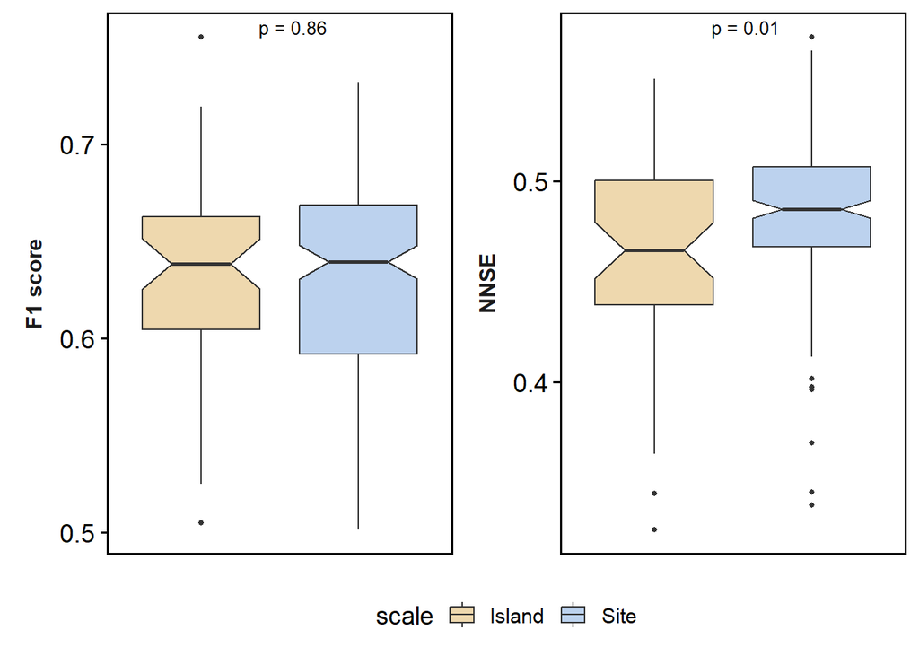

```r
# for paper

df_long <- bind_rows(
  result_summary_site   %>% mutate(scale = "Site"),
  result_summary_island %>% mutate(scale = "Island")
) %>%
  pivot_longer(
    cols      = c("f1_score", "nnse"),
    names_to  = "metric",
    values_to = "value"
  ) %>%
  mutate(metric = factor(metric, levels = c(
    "f1_score", "nnse"
  )))

# 2. Pretty facet titles with units:
metric_labels <- c(
  f1_score          = "F1 score",
  nnse              = "NNSE"

)

# make sure your metric_labels is something like
# metric_labels <- c(f1 = "F1 score", rmse = "RMSE")

nnse_f1_scales <- ggplot(df_long, aes(x = scale, y = value, fill = scale)) +
  geom_boxplot(
    notch        = TRUE,
    outlier.size = 1,
    position     = position_dodge(width = 0.75)
  ) +
  facet_wrap(
    ~ metric,
    scales        = "free_y",
    labeller      = as_labeller(metric_labels),
    ncol          = 4,
    switch        = "y"             # move the strip to the left side
  ) +
  stat_compare_means(
    method         = "t.test",
    label          = "p.format",    # print the full p‐value
    p.format.args  = list(
      digits     = 2,               # two digits after decimal
      scientific = TRUE             # use e-notation for small p’s
    ),
    label.y        = Inf,
    vjust          = 1.5,
    label.x        = 1.45,
    tip.length     = 0.01,
    size           = 3.5              # adjust this for font size
  ) +
  scale_fill_manual(values = c("Site"   = "lightsteelblue2",
                               "Island" = "wheat2")) +
  labs(
    x = NULL,
    y = NULL                       # we’ll rely on the left‐side strips as “y‐titles”
  ) +
  theme_minimal(base_size = 14) +
  theme(
    strip.placement       = "outside",           # draw strips outside the plot panel
    strip.text.y.left     = element_text(
      angle = 90,          # horizontal text
      face  = "bold",
      size  = 12
    ),
    axis.text.x           = element_blank(),
    axis.ticks.x          = element_blank(),
    legend.position       = "bottom"
  ) + tme
nnse_f1_scales
```

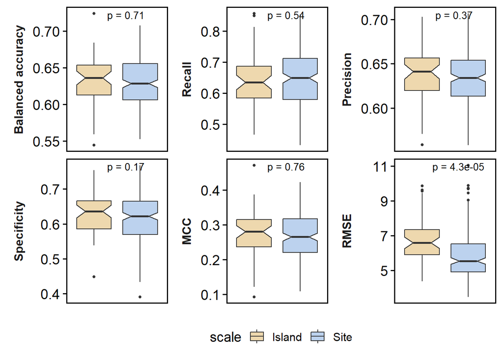

```r
# Base‐R PDF device
# pdf(
#   file   = "scales_fig2.pdf",
#   width  = 7,    # inches
#   height = 4,
#   family = "Helvetica"   # or another installed font
# )
# print(nnse_f1_scales)
# dev.off()     # close the file

# supp figure S1

df_long <- bind_rows(
  result_summary_site   %>% mutate(scale = "Site"),
  result_summary_island %>% mutate(scale = "Island")
) %>%
  pivot_longer(
    cols      = c("balanced_accuracy", "recall", "precision", "specificity", "mcc", "rmse"),
    names_to  = "metric",
    values_to = "value"
  ) %>%
  mutate(metric = factor(metric, levels = c(
    "balanced_accuracy", "recall", "precision", "specificity", "mcc", "rmse"
  )))

# 2. Pretty facet titles with units:
metric_labels <- c(
  balanced_accuracy = "Balanced accuracy",
  recall            = "Recall",
  precision         = "Precision",
  specificity       = "Specificity",
  mcc               = "MCC",
  rmse              = "RMSE"

)


s1_scales <- ggplot(df_long, aes(x = scale, y = value, fill = scale)) +
  geom_boxplot(
    notch        = TRUE,
    outlier.size = 1,
    position     = position_dodge(width = 0.75)
  ) +
  facet_wrap(
    ~ metric,
    scales        = "free_y",
    labeller      = as_labeller(metric_labels),
    ncol          = 3,
    switch        = "y"             # move the strip to the left side
  ) +
  stat_compare_means(
    method         = "t.test",
    label          = "p.format",    # print the full p‐value
    p.format.args  = list(
      digits     = 2,               # two digits after decimal
      scientific = TRUE             # use e-notation for small p’s
    ),
    label.y        = Inf,
    vjust          = 1.5,
    label.x        = 1.45,
    tip.length     = 0.01,
    size           = 3.5              # adjust this for font size
  ) +
  scale_fill_manual(values = c("Site"   = "lightsteelblue2",
                               "Island" = "wheat2")) +
  labs(
    x = NULL,
    y = NULL                       # we’ll rely on the left‐side strips as “y‐titles”
  ) +
  theme_minimal(base_size = 14) +
  theme(
    strip.placement       = "outside",           # draw strips outside the plot panel
    strip.text.y.left     = element_text(
      angle = 90,
      face  = "bold",
      size  = 12
    ),
    axis.text.x           = element_blank(),
    axis.ticks.x          = element_blank(),
    legend.position       = "bottom"
  ) + tme
s1_scales
```

```r
# Base‐R PDF device
# pdf(
#   file   = "s1_scales.pdf",
#   width  = 8,    # inches
#   height = 5,
#   family = "Helvetica"   # or another installed font
# )
# print(s1_scales)
# dev.off()     # close the file
```

[output not shown]

```r
# 4. Extract just the numbers you want
t_stat <- unname(t_test_f1_scales$statistic)
df_val <- unname(t_test_f1_scales$parameter)
p_val  <- t_test_f1_scales$p.value

data.frame(
  t_value = t_stat,
  df      = df_val,
  p_value = p_val
)
```

```
##      t_value       df  p_value
## 1 -0.1816185 73.95507 0.856379
```

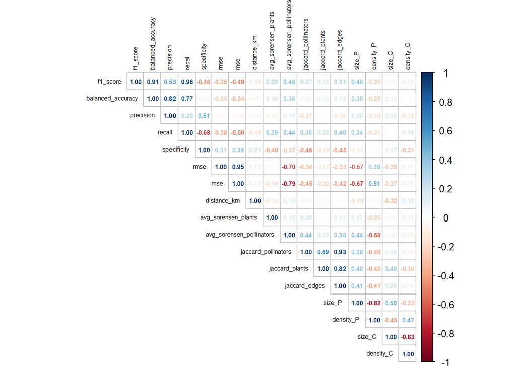

```r
# ---- variable importance ----
# analyze only one off-diagonal
df_off <- result_summary_island %>%
  # Keep rows where train_layer < test_layer (upper triangle) or on the diagonal
  filter(train_layer != test_layer)
# # subset relavant columns
# df_subset <- df_off %>% select(f1_score, distance_km, avg_sorensen_plants,    avg_sorensen_pollinators,   jaccard_pollinators,    jaccard_plants, jaccard_edges, size_P,  density_P, size_C,  density_C)
#
# ### ---- autocorrelation check ----
# # 2. Compute correlation matrix
# cor_mat <- cor(df_subset, use = "complete.obs")
# #write.csv(cor_mat, "island_autocorrelation.csv")
#
# # 3. Visualize (optional)
#
# corrplot(cor_mat,
#          method = "number",      # or "circle", "color", etc.
#          type = "upper",         # upper/lower/full
#          tl.cex = 0.7,           # text label size
#          number.cex = 0.7,       # correlation coefficient size
#          tl.col = "black"       # text label color (optional)
# )
#
# ### ---- linear regression ----
# # Fit a linear model predicting f1_score from all other numeric predictors
# lm_fit <- lm(f1_score ~ distance_km + avg_sorensen_plants +   avg_sorensen_pollinators +  jaccard_pollinators +   jaccard_plants +    jaccard_edges + size_P +    density_P + size_C +    density_C,
#              data = df_subset)
#
# summary(lm_fit)
#
# # Random Forest (only with numeric columns)
# rf_fit <- randomForest(f1_score ~ ., data = df_subset, importance = TRUE)
#
# # Check variable importance
# importance(rf_fit)
# varImpPlot(rf_fit)
#
# # Extract importance
# imp <- importance(rf_fit)
# # For regression: imp is a matrix with columns: %IncMSE, IncNodePurity
# # For classification: imp often has two columns per measure.
# # We'll assume %IncMSE and IncNodePurity are present.
#
# # Turn it into a data frame for easier plotting
# imp_df <- as.data.frame(imp)
# imp_df$f1_score <- rownames(imp_df)  # Keep variable names in a column
#
# # Example for %IncMSE
# ggplot(imp_df, aes(x = reorder(f1_score, `%IncMSE`), y = `%IncMSE`)) +
#   geom_bar(stat = "identity", fill = "lightsteelblue") +
#   coord_flip() +
#   labs(x = "F1 score",
#        y = "% Increase in MSE") +
#   theme_minimal() + tme +
#   scale_x_discrete(labels = function(x) lapply(strsplit(x, "_"), function(y) {
#     bquote(italic(.(paste(y, collapse = " "))))
#   })) +
#   scale_y_discrete(labels = function(x) lapply(strsplit(x, "_"), function(y) {
#     bquote(italic(.(paste(y, collapse = " "))))
#   }))

# subset relavant columns
df_subset_cor <- df_off %>% select(f1_score, balanced_accuracy, precision, recall, specificity, rmse, mse, distance_km, avg_sorensen_plants,    avg_sorensen_pollinators,   jaccard_pollinators,    jaccard_plants, jaccard_edges, size_P,  density_P, size_C,  density_C)

### ---- autocorrelation check ----
# 2. Compute correlation matrix
cor_mat <- cor(df_subset_cor, use = "complete.obs")
#write.csv(cor_mat, "island_autocorrelation.csv")

# 3. Visualize (optional)

corrplot(cor_mat,
         method = "number",      # or "circle", "color", etc.
         type = "upper",         # upper/lower/full
         tl.cex = 0.5,           # text label size
         number.cex = 0.5,       # correlation coefficient size
         tl.col = "black"       # text label color (optional)
)
```

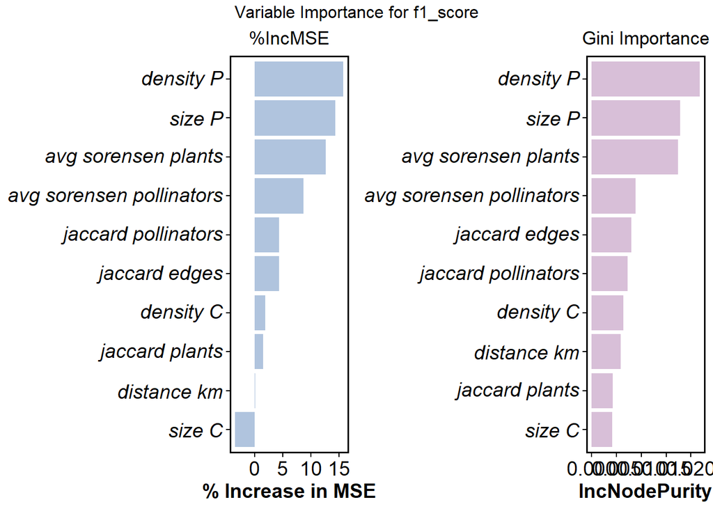

```r
# ### ---- linear regression ----
# # Fit a linear model predicting f1_score from all other numeric predictors
# lm_fit <- lm(f1_score ~ distance_km + avg_sorensen_plants +   avg_sorensen_pollinators +  jaccard_pollinators +   jaccard_plants +    jaccard_edges + size_P +    density_P + size_C +    density_C,
#              data = df_subset)
#
# summary(lm_fit)
#
# # Random Forest (only with numeric columns)
# rf_fit <- randomForest(f1_score ~ ., data = df_subset, importance = TRUE)
#
# # Check variable importance
# importance(rf_fit)
# varImpPlot(rf_fit)
#
# # Extract importance
# imp <- importance(rf_fit)
# # For regression: imp is a matrix with columns: %IncMSE, IncNodePurity
# # For classification: imp often has two columns per measure.
# # We'll assume %IncMSE and IncNodePurity are present.
#
# # Turn it into a data frame for easier plotting
# imp_df <- as.data.frame(imp)
# imp_df$f1_score <- rownames(imp_df)  # Keep variable names in a column
#
# # Example for %IncMSE
# ggplot(imp_df, aes(x = reorder(f1_score, `%IncMSE`), y = `%IncMSE`)) +
#   geom_bar(stat = "identity", fill = "lightsteelblue") +
#   coord_flip() +
#   labs(x = "F1 score",
#        y = "% Increase in MSE") +
#   theme_minimal() + tme +
#   scale_x_discrete(labels = function(x) lapply(strsplit(x, "_"), function(y) {
#     bquote(italic(.(paste(y, collapse = " "))))
#   })) +
#   scale_y_discrete(labels = function(x) lapply(strsplit(x, "_"), function(y) {
#     bquote(italic(.(paste(y, collapse = " "))))
#   }))

plot_rf_importance <- function(df_off, response_var, tme) {

  # Step 1: Select predictors + the response variable
  predictors <- c("distance_km", "avg_sorensen_plants", "avg_sorensen_pollinators",
                  "jaccard_pollinators", "jaccard_plants", "jaccard_edges",
                  "size_P", "density_P", "size_C", "density_C")

  df_subset <- df_off %>% select(all_of(c(response_var, predictors)))

  # Step 2: Fit Random Forest
  rf_fit <- randomForest(
    formula = as.formula(paste(response_var, "~ .")),
    data = df_subset,
    importance = TRUE
  )

  # Step 3: Extract and prepare importance data
  imp_df <- as.data.frame(importance(rf_fit))
  imp_df$variable <- rownames(imp_df)

  # Plot 1: %IncMSE
  plot_incMSE <- ggplot(imp_df, aes(x = reorder(variable, `%IncMSE`), y = `%IncMSE`)) +
    geom_bar(stat = "identity", fill = "lightsteelblue") +
    coord_flip() +
    labs(title = "%IncMSE", x = NULL, y = "% Increase in MSE") +
    theme_minimal() + tme +
    theme(plot.title = element_text(hjust = 0.5)) +
    scale_x_discrete(labels = function(x) lapply(strsplit(x, "_"), function(y) {
      bquote(italic(.(paste(y, collapse = " "))))
    }))

  # Plot 2: IncNodePurity (Gini importance)
  plot_gini <- ggplot(imp_df, aes(x = reorder(variable, IncNodePurity), y = IncNodePurity)) +
    geom_bar(stat = "identity", fill = "thistle") +
    coord_flip() +
    labs(title = "Gini Importance", x = NULL, y = "IncNodePurity") +
    theme_minimal() + tme +
    theme(plot.title = element_text(hjust = 0.5)) +
    scale_x_discrete(labels = function(x) lapply(strsplit(x, "_"), function(y) {
      bquote(italic(.(paste(y, collapse = " "))))
    }))

  # Combine both plots side by side
  combined_plot <- grid.arrange(
    plot_incMSE,
    plot_gini,
    ncol = 2,
    top = paste("Variable Importance for", response_var)
  )

  return(combined_plot)
}

plot_rf_importance(df_off, "f1_score", tme)
```

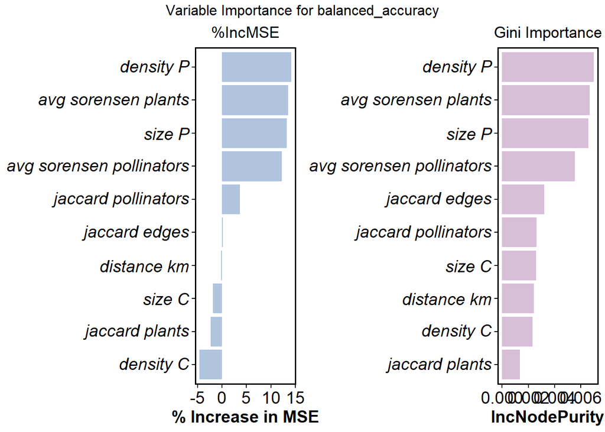

```r
plot_rf_importance(df_off, "balanced_accuracy", tme)
```

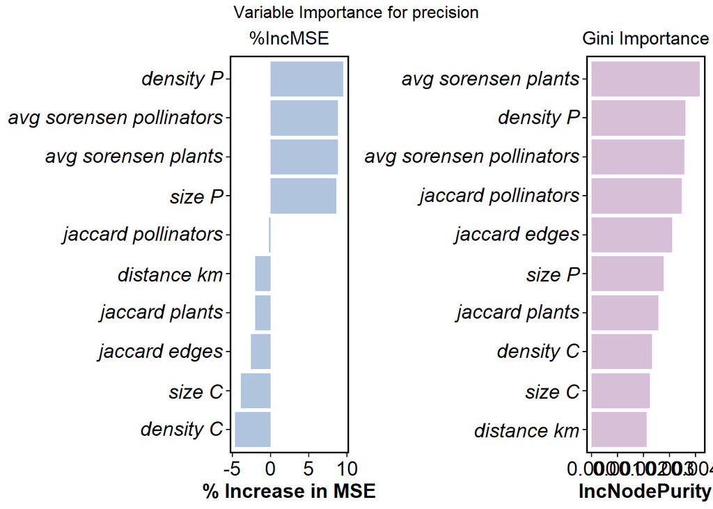

```r
plot_rf_importance(df_off, "precision", tme)
```

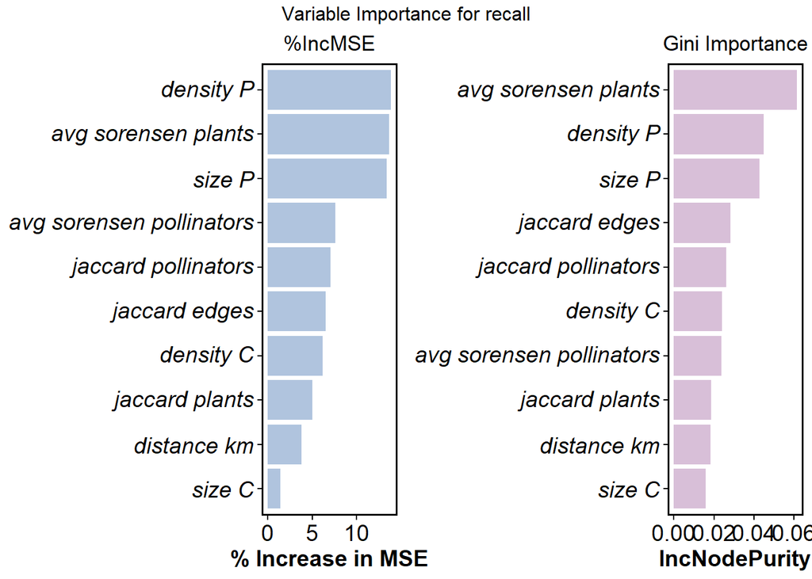

```r
plot_rf_importance(df_off, "recall", tme)
```

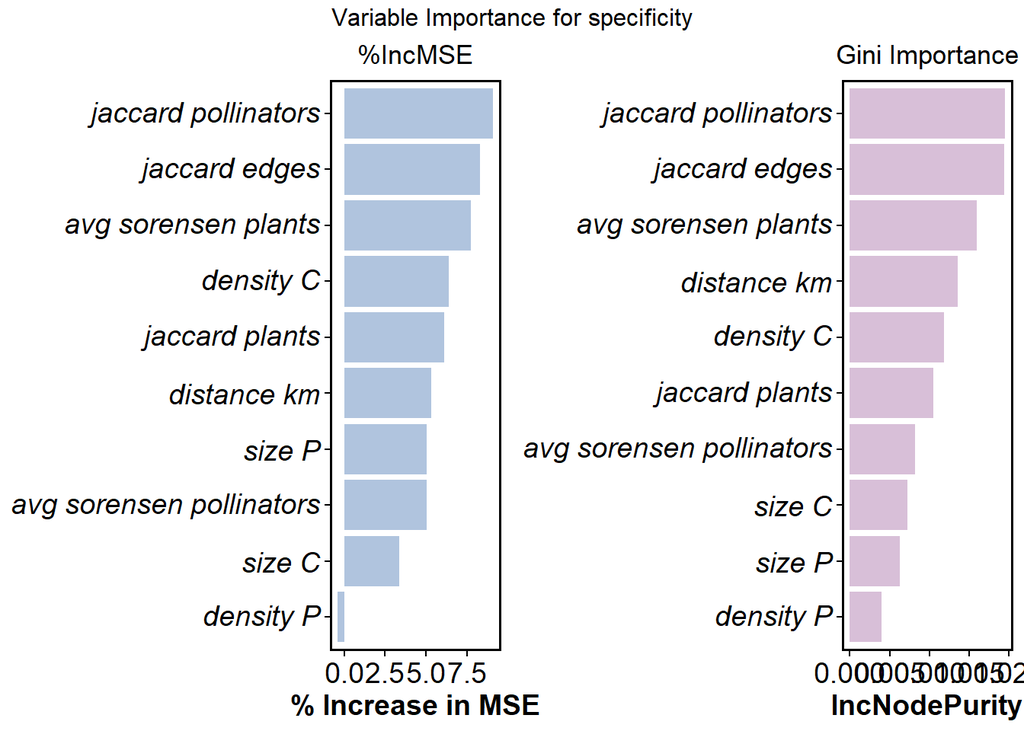

```r
plot_rf_importance(df_off, "specificity", tme)
```

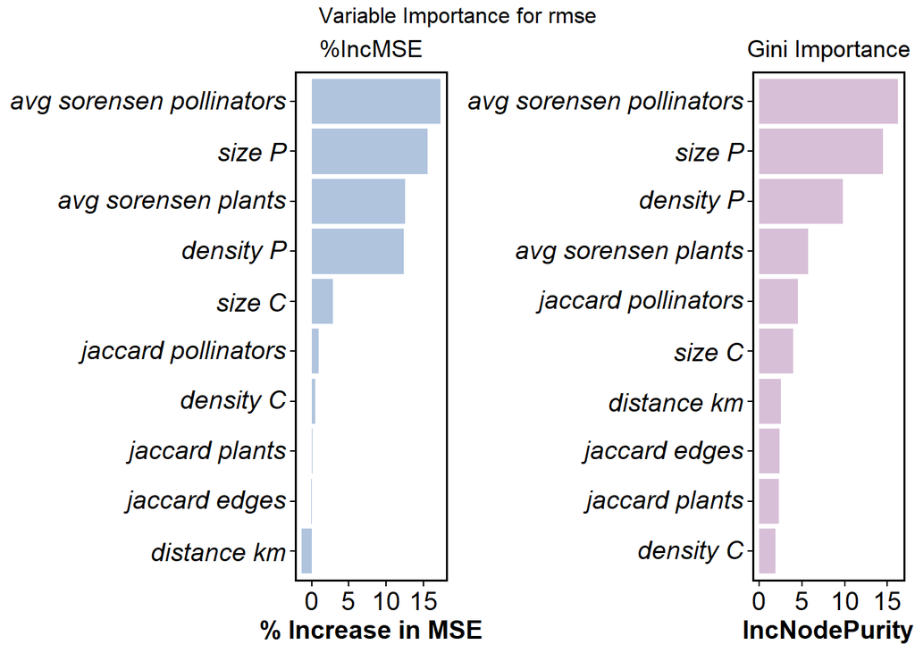

```r
plot_rf_importance(df_off, "rmse", tme)
```

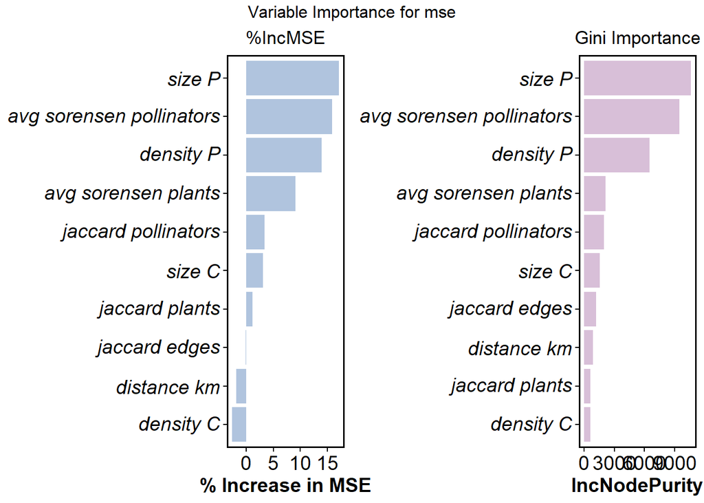

```r
plot_rf_importance(df_off, "mse", tme)
```

```r
### ---- table of variable importance ----

summarize_rf_importance_and_correlation <- function(df_off, response_var) {

  predictors <- c("distance_km", "avg_sorensen_plants", "avg_sorensen_pollinators",
                  "jaccard_pollinators", "jaccard_plants", "jaccard_edges",
                  "size_P", "density_P", "size_C", "density_C")

  df_subset <- df_off %>% select(all_of(c(response_var, predictors)))

  rf_fit <- randomForest(
    formula = as.formula(paste(response_var, "~ .")),
    data = df_subset,
    importance = TRUE
  )

  imp_df <- as.data.frame(importance(rf_fit)) %>%
    tibble::rownames_to_column("variable") %>%
    rename(IncMSE = `%IncMSE`, IncNodePurity = IncNodePurity)

  cor_results <- lapply(predictors, function(var) {
    test <- cor.test(df_subset[[var]], df_subset[[response_var]])
    data.frame(
      variable = var,
      correlation = test$estimate,
      p_value = test$p.value,
      significance = case_when(
        test$p.value < 0.001 ~ "***",
        test$p.value < 0.01 ~ "**",
        test$p.value < 0.05 ~ "*",
        test$p.value < 0.1 ~ ".",
        TRUE ~ ""
      )
    )
  }) %>% bind_rows()

  result_table <- left_join(imp_df, cor_results, by = "variable") %>%
    mutate(evaluator = response_var) %>%
    select(variable, evaluator, everything()) %>%
    arrange(desc(IncMSE))

  return(result_table)
}

# for this analysis i use only data from off-diagonals, to control for the issue of information addition (we have none in the diagonal)
df_offs <- result_summary_island %>% filter(train_layer != test_layer)
# Assuming your data is in df_off and you want to analyze "f1_score":
result_f1 <- summarize_rf_importance_and_correlation(df_offs, "f1_score")

# View the table
print(result_f1)
```

```
##                    variable evaluator     IncMSE IncNodePurity correlation
## 1                 density_P  f1_score 15.1715554   0.020722876 -0.25942233
## 2                    size_P  f1_score 14.2929818   0.018159562  0.40223557
## 3       avg_sorensen_plants  f1_score 12.2903284   0.017461542  0.29181665
## 4  avg_sorensen_pollinators  f1_score  9.4045592   0.009423474  0.43669373
## 5             jaccard_edges  f1_score  5.1349721   0.007496653  0.31240417
## 6            jaccard_plants  f1_score  4.1208806   0.004745905  0.18625234
## 7       jaccard_pollinators  f1_score  3.8755086   0.006968614  0.26750394
## 8                 density_C  f1_score  3.6186741   0.007555184  0.11764881
## 9               distance_km  f1_score  0.8461325   0.005529455 -0.15817727
## 10                   size_C  f1_score  0.5373547   0.004317553  0.05118855
##        p_value significance
## 1  0.097105445            .
## 2  0.008273759           **
## 3  0.060770870            .
## 4  0.003835214           **
## 5  0.043984621            *
## 6  0.237605019
## 7  0.086772611            .
## 8  0.458072520
## 9  0.317075299
## 10 0.747498583
```

```r
# several evaluators
evaluators <- c("f1_score", "balanced_accuracy", "precision", "recall", "specificity", "mcc", "rmse", "mse")

summary_all <- bind_rows(lapply(evaluators, function(ev) {
  summarize_rf_importance_and_correlation(df_offs, ev)
}))

# View combined table
print(summary_all)
```

```
##                    variable         evaluator     IncMSE IncNodePurity
## 1                    size_P          f1_score 14.6491548  1.835018e-02
## 2                 density_P          f1_score 14.5519193  1.960393e-02
## 3       avg_sorensen_plants          f1_score 13.1479788  1.757534e-02
## 4  avg_sorensen_pollinators          f1_score  9.7054960  8.956676e-03
## 5             jaccard_edges          f1_score  4.9157234  6.901377e-03
## 6                 density_C          f1_score  4.8150899  5.823148e-03
## 7            jaccard_plants          f1_score  3.9746279  4.886904e-03
## 8       jaccard_pollinators          f1_score  2.8702035  6.799350e-03
## 9               distance_km          f1_score  1.3615390  5.565748e-03
## 10                   size_C          f1_score  0.3317760  4.580854e-03
## 11                density_P balanced_accuracy 14.6765653  7.308203e-03
## 12      avg_sorensen_plants balanced_accuracy 14.2882078  7.145363e-03
## 13                   size_P balanced_accuracy 13.7120592  6.553071e-03
## 14 avg_sorensen_pollinators balanced_accuracy 10.6690351  4.618886e-03
```

[output cut: 147 more lines]

```r
# # for both scales
# summary_island <- summary_all %>% mutate(scale = "island")
#
# df_offs_site <- result_summary_site %>% filter(train_layer != test_layer)
#
# summary_site <- bind_rows(lapply(evaluators, function(ev) {
#   summarize_rf_importance_and_correlation(df_offs_site, ev)
# })) %>% mutate(scale = "site") # fix to have all variables

# summary_all_scales <- bind_rows(summary_island, summary_site)

# # for a nice table in html
# library(gt)
#
# styled_table <- summary_all %>%
#   mutate(correlation_display = ifelse(
#     !is.na(significance) & significance != "",
#     paste0("**", round(correlation, 3), "**"),  # Bold significant
#     round(correlation, 3)
#   )) %>%
#   gt() %>%
#   data_color(
#     columns = vars(correlation),
#     colors = scales::col_numeric(
#       palette = c("lightsteelblue", "black", "salmon"),
#       domain = c(-1, 1)
#     )
#   ) %>%
#   cols_label(
#     variable = "Variable",
#     evaluator = "Evaluator",
#     IncMSE = "%IncMSE",
#     IncNodePurity = "Gini Importance",
#     correlation = "Correlation",
#     p_value = "P-value",
#     significance = "Sig.",
#     scale = "Scale"
#   ) %>%
#   fmt_number(columns = vars(IncMSE, IncNodePurity, correlation, p_value), decimals = 3) %>%
#   tab_style(
#     style = cell_text(weight = "bold"),
#     locations = cells_body(
#       columns = vars(correlation),
#       rows = significance != ""
#     )
#   ) %>%
#   tab_options(
#     table.font.size = "small",
#     heading.title.font.size = 14,
#     data_row.padding = px(3)
#   )

library(knitr)
library(kableExtra)
summary_all %>%
  mutate(
    correlation_fmt = ifelse(
      significance != "",
      cell_spec(round(correlation, 3), bold = TRUE,
                color = ifelse(correlation > 0, "salmon", "lightsteelblue")),
      cell_spec(round(correlation, 3), color = ifelse(correlation > 0, "red", "blue"))
    ),
    p_value = round(p_value, 3),
    IncMSE = round(IncMSE, 3),
    IncNodePurity = round(IncNodePurity, 3)
  ) %>%
  select(variable, evaluator, IncMSE, IncNodePurity, correlation_fmt, p_value, significance) %>%
  kable("html", escape = FALSE, col.names = c(
    "Variable", "Evaluator", "%IncMSE", "Gini", "Correlation", "P-value", "Sig."
  )) %>%
  kable_styling(full_width = FALSE, position = "left")
```

Variable

Evaluator

%IncMSE

Gini

Correlation

P-value

Sig.

size_P

f1_score

14.649

0.018

0.402

0.008

density_P

f1_score

14.552

0.020

-0.259

0.097

.

avg_sorensen_plants

f1_score

13.148

0.018

0.292

0.061

.

avg_sorensen_pollinators

f1_score

9.705

0.009

0.437

0.004

jaccard_edges

f1_score

4.916

0.007

0.312

0.044

density_C

f1_score

4.815

0.006

0.118

0.458

jaccard_plants

f1_score

3.975

0.005

0.186

0.238

jaccard_pollinators

f1_score

2.870

0.007

0.268

0.087

.

distance_km

f1_score

1.362

0.006

-0.158

0.317

size_C

f1_score

0.332

0.005

0.051

0.747

density_P

balanced_accuracy

14.677

0.007

-0.254

0.104

avg_sorensen_plants

balanced_accuracy

14.288

0.007

0.181

0.252

size_P

balanced_accuracy

13.712

0.007

0.348

0.024

avg_sorensen_pollinators

balanced_accuracy

10.669

0.005

0.357

0.020

jaccard_pollinators

balanced_accuracy

1.695

0.003

0.092

0.563

jaccard_edges

balanced_accuracy

1.355

0.003

0.151

0.339

distance_km

balanced_accuracy

0.809

0.003

-0.071

0.653

jaccard_plants

balanced_accuracy

-1.712

0.001

0.126

0.428

size_C

balanced_accuracy

-2.422

0.002

0.133

0.400

density_C

balanced_accuracy

-5.532

0.002

-0.029

0.854

size_P

precision

8.886

0.003

0.204

0.195

avg_sorensen_plants

precision

8.705

0.004

-0.118

0.458

avg_sorensen_pollinators

precision

8.426

0.004

0.149

0.345

density_P

precision

8.381

0.003

-0.182

0.250

jaccard_pollinators

precision

0.118

0.003

-0.207

0.188

jaccard_plants

precision

-2.970

0.003

-0.012

0.939

distance_km

precision

-3.184

0.002

0.058

0.717

size_C

precision

-3.246

0.002

0.18

0.255

jaccard_edges

precision

-3.837

0.003

-0.158

0.319

density_C

precision

-5.097

0.002

-0.175

0.267

density_P

recall

14.712

0.049

-0.215

0.172

avg_sorensen_plants

recall

13.652

0.057

0.386

0.012

size_P

recall

12.599

0.043

0.345

0.025

avg_sorensen_pollinators

recall

7.773

0.021

0.435

0.004

density_C

recall

7.336

0.021

0.178

0.260

jaccard_edges

recall

5.668

0.025

0.399

0.009

jaccard_pollinators

recall

5.378

0.027

0.362

0.018

jaccard_plants

recall

4.992

0.021

0.216

0.170

distance_km

recall

2.942

0.021

-0.183

0.246

size_C

recall

0.734

0.014

-0.011

0.946

jaccard_pollinators

specificity

7.936

0.021

-0.465

0.002

avg_sorensen_plants

specificity

7.730

0.017

-0.399

0.009

jaccard_edges

specificity

7.027

0.018

-0.453

0.003

density_C

specificity

6.832

0.013

-0.314

0.043

jaccard_plants

specificity

6.023

0.010

-0.194

0.219

distance_km

specificity

5.084

0.015

0.206

0.192

size_P

specificity

4.012

0.007

-0.139

0.380

avg_sorensen_pollinators

specificity

2.390

0.007

-0.272

0.081

.

size_C

specificity

1.616

0.008

0.172

0.275

density_P

specificity

-0.416

0.004

0.043

0.786

density_P

mcc

13.400

0.033

-0.238

0.129

size_P

mcc

13.290

0.026

0.317

0.041

avg_sorensen_pollinators

mcc

12.244

0.026

0.353

0.022

avg_sorensen_plants

mcc

11.995

0.031

0.2

0.204

jaccard_pollinators

mcc

2.917

0.011

0.095

0.550

jaccard_edges

mcc

0.881

0.013

0.154

0.331

distance_km

mcc

-0.903

0.010

-0.07

0.658

size_C

mcc

-2.046

0.011

0.122

0.440

jaccard_plants

mcc

-2.138

0.008

0.127

0.424

density_C

mcc

-3.808

0.010

-0.03

0.850

avg_sorensen_pollinators

rmse

16.661

15.952

-0.699

0.000

***

size_P

rmse

13.792

14.107

-0.573

0.000

***

avg_sorensen_plants

rmse

12.946

6.057

0.026

0.868

density_P

rmse

12.067

10.948

0.392

0.010

size_C

rmse

2.397

3.831

-0.289

0.063

.

jaccard_edges

rmse

1.818

2.419

-0.33

0.033

jaccard_pollinators

rmse

1.196

4.604

-0.337

0.029

jaccard_plants

rmse

1.033

2.234

-0.167

0.292

density_C

rmse

0.704

1.945

0.106

0.506

distance_km

rmse

-1.021

2.589

0.117

0.459

size_P

mse

15.956

10861.285

-0.67

0.000

***

avg_sorensen_pollinators

mse

14.554

9408.508

-0.789

0.000

***

density_P

mse

14.288

6483.784

0.515

0.000

***

avg_sorensen_plants

mse

9.142

2418.209

-0.186

0.238

jaccard_pollinators

mse

3.526

2751.366

-0.449

0.003

size_C

mse

2.015

1066.626

-0.268

0.087

.

jaccard_plants

mse

0.545

739.618

-0.219

0.164

distance_km

mse

0.436

954.139

0.104

0.510

jaccard_edges

mse

0.313

1250.060

-0.418

0.006

density_C

mse

-2.639

698.931

0.088

0.580

```r
## ---- how many interactions were observed when adding information? ----
# here we check what's the proportion of links that were not observed with no layer addition but were observed and predicted correctly (to exist) when we add other layers

# 1. Denominator per train_layer & itr
denom_df <- df_removed %>%
  filter(test_layer == train_layer, original_links == 0) %>%
  distinct(train_layer, itr, node_to, node_from) %>%
  group_by(train_layer, itr) %>%
  summarise(denominator = n(), .groups = "drop")

# 2. Numerator per train_layer / test_layer / itr
num_df <- df_removed %>%
  filter(test_layer != train_layer,
         original_links > 0,
         predicted_prob_sigm > 0.6) %>%
  distinct(train_layer, test_layer, itr, node_to, node_from) %>%
  group_by(train_layer, test_layer, itr) %>%
  summarise(numerator = n(), .groups = "drop")

# 3. Compute per-itr proportions
prop_df <- num_df %>%
  left_join(denom_df, by = c("train_layer", "itr")) %>%
  filter(!is.na(denominator) & denominator > 0) %>%
  mutate(prop = numerator / denominator)

# 4. Average prop over itr for each layer‐combo
combo_df <- prop_df %>%
  group_by(train_layer, test_layer) %>%
  summarise(mean_prop = mean(prop, na.rm = TRUE), .groups = "drop")

# 5. Overall average across all train/test combos
overall_mean <- mean(combo_df$mean_prop, na.rm = TRUE)

# Inspect
combo_df
```

```
## # A tibble: 42 × 3
##    train_layer test_layer mean_prop
##          <dbl>      <dbl>     <dbl>
##  1           1          2     0.967
##  2           1          3     0.893
##  3           1          4     0.646
##  4           1          5     0.431
##  5           1          6     0.647
##  6           1          7     0.427
##  7           2          1     0.632
##  8           2          3     0.673
##  9           2          4     0.516
## 10           2          5     0.283
## # ℹ 32 more rows
```

```r
overall_mean
```

```
## [1] 0.6697181
```

```r
# how many interactions were observed when we added other layers

# Reuse the same denominator:
denom_df <- df %>%
  filter(test_layer == train_layer, original_links == 0) %>%
  distinct(train_layer, itr, node_to, node_from) %>%
  group_by(train_layer, itr) %>%
  summarise(denominator = n(), .groups = "drop")

# New numerator: absent in‐layer but present cross‐layer
num2_df <- df %>%
  filter(test_layer != train_layer,
         original_links > 0) %>%
  distinct(train_layer, test_layer, itr, node_to, node_from) %>%
  group_by(train_layer, test_layer, itr) %>%
  summarise(n_novel = n(), .groups = "drop")

# Compute per‐itr proportions
prop2_df <- num2_df %>%
  left_join(denom_df, by = c("train_layer", "itr")) %>%
  filter(!is.na(denominator) & denominator > 0) %>%
  mutate(prop_novel = n_novel / denominator)

# Average over itr for each train/test layer combo
combo2_df <- prop2_df %>%
  group_by(train_layer, test_layer) %>%
  summarise(mean_prop_novel = mean(prop_novel, na.rm = TRUE), .groups = "drop")

# Grand mean across all layer‐combos
overall_mean_novel <- mean(combo2_df$mean_prop_novel, na.rm = TRUE)

# Inspect results
combo2_df
```

```
## # A tibble: 42 × 3
##    train_layer test_layer mean_prop_novel
##          <dbl>      <dbl>           <dbl>
##  1           1          2          0.251
##  2           1          3          0.251
##  3           1          4          0.191
##  4           1          5          0.151
##  5           1          6          0.206
##  6           1          7          0.149
##  7           2          1          0.101
##  8           2          3          0.134
##  9           2          4          0.102
## 10           2          5          0.0812
## # ℹ 32 more rows
```

```r
overall_mean_novel
```

```
## [1] 0.2060432
```

```r
## ---- some stats ----
print(summary(result_summary_island))
```

```
##    emln_id.x   train_layer   test_layer       TP               FN
##  Min.   :60   Min.   :1    Min.   :1    Min.   : 5.120   Min.   :2.000
##  1st Qu.:60   1st Qu.:2    1st Qu.:2    1st Qu.: 6.480   1st Qu.:4.520
##  Median :60   Median :4    Median :4    Median : 9.560   Median :5.320
##  Mean   :60   Mean   :4    Mean   :4    Mean   : 9.471   Mean   :5.243
##  3rd Qu.:60   3rd Qu.:6    3rd Qu.:6    3rd Qu.:12.000   3rd Qu.:6.000
##  Max.   :60   Max.   :7    Max.   :7    Max.   :13.720   Max.   :7.860
##        TN               FP        specificity       precision
##  Min.   : 6.200   Min.   :3.08   Min.   :0.4486   Min.   :0.5587
##  1st Qu.: 7.600   1st Qu.:4.12   1st Qu.:0.5853   1st Qu.:0.6197
##  Median : 8.820   Median :5.28   Median :0.6358   Median :0.6412
##  Mean   : 9.235   Mean   :5.48   Mean   :0.6302   Mean   :0.6377
##  3rd Qu.:10.680   3rd Qu.:6.48   3rd Qu.:0.6663   3rd Qu.:0.6565
##  Max.   :12.700   Max.   :8.34   Max.   :0.7543   Max.   :0.7029
##      recall          f1_score      balanced_accuracy      mcc
##  Min.   :0.4655   Min.   :0.5048   Min.   :0.5445    Min.   :0.09259
##  1st Qu.:0.5836   1st Qu.:0.6045   1st Qu.:0.6127    1st Qu.:0.23601
##  Median :0.6347   Median :0.6383   Median :0.6364    Median :0.28046
##  Mean   :0.6352   Mean   :0.6279   Mean   :0.6327    Mean   :0.27239
##  3rd Qu.:0.6863   3rd Qu.:0.6626   3rd Qu.:0.6537    3rd Qu.:0.31528
##  Max.   :0.8571   Max.   :0.7552   Max.   :0.7243    Max.   :0.47195
##       mse              rmse            nse               nnse
##  Min.   : 23.11   Min.   :4.370   Min.   :-8.8247   Min.   :0.3266
##  1st Qu.: 40.32   1st Qu.:5.901   1st Qu.:-1.4205   1st Qu.:0.4385
##  Median : 52.70   Median :6.579   Median :-0.6375   Median :0.4657
##  Mean   : 61.57   Mean   :6.755   Mean   :-1.3334   Mean   :0.4626
##  3rd Qu.: 72.34   3rd Qu.:7.335   3rd Qu.:-0.2172   3rd Qu.:0.5001
##  Max.   :147.11   Max.   :9.863   Max.   : 0.1525   Max.   :0.5509
##  layer_comparison     emln_id.y      nrow_A       ncol_A          size_A
##  Length:49          Min.   :60   Min.   :35   Min.   : 8.00   Min.   :304.0
##  Class :character   1st Qu.:60   1st Qu.:35   1st Qu.:10.00   1st Qu.:350.0
##  Mode  :character   Median :60   Median :38   Median :13.00   Median :455.0
##                     Mean   :60   Mean   :40   Mean   :12.43   Mean   :505.9
##                     3rd Qu.:60   3rd Qu.:45   3rd Qu.:15.00   3rd Qu.:702.0
##                     Max.   :60   Max.   :54   Max.   :18.00   Max.   :810.0
##    density_A          nrow_P       ncol_P          size_P        density_P
##  Min.   :0.1185   Min.   :35   Min.   : 8.00   Min.   :304.0   Min.   :0.1185
##  1st Qu.:0.1281   1st Qu.:35   1st Qu.:10.00   1st Qu.:350.0   1st Qu.:0.1281
##  Median :0.1582   Median :38   Median :13.00   Median :455.0   Median :0.1582
##  Mean   :0.1601   Mean   :40   Mean   :12.43   Mean   :505.9   Mean   :0.1601
```

[output cut: 15 more lines]

```
##  Max.   :1.00000     Max.   :1.00000   Max.   :1.00000   Max.   :0.3569
##  avg_sorensen_pollinators train_layer_name   test_layer_name
##  Min.   :0.2520           Length:49          Length:49
##  1st Qu.:0.3022           Class :character   Class :character
##  Median :0.3205           Mode  :character   Mode  :character
##  Mean   :0.3290
##  3rd Qu.:0.3658
##  Max.   :0.3966
##  avg_distance_m   avg_distance_km   distance_km
##  Min.   :     0   Min.   :  0.00   Min.   :  0.00
##  1st Qu.: 80113   1st Qu.: 80.11   1st Qu.: 80.11
##  Median :190475   Median :190.47   Median :190.47
##  Mean   :208170   Mean   :208.17   Mean   :208.17
##  3rd Qu.:337056   3rd Qu.:337.06   3rd Qu.:337.06
##  Max.   :455677   Max.   :455.68   Max.   :455.68
```

```r
print(summary(result_summary_site))
```

```
##     emln_id    train_layer     test_layer         TP               FN
##  Min.   :60   Min.   : 1.0   Min.   : 1.0   Min.   : 4.940   Min.   :1.760
##  1st Qu.:60   1st Qu.: 4.0   1st Qu.: 4.0   1st Qu.: 6.780   1st Qu.:3.720
##  Median :60   Median : 7.5   Median : 7.5   Median : 8.340   Median :4.930
##  Mean   :60   Mean   : 7.5   Mean   : 7.5   Mean   : 8.702   Mean   :4.727
##  3rd Qu.:60   3rd Qu.:11.0   3rd Qu.:11.0   3rd Qu.:10.330   3rd Qu.:5.745
##  Max.   :60   Max.   :14.0   Max.   :14.0   Max.   :14.380   Max.   :7.700
##
##        TN               FP         specificity       precision
##  Min.   : 4.540   Min.   :2.640   Min.   :0.3908   Min.   :0.5584
##  1st Qu.: 6.880   1st Qu.:3.915   1st Qu.:0.5691   1st Qu.:0.6137
##  Median : 7.900   Median :4.820   Median :0.6225   Median :0.6343
##  Mean   : 8.276   Mean   :5.153   Mean   :0.6170   Mean   :0.6334
##  3rd Qu.: 9.435   3rd Qu.:6.400   3rd Qu.:0.6648   3rd Qu.:0.6537
##  Max.   :13.220   Max.   :8.980   Max.   :0.7686   Max.   :0.7067
##
##      recall          f1_score      balanced_accuracy      mcc
##  Min.   :0.4323   Min.   :0.5013   Min.   :0.5527    Min.   :0.1086
##  1st Qu.:0.5790   1st Qu.:0.5919   1st Qu.:0.6063    1st Qu.:0.2207
##  Median :0.6488   Median :0.6392   Median :0.6284    Median :0.2651
##  Mean   :0.6442   Mean   :0.6294   Mean   :0.6306    Mean   :0.2690
##  3rd Qu.:0.7124   3rd Qu.:0.6686   3rd Qu.:0.6555    3rd Qu.:0.3175
##  Max.   :0.8529   Max.   :0.7318   Max.   :0.7079    Max.   :0.4233
##
##       mse              rmse             nse                nnse
##  Min.   : 13.88   Min.   : 3.470   Min.   :-14.9914   Min.   :0.3389
##  1st Qu.: 29.65   1st Qu.: 4.899   1st Qu.: -0.9675   1st Qu.:0.4671
##  Median : 37.38   Median : 5.534   Median : -0.3475   Median :0.4860
##  Mean   : 46.10   Mean   : 5.802   Mean   : -0.9198   Mean   :0.4828
##  3rd Qu.: 52.30   3rd Qu.: 6.526   3rd Qu.: -0.1296   3rd Qu.:0.5070
##  Max.   :151.85   Max.   :11.053   Max.   :  0.1148   Max.   :0.5715
##
##  train_layer_name   test_layer_name      distance_m        distance_km
##  Length:196         Length:196         Min.   :    67.4   Min.   :  0.00
##  Class :character   Class :character   1st Qu.: 98897.3   1st Qu.: 80.12
##  Mode  :character   Mode  :character   Median :200279.0   Median :190.51
##                                        Mean   :224194.8   Mean   :208.18
##                                        3rd Qu.:339335.1   3rd Qu.:337.17
##                                        Max.   :455736.7   Max.   :455.74
##                                        NA's   :14
```

```r
Sahara <- result_summary_island %>% filter(test_layer_name == "Western Sahara")
summary(Sahara)
```

```
##    emln_id.x   train_layer    test_layer       TP             FN
##  Min.   :60   Min.   :1.0   Min.   :5    Min.   :5.12   Min.   :4.08
##  1st Qu.:60   1st Qu.:2.5   1st Qu.:5    1st Qu.:5.33   1st Qu.:5.04
##  Median :60   Median :4.0   Median :5    Median :5.56   Median :5.44
##  Mean   :60   Mean   :4.0   Mean   :5    Mean   :5.74   Mean   :5.26
##  3rd Qu.:60   3rd Qu.:5.5   3rd Qu.:5    3rd Qu.:5.96   3rd Qu.:5.67
##  Max.   :60   Max.   :7.0   Max.   :5    Max.   :6.92   Max.   :5.88
##        TN              FP         specificity       precision
##  Min.   :6.200   Min.   :3.400   Min.   :0.5636   Min.   :0.5587
##  1st Qu.:6.420   1st Qu.:3.650   1st Qu.:0.5836   1st Qu.:0.5740
##  Median :6.880   Median :4.120   Median :0.6255   Median :0.5957
##  Mean   :6.889   Mean   :4.111   Mean   :0.6262   Mean   :0.5901
##  3rd Qu.:7.350   3rd Qu.:4.580   3rd Qu.:0.6682   3rd Qu.:0.6038
##  Max.   :7.600   Max.   :4.800   Max.   :0.6909   Max.   :0.6205
##      recall          f1_score      balanced_accuracy      mcc
##  Min.   :0.4655   Min.   :0.5048   Min.   :0.5445    Min.   :0.09259
##  1st Qu.:0.4845   1st Qu.:0.5255   1st Qu.:0.5595    1st Qu.:0.12310
##  Median :0.5055   Median :0.5396   Median :0.5809    Median :0.16816
##  Mean   :0.5218   Mean   :0.5446   Mean   :0.5740    Mean   :0.15278
##  3rd Qu.:0.5418   3rd Qu.:0.5554   3rd Qu.:0.5886    3rd Qu.:0.18332
##  Max.   :0.6291   Max.   :0.6061   Max.   :0.5964    Max.   :0.19587
##       mse              rmse            nse               nnse
##  Min.   : 60.57   Min.   :6.573   Min.   :-5.0837   Min.   :0.4363
##  1st Qu.: 69.04   1st Qu.:7.042   1st Qu.:-2.8820   1st Qu.:0.4455
##  Median : 85.32   Median :8.063   Median :-1.2258   Median :0.4831
##  Mean   : 81.88   Mean   :7.777   Mean   :-2.0326   Mean   :0.4741
##  3rd Qu.: 91.44   3rd Qu.:8.133   3rd Qu.:-0.7476   3rd Qu.:0.4995
##  Max.   :106.31   Max.   :9.453   Max.   :-0.6592   Max.   :0.5090
##  layer_comparison     emln_id.y      nrow_A         ncol_A          size_A
##  Length:7           Min.   :60   Min.   :35.0   Min.   : 8.00   Min.   :304.0
##  Class :character   1st Qu.:60   1st Qu.:35.0   1st Qu.:10.00   1st Qu.:350.0
##  Mode  :character   Median :60   Median :38.0   Median :13.00   Median :455.0
##                     Mean   :60   Mean   :40.0   Mean   :12.43   Mean   :505.9
##                     3rd Qu.:60   3rd Qu.:41.5   3rd Qu.:14.00   3rd Qu.:636.0
##                     Max.   :60   Max.   :54.0   Max.   :18.00   Max.   :810.0
##    density_A          nrow_P       ncol_P       size_P      density_P
##  Min.   :0.1185   Min.   :35   Min.   :10   Min.   :350   Min.   :0.1657
##  1st Qu.:0.1324   1st Qu.:35   1st Qu.:10   1st Qu.:350   1st Qu.:0.1657
##  Median :0.1582   Median :35   Median :10   Median :350   Median :0.1657
##  Mean   :0.1601   Mean   :35   Mean   :10   Mean   :350   Mean   :0.1657
```

[output cut: 15 more lines]

```
##  Max.   :1.00000     Max.   :1.0000   Max.   :1.00000   Max.   :0.3221
##  avg_sorensen_pollinators train_layer_name   test_layer_name
##  Min.   :0.3205           Length:7           Length:7
##  1st Qu.:0.3205           Class :character   Class :character
##  Median :0.3205           Mode  :character   Mode  :character
##  Mean   :0.3205
##  3rd Qu.:0.3205
##  Max.   :0.3205
##  avg_distance_m   avg_distance_km  distance_km
##  Min.   :     0   Min.   :  0.0   Min.   :  0.0
##  1st Qu.:274765   1st Qu.:274.8   1st Qu.:274.8
##  Median :339382   Median :339.4   Median :339.4
##  Mean   :300769   Mean   :300.8   Mean   :300.8
##  3rd Qu.:389552   3rd Qu.:389.6   3rd Qu.:389.6
##  Max.   :437371   Max.   :437.4   Max.   :437.4
```

```r
no_Sahara <- result_summary_island %>% filter(test_layer_name != "Western Sahara")
summary(no_Sahara)
```

```
##    emln_id.x   train_layer   test_layer          TP              FN
##  Min.   :60   Min.   :1    Min.   :1.000   Min.   : 5.56   Min.   :2.000
##  1st Qu.:60   1st Qu.:2    1st Qu.:2.000   1st Qu.: 8.83   1st Qu.:4.475
##  Median :60   Median :4    Median :3.500   Median : 9.75   Median :5.320
##  Mean   :60   Mean   :4    Mean   :3.833   Mean   :10.09   Mean   :5.240
##  3rd Qu.:60   3rd Qu.:6    3rd Qu.:6.000   3rd Qu.:12.06   3rd Qu.:6.135
##  Max.   :60   Max.   :7    Max.   :7.000   Max.   :13.72   Max.   :7.860
##        TN               FP         specificity       precision
##  Min.   : 6.280   Min.   :3.080   Min.   :0.4486   Min.   :0.5878
##  1st Qu.: 8.035   1st Qu.:5.010   1st Qu.:0.5933   1st Qu.:0.6365
##  Median : 9.050   Median :6.050   Median :0.6358   Median :0.6453
##  Mean   : 9.626   Mean   :5.708   Mean   :0.6308   Mean   :0.6456
##  3rd Qu.:11.175   3rd Qu.:6.770   3rd Qu.:0.6645   3rd Qu.:0.6592
##  Max.   :12.700   Max.   :8.340   Max.   :0.7543   Max.   :0.7029
##      recall          f1_score      balanced_accuracy      mcc
##  Min.   :0.5055   Min.   :0.5621   Min.   :0.5887    Min.   :0.1806
##  1st Qu.:0.5895   1st Qu.:0.6090   1st Qu.:0.6243    1st Qu.:0.2531
##  Median :0.6416   Median :0.6416   Median :0.6397    Median :0.2845
##  Mean   :0.6541   Mean   :0.6418   Mean   :0.6425    Mean   :0.2923
##  3rd Qu.:0.6925   3rd Qu.:0.6626   3rd Qu.:0.6558    3rd Qu.:0.3184
##  Max.   :0.8571   Max.   :0.7552   Max.   :0.7243    Max.   :0.4720
##       mse              rmse            nse               nnse
##  Min.   : 23.11   Min.   :4.370   Min.   :-8.8247   Min.   :0.3266
##  1st Qu.: 39.69   1st Qu.:5.871   1st Qu.:-1.3750   1st Qu.:0.4367
##  Median : 48.79   Median :6.372   Median :-0.4959   Median :0.4653
##  Mean   : 58.18   Mean   :6.585   Mean   :-1.2169   Mean   :0.4607
##  3rd Qu.: 62.77   3rd Qu.:7.304   3rd Qu.:-0.1638   3rd Qu.:0.5000
##  Max.   :147.11   Max.   :9.863   Max.   : 0.1525   Max.   :0.5509
##  layer_comparison     emln_id.y      nrow_A       ncol_A          size_A
##  Length:42          Min.   :60   Min.   :35   Min.   : 8.00   Min.   :304.0
##  Class :character   1st Qu.:60   1st Qu.:35   1st Qu.:10.00   1st Qu.:350.0
##  Mode  :character   Median :60   Median :38   Median :13.00   Median :455.0
##                     Mean   :60   Mean   :40   Mean   :12.43   Mean   :505.9
##                     3rd Qu.:60   3rd Qu.:45   3rd Qu.:15.00   3rd Qu.:702.0
##                     Max.   :60   Max.   :54   Max.   :18.00   Max.   :810.0
##    density_A          nrow_P          ncol_P          size_P
##  Min.   :0.1185   Min.   :35.00   Min.   : 8.00   Min.   :304.0
##  1st Qu.:0.1281   1st Qu.:35.00   1st Qu.:10.00   1st Qu.:350.0
##  Median :0.1582   Median :38.00   Median :13.00   Median :512.5
##  Mean   :0.1601   Mean   :40.83   Mean   :12.83   Mean   :531.8
```

[output cut: 22 more lines]

```
##  Max.   :1.00000   Max.   :0.3569      Max.   :0.3966
##  train_layer_name   test_layer_name    avg_distance_m   avg_distance_km
##  Length:42          Length:42          Min.   :     0   Min.   :  0.00
##  Class :character   Class :character   1st Qu.: 80113   1st Qu.: 80.11
##  Mode  :character   Mode  :character   Median :173859   Median :173.86
##                                        Mean   :192736   Mean   :192.74
##                                        3rd Qu.:299993   3rd Qu.:299.99
##                                        Max.   :455677   Max.   :455.68
##   distance_km
##  Min.   :  0.00
##  1st Qu.: 80.11
##  Median :173.86
##  Mean   :192.74
##  3rd Qu.:299.99
##  Max.   :455.68
```

```r
# assuming your data.frame is called df
# first, select only the numeric columns
num_df <- result_summary_island[sapply(result_summary_island, is.numeric)]

# now compute mean, median, SD and SE for each column
stats <- data.frame(
  mean   = sapply(num_df, mean,   na.rm = TRUE),
  median = sapply(num_df, median, na.rm = TRUE),
  sd     = sapply(num_df, sd,     na.rm = TRUE),
  # standard error = sd / sqrt(n_nonNA)
  se     = sapply(num_df, function(x) sd(x, na.rm=TRUE) / sqrt(sum(!is.na(x))))
)

print(stats)
```

```
##                                   mean        median           sd           se
## emln_id.x                 6.000000e+01  6.000000e+01 0.000000e+00 0.000000e+00
## train_layer               4.000000e+00  4.000000e+00 2.020726e+00 2.886751e-01
## test_layer                4.000000e+00  4.000000e+00 2.020726e+00 2.886751e-01
## TP                        9.471020e+00  9.560000e+00 2.724934e+00 3.892763e-01
## FN                        5.243265e+00  5.320000e+00 1.254527e+00 1.792182e-01
## TN                        9.234694e+00  8.820000e+00 1.946393e+00 2.780562e-01
## FP                        5.479592e+00  5.280000e+00 1.516259e+00 2.166084e-01
## specificity               6.301769e-01  6.357895e-01 5.655014e-02 8.078592e-03
## precision                 6.376778e-01  6.411520e-01 2.965889e-02 4.236985e-03
## recall                    6.351770e-01  6.347368e-01 9.135366e-02 1.305052e-02
## f1_score                  6.279056e-01  6.383235e-01 5.320813e-02 7.601161e-03
## balanced_accuracy         6.326769e-01  6.363636e-01 3.428639e-02 4.898055e-03
## mcc                       2.723856e-01  2.804592e-01 7.119128e-02 1.017018e-02
## mse                       6.156635e+01  5.270246e+01 3.034477e+01 4.334968e+00
## rmse                      6.755240e+00  6.579296e+00 1.365912e+00 1.951303e-01
## nse                      -1.333417e+00 -6.374923e-01 1.835060e+00 2.621514e-01
## nnse                      4.626015e-01  4.656671e-01 5.015474e-02 7.164962e-03
## emln_id.y                 6.000000e+01  6.000000e+01 0.000000e+00 0.000000e+00
## nrow_A                    4.000000e+01  3.800000e+01 6.658328e+00 9.511897e-01
## ncol_A                    1.242857e+01  1.300000e+01 3.188521e+00 4.555030e-01
## size_A                    5.058571e+02  4.550000e+02 1.819475e+02 2.599249e+01
## density_A                 1.600730e-01  1.582418e-01 3.498128e-02 4.997325e-03
## nrow_P                    4.000000e+01  3.800000e+01 6.658328e+00 9.511897e-01
## ncol_P                    1.242857e+01  1.300000e+01 3.188521e+00 4.555030e-01
## size_P                    5.058571e+02  4.550000e+02 1.819475e+02 2.599249e+01
## density_P                 1.600730e-01  1.582418e-01 3.498128e-02 4.997325e-03
## nrow_C                    6.220408e+01  6.500000e+01 1.196345e+01 1.709064e+00
## ncol_C                    1.724490e+01  1.700000e+01 3.562131e+00 5.088758e-01
## size_C                    1.096633e+03  1.121000e+03 3.500119e+02 5.000170e+01
## density_C                 1.255466e-01  1.206897e-01 2.719437e-02 3.884910e-03
## emln_id                   6.000000e+01  6.000000e+01 0.000000e+00 0.000000e+00
## jaccard_pollinators       2.644398e-01  1.684211e-01 3.114800e-01 4.449715e-02
## jaccard_plants            3.943631e-01  3.333333e-01 2.690316e-01 3.843308e-02
## jaccard_edges             1.870682e-01  5.789474e-02 3.369513e-01 4.813590e-02
## avg_sorensen_plants       3.009396e-01  2.808157e-01 3.389911e-02 4.842730e-03
## avg_sorensen_pollinators  3.289556e-01  3.204772e-01 4.374291e-02 6.248987e-03
## avg_distance_m            2.081696e+05  1.904746e+05 1.455450e+05 2.079214e+04
## avg_distance_km           2.081696e+02  1.904746e+02 1.455450e+02 2.079214e+01
## distance_km               2.081696e+02  1.904746e+02 1.455450e+02 2.079214e+01
```

```r
unique(df$node_from)
```

```
##  [1] "Lycium_intricatum"         "Rubia_fruticosa"
##  [3] "Euphorbia_balsamifera_m"   "Ceballosia_fruticosa"
##  [5] "Schizogyne_sericea"        "Launaea_arborescens"
##  [7] "Fagonia_albiflora"         "Euphorbia_balsamifera_f"
##  [9] "Argyranthemum_frutescens"  "Periploca_laevigata"
## [11] "Neochamaelea_pulverulenta" "Euphorbia_lamarckii"
## [13] "Nauplius_aquaticus"        "Parolinia_intermedia"
## [15] "Ceropegia_dichotoma"       "Lavendula_buchii"
## [17] "Frankenia_laevis"          "Kickxia_scoparia"
## [19] "Asphaltklee_bituminosa"    "Lotus_sessilifolius"
## [21] "Satureja_kuegleri"         "Helianthemum_canariensis"
## [23] "Lavendula_multifida"       "Plocama_pendula"
## [25] "Ceropegia_fusca"           "Euphorbia_regis_jubae"
## [27] "Lavendula_minutolii"       "Lotus_spartioides"
## [29] "Kickxia_heterophylla"      "Lotus_lancerottensis"
## [31] "Phagnalon_purpurascens"
```

```r
unique(df$node_to)
```

```
##   [1] "Lasioglossum_viride"           "Attalus_pallipes"
##   [3] "Dasytes_subaenescens"          "Plagiolepis_sp_2"
##   [5] "Leptochilus_eatoni"            "Camponotus_feae"
##   [7] "Sciaridae_sp"                  "Lasioglossum_loetum"
##   [9] "Anaspis_proteus"               "Malthinus_mutabilis"
##  [11] "Pteromalus_sp_4"               "Chloropidae_sp"
##  [13] "Pteromalus_sp_1"               "Themnothorax_hesperius"
##  [15] "Musca_domestica"               "Elasmus_platyedrae"
##  [17] "Thomisus_cf_onustus"           "Eristalinus_aeneus"
##  [19] "Aulacoderus_canariensis"       "Leptochilus_cruentatus"
##  [21] "Meligethes_canariensis"        "Syritta_pipiens"
##  [23] "Thysanoptera_sp_1"             "Thysanoptera_sp_2"
##  [25] "Thysanoptera_sp_7"             "Phthiria_simonyi"
##  [27] "Eumerus_latitarsis"            "Tethina_marmorata"
##  [29] "Bracon_sp"                     "Cryptocephalus_gounellei"
```

[output cut: 59 more lines]

```r
## ---- pca of latent traits ----
```